# Creativity Crime

AP

2026-11-16

#Loading Required Packages

```r
library(psych)
library(Hmisc)
library(tidyr)
library(dplyr)
library(summarytools)
library(tidyverse)
options(scipen = 999)
```

# Dataset

```r
crCrime <- read.csv("crCrime.csv")
crCrime <- crCrime %>% filter(attention >= 1)
crCrime <- crCrime %>% filter(gender < 3)
crCrime <- crCrime %>% filter(age >= 18)
crCrime <- crCrime %>% filter(engprof >= 5)
psych::describe(crCrime)
```

```
##                       vars   n    mean       sd median trimmed    mad   min
## PID*                     1 652  326.50   188.36  326.5  326.50 241.66   1.0
## StartDate*               2 652  306.46   174.45  312.5  310.22 230.54   1.0
## EndDate*                 3 652  313.67   176.89  319.5  316.61 232.03   1.0
## Status                   4 652    0.00     0.00    0.0    0.00   0.00   0.0
## Progress                 5 652   99.92     0.59  100.0  100.00   0.00  92.0
## Duration..in.seconds.    6 652 9863.66 55977.53 1032.0 1211.91 609.35 168.0
## Finished                 7 652    0.97     0.18    1.0    1.00   0.00   0.0
## RecordedDate*            8 652  313.19   176.57  318.5  316.08 231.29   1.0
## ResponseId*              9 652  326.50   188.36  326.5  326.50 241.66   1.0
## DistributionChannel*    10 652    1.00     0.00    1.0    1.00   0.00   1.0
## UserLanguage*           11 652    1.00     0.00    1.0    1.00   0.00   1.0
## Q_RecaptchaScore        12 652    0.97     0.09    1.0    0.99   0.00   0.1
## Q_DuplicateRespondent   13   0     NaN       NA     NA     NaN     NA   Inf
## consent                 14 652    1.00     0.00    1.0    1.00   0.00   1.0
## age                     15 652   23.45     8.53   20.0   21.50   2.97  18.0
## gender                  16 652    1.56     0.50    2.0    1.57   0.00   1.0
## gender_TEXT*            17 652    1.00     0.04    1.0    1.00   0.00   1.0
## country_origin          18 652    1.63     0.59    2.0    1.59   0.00   1.0
## country_origin_TEXT*    19 652    1.63     3.12    1.0    1.00   0.00   1.0
## country_res             20 651    1.62     0.53    2.0    1.62   0.00   1.0
## country_res_TEXT*       21 652    1.12     0.93    1.0    1.00   0.00   1.0
## education               22 652    2.99     1.23    2.0    2.85   0.00   1.0
## education_TEXT*         23 652    1.14     1.11    1.0    1.00   0.00   1.0
## employ                  24 652    1.56     0.94    1.0    1.35   0.00   1.0
## employ_TEXT*            25 652    1.11     0.88    1.0    1.00   0.00   1.0
## marital                 26 652    1.40     0.80    1.0    1.24   0.00   1.0
## marital_TEXT*           27 652    1.01     0.15    1.0    1.00   0.00   1.0
## religion                28 269    4.28     1.76    4.0    4.05   0.00   1.0
## religion_TEXT*          29 652    1.04     0.46    1.0    1.00   0.00   1.0
## race                    30 383    3.05     1.12    3.0    2.93   0.00   1.0
## race_TEXT*              31 652    1.02     0.29    1.0    1.00   0.00   1.0
## engprof                 32 652    9.13     1.28   10.0    9.38   0.00   5.0
## ses                     33 651    6.45     1.65    7.0    6.42   1.48   1.0
## CrAmb_valence           34 323    3.78     1.68    4.0    3.82   2.97   1.0
## CrAmb_creat             35 324    4.22     1.23    4.0    4.30   1.48   1.0
## CrAmb_harm              36 324    5.74     2.50    6.0    5.82   2.97   0.0
## CrAmb_serious           37 323    6.73     2.44    7.0    6.92   2.97   0.0
## CrAmb_sentence          38 324    5.14     2.52    5.0    5.27   2.97   0.0
## CrAmb_rehab             39 324    4.02     3.18    3.0    3.85   2.97   0.0
```

[output cut: 283 more lines]

```
## psych_total               35     35.0   0.69     0.20    0.24
## sadism_total              35     35.0   0.08    -0.14    0.23
## mfq_care                  30     30.0  -1.17     2.51    0.20
## mfq_fair                  30     30.0  -0.96     1.78    0.20
## mfq_loyalty               30     30.0  -0.16     0.01    0.22
## mfq_authority             30     30.0  -0.55     1.06    0.20
## mfq_purity                30     30.0  -0.39     0.30    0.21
## mfq_individualizing       60     60.0  -1.21     2.92    0.37
## mfq_bind                  90     90.0  -0.40     1.12    0.55
## cse_total                 36     36.0  -0.78     1.67    0.20
## attention                  2      1.0  -1.65     0.73    0.02
## Amb_shown                  1      1.0   0.01    -2.00    0.02
## Self_shown                 1      1.0   0.03    -2.00    0.02
## Sin_shown                  1      1.0  -0.01    -2.00    0.02
## Evil_shown                 1      1.0  -0.04    -2.00    0.02
```

# Demographic Stats

```r
summarytools::freq(crCrime$gender) # 1 = man, 2 = Woman
```

```
## Frequencies
## crCrime$gender
## Type: Integer
##
##               Freq   % Valid   % Valid Cum.   % Total   % Total Cum.
## ----------- ------ --------- -------------- --------- --------------
##           1    287     44.02          44.02     44.02          44.02
##           2    365     55.98         100.00     55.98         100.00
##        <NA>      0                               0.00         100.00
##       Total    652    100.00         100.00    100.00         100.00
```

```r
summarytools::freq(crCrime$country_origin) # 1 = Indian, 2 = American , 3 = Other (self described)
```

```
## Frequencies
## crCrime$country_origin
## Type: Integer
##
##               Freq   % Valid   % Valid Cum.   % Total   % Total Cum.
## ----------- ------ --------- -------------- --------- --------------
##           1    279     42.79          42.79     42.79          42.79
##           2    336     51.53          94.33     51.53          94.33
##           3     37      5.67         100.00      5.67         100.00
##        <NA>      0                               0.00         100.00
##       Total    652    100.00         100.00    100.00         100.00
```

```r
summarytools::freq(crCrime$education) # 1 = Did not complete high school, 2= High school diploma/GED, 3 = Associates degree, 4 = Bachelor's degree, 5= Master's degree, 6 = Doctorate degree (PhD, MD), 7 =  Prefer not to say
```

```
## Frequencies
## crCrime$education
## Type: Integer
##
##               Freq   % Valid   % Valid Cum.   % Total   % Total Cum.
## ----------- ------ --------- -------------- --------- --------------
##           1      1      0.15           0.15      0.15           0.15
##           2    376     57.67          57.82     57.67          57.82
##           3     16      2.45          60.28      2.45          60.28
##           4    154     23.62          83.90     23.62          83.90
##           5     98     15.03          98.93     15.03          98.93
##           6      7      1.07         100.00      1.07         100.00
##        <NA>      0                               0.00         100.00
##       Total    652    100.00         100.00    100.00         100.00
```

```r
summarytools::freq(crCrime$employ) #1 = Student, 2=  Employed (full time or part time), 3 =  Self-employed, 4 =  Unemployed, 5 = Retired, 6 =  Prefer to self-describe.
```

```
## Frequencies
## crCrime$employ
## Type: Integer
##
##               Freq   % Valid   % Valid Cum.   % Total   % Total Cum.
## ----------- ------ --------- -------------- --------- --------------
##           1    405     62.12          62.12     62.12          62.12
##           2    182     27.91          90.03     27.91          90.03
##           3     36      5.52          95.55      5.52          95.55
##           4     15      2.30          97.85      2.30          97.85
##           5      4      0.61          98.47      0.61          98.47
##           6     10      1.53         100.00      1.53         100.00
##        <NA>      0                               0.00         100.00
##       Total    652    100.00         100.00    100.00         100.00
```

```r
summarytools::freq(crCrime$marital) #Single (never married) = 1, In a domestic partnership = 2, Married = 3, Widowed/Divorced/Separated = 4, Prefer to self-describe = 5
```

```
## Frequencies
## crCrime$marital
## Type: Integer
##
##               Freq   % Valid   % Valid Cum.   % Total   % Total Cum.
## ----------- ------ --------- -------------- --------- --------------
##           1    515     78.99          78.99     78.99          78.99
##           2     21      3.22          82.21      3.22          82.21
##           3    113     17.33          99.54     17.33          99.54
##           4      1      0.15          99.69      0.15          99.69
##           5      2      0.31         100.00      0.31         100.00
##        <NA>      0                               0.00         100.00
##       Total    652    100.00         100.00    100.00         100.00
```

```r
summarytools::freq(crCrime$religion) #Atheism = 1, Buddhism = 2 Christianity = 3, Hinduism= 4, Islam = 5, Jainism =6, Sikhism = 7, Judaism = 8, Zoroastrianism = 9, Prefer to self-describe = 10, Prefer not to disclose = 11
```

```
## Frequencies
## crCrime$religion
## Type: Integer
##
##               Freq   % Valid   % Valid Cum.   % Total   % Total Cum.
## ----------- ------ --------- -------------- --------- --------------
##           1     14      5.20           5.20      2.15           2.15
##           2      2      0.74           5.95      0.31           2.45
##           3     22      8.18          14.13      3.37           5.83
##           4    182     67.66          81.78     27.91          33.74
##           5     28     10.41          92.19      4.29          38.04
##           6      1      0.37          92.57      0.15          38.19
##           7      1      0.37          92.94      0.15          38.34
##           8      5      1.86          94.80      0.77          39.11
##           9      2      0.74          95.54      0.31          39.42
##          10      5      1.86          97.40      0.77          40.18
##          11      7      2.60         100.00      1.07          41.26
##        <NA>    383                              58.74         100.00
##       Total    652    100.00         100.00    100.00         100.00
```

```r
summarytools::freq(crCrime$race) # African American/Black = 1, Asian/Asian American/Pacific Islander = 2, Caucasian/White = 3, Hispanic American/Latino = 4, Native American = 5, Mixed Race/Biracial = 6, Other (please specify) = 7, Prefer not to say = 8
```

```
## Frequencies
## crCrime$race
## Type: Integer
##
##               Freq   % Valid   % Valid Cum.   % Total   % Total Cum.
## ----------- ------ --------- -------------- --------- --------------
##           1     19      4.96           4.96      2.91           2.91
##           2     68     17.75          22.72     10.43          13.34
##           3    232     60.57          83.29     35.58          48.93
##           4     38      9.92          93.21      5.83          54.75
##           5      2      0.52          93.73      0.31          55.06
##           6     16      4.18          97.91      2.45          57.52
##           7      6      1.57          99.48      0.92          58.44
##           8      2      0.52         100.00      0.31          58.74
##        <NA>    269                              41.26         100.00
##       Total    652    100.00         100.00    100.00         100.00
```

```r
summarytools::freq(crCrime$ses) #1 = lowest on the ladder to 10 = being the highest on the ladder
```

```
## Frequencies
## crCrime$ses
## Type: Integer
##
##               Freq   % Valid   % Valid Cum.   % Total   % Total Cum.
## ----------- ------ --------- -------------- --------- --------------
##           1      3      0.46           0.46      0.46           0.46
##           2      2      0.31           0.77      0.31           0.77
##           3     15      2.30           3.07      2.30           3.07
##           4     37      5.68           8.76      5.67           8.74
##           5    151     23.20          31.95     23.16          31.90
##           6    111     17.05          49.00     17.02          48.93
##           7    177     27.19          76.19     27.15          76.07
##           8     85     13.06          89.25     13.04          89.11
##           9     39      5.99          95.24      5.98          95.09
##          10     31      4.76         100.00      4.75          99.85
##        <NA>      1                               0.15         100.00
##       Total    652    100.00         100.00    100.00         100.00
```

# Reliabilities

```r
#Creativity Self Efficacy
cse <- crCrime %>% select(starts_with("cse"), -cse_total)
psych::alpha(cse, check.keys = TRUE)
```

```
##
## Reliability analysis
## Call: psych::alpha(x = cse, check.keys = TRUE)
##
##   raw_alpha std.alpha G6(smc) average_r S/N   ase mean   sd median_r
##       0.76      0.76     0.8      0.35 3.2 0.015  4.1 0.82     0.33
##
##     95% confidence boundaries
##          lower alpha upper
## Feldt     0.73  0.76  0.79
## Duhachek  0.73  0.76  0.79
##
##  Reliability if an item is dropped:
##         raw_alpha std.alpha G6(smc) average_r S/N alpha se var.r med.r
## cse1         0.67      0.67    0.70      0.29 2.1    0.021 0.067  0.28
## cse2         0.67      0.67    0.71      0.29 2.1    0.021 0.067  0.29
## cse3_r-      0.75      0.76    0.78      0.38 3.1    0.015 0.112  0.57
## cse4         0.68      0.69    0.73      0.31 2.2    0.020 0.070  0.32
## cse5         0.71      0.72    0.75      0.34 2.5    0.018 0.080  0.32
## cse6_r-      0.82      0.83    0.82      0.49 4.8    0.011 0.040  0.57
##
##  Item statistics
##           n raw.r std.r r.cor r.drop mean  sd
## cse1    650  0.82  0.82  0.82  0.706  4.3 1.2
## cse2    650  0.81  0.82  0.81  0.698  4.4 1.1
## cse3_r- 649  0.61  0.60  0.46  0.402  4.3 1.3
## cse4    649  0.78  0.78  0.76  0.642  4.0 1.3
## cse5    648  0.71  0.71  0.64  0.549  4.2 1.2
## cse6_r- 650  0.34  0.33  0.13  0.094  3.1 1.2
##
## Non missing response frequency for each item
##           1    2    3    4    5    6 miss
## cse1   0.02 0.07 0.11 0.32 0.34 0.14 0.00
## cse2   0.02 0.06 0.08 0.32 0.37 0.15 0.00
## cse3_r 0.17 0.39 0.19 0.15 0.07 0.03 0.00
## cse4   0.04 0.12 0.15 0.34 0.24 0.11 0.00
## cse5   0.02 0.08 0.15 0.32 0.30 0.13 0.01
## cse6_r 0.02 0.12 0.23 0.32 0.21 0.10 0.00
```

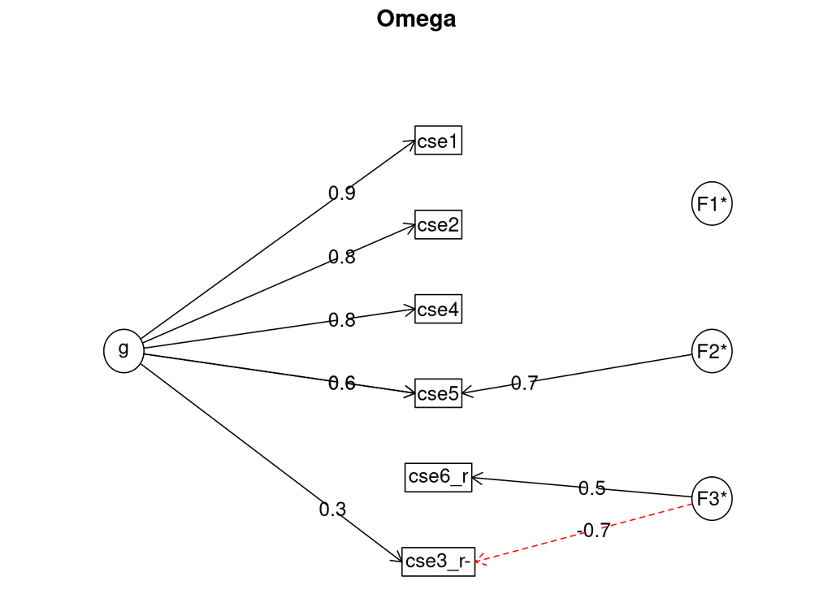

```
## Omega
## Call: omegah(m = m, nfactors = nfactors, fm = fm, key = key, flip = flip,
##     digits = digits, title = title, sl = sl, labels = labels,
##     plot = plot, n.obs = n.obs, rotate = rotate, Phi = Phi, option = option,
##     covar = covar)
## Alpha:                 0.73
## G.6:                   0.78
## Omega Hierarchical:    0.79
## Omega H asymptotic:    0.92
## Omega Total            0.86
##
## Schmid Leiman Factor loadings greater than  0.2
##             g   F1*   F2*   F3*   h2   u2   p2
## cse1     0.93                   0.86 0.14 1.01
## cse2     0.82                   0.69 0.31 0.97
## cse3_r-  0.33             -0.71 0.62 0.38 0.17
## cse4     0.77                   0.62 0.38 0.95
## cse5     0.61        0.68       0.84 0.16 0.45
## cse6_r                     0.48 0.23 0.77 0.00
##
## With Sums of squares  of:
##    g  F1*  F2*  F3*
## 2.61 0.00 0.51 0.74
##
## general/max  3.51   max/min =   Inf
## mean percent general =  0.59    with sd =  0.45 and cv of  0.75
## Explained Common Variance of the general factor =  0.67
##
## The degrees of freedom are 0  and the fit is  0
## The number of observations was  652  with Chi Square =  0.04  with prob <  NA
## The root mean square of the residuals is  0
## The df corrected root mean square of the residuals is  NA
##
## Compare this with the adequacy of just a general factor and no group factors
## The degrees of freedom for just the general factor are 9  and the fit is  0.27
## The number of observations was  652  with Chi Square =  173.08  with prob <  0.000000000000000000000000000000014
## The root mean square of the residuals is  0.1
## The df corrected root mean square of the residuals is  0.13
##
## RMSEA index =  0.167  and the 10 % confidence intervals are  0.146 0.19
## BIC =  114.76
##
## Measures of factor score adequacy
##                                                  g F1*  F2*  F3*
## Correlation of scores with factors            0.96   0 0.85 0.79
## Multiple R square of scores with factors      0.92   0 0.72 0.62
## Minimum correlation of factor score estimates 0.84  -1 0.44 0.25
##
##  Total, General and Subset omega for each subset
##                                                  g F1*  F2*  F3*
## Omega total for total scores and subscales    0.86  NA 0.91 0.12
## Omega general for total scores and subscales  0.79  NA 0.84 0.08
## Omega group for total scores and subscales    0.06  NA 0.07 0.04
```

```r
psych::omega(cse)
```

```r
#Dark Personality Traits
mach <- crCrime %>% select(starts_with("mach"), -mach_total)
psych::alpha(mach)
```

```
##
## Reliability analysis
## Call: psych::alpha(x = mach)
##
##   raw_alpha std.alpha G6(smc) average_r S/N   ase mean   sd median_r
##       0.75      0.75    0.73       0.3   3 0.015  3.5 0.64     0.32
##
##     95% confidence boundaries
##          lower alpha upper
## Feldt     0.72  0.75  0.78
## Duhachek  0.72  0.75  0.78
##
##  Reliability if an item is dropped:
##       raw_alpha std.alpha G6(smc) average_r S/N alpha se  var.r med.r
## mach1      0.71      0.71    0.68      0.29 2.5    0.017 0.0030  0.30
## mach2      0.71      0.71    0.68      0.29 2.5    0.018 0.0031  0.30
## mach3      0.71      0.71    0.68      0.29 2.5    0.017 0.0029  0.30
## mach4      0.73      0.73    0.70      0.31 2.7    0.016 0.0020  0.33
## mach5      0.71      0.71    0.68      0.29 2.5    0.018 0.0032  0.30
## mach6      0.74      0.74    0.71      0.32 2.8    0.016 0.0016  0.33
## mach7      0.72      0.72    0.69      0.30 2.6    0.017 0.0027  0.32
##
##  Item statistics
##         n raw.r std.r r.cor r.drop mean   sd
## mach1 649  0.65  0.65  0.57   0.49  3.7 0.96
## mach2 647  0.67  0.67  0.59   0.51  3.4 1.03
## mach3 648  0.67  0.66  0.57   0.50  3.4 1.08
## mach4 649  0.60  0.60  0.49   0.42  3.2 1.06
## mach5 649  0.66  0.66  0.59   0.51  3.6 0.98
## mach6 649  0.56  0.56  0.44   0.38  3.3 1.01
## mach7 650  0.63  0.63  0.53   0.46  3.7 1.00
##
## Non missing response frequency for each item
##          1    2    3    4    5 miss
## mach1 0.02 0.08 0.25 0.44 0.20 0.00
## mach2 0.04 0.16 0.32 0.35 0.13 0.01
## mach3 0.06 0.15 0.25 0.40 0.14 0.01
## mach4 0.05 0.19 0.35 0.28 0.12 0.00
## mach5 0.04 0.09 0.25 0.47 0.14 0.00
## mach6 0.06 0.15 0.31 0.40 0.08 0.00
## mach7 0.04 0.07 0.23 0.44 0.21 0.00
```

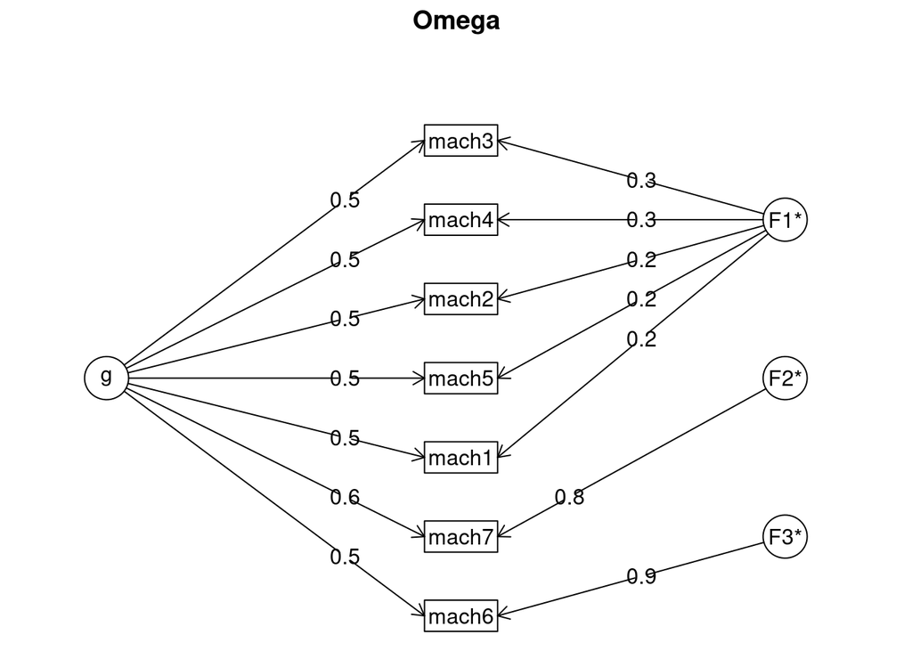

```
## Omega
## Call: omegah(m = m, nfactors = nfactors, fm = fm, key = key, flip = flip,
##     digits = digits, title = title, sl = sl, labels = labels,
##     plot = plot, n.obs = n.obs, rotate = rotate, Phi = Phi, option = option,
##     covar = covar)
## Alpha:                 0.75
## G.6:                   0.73
## Omega Hierarchical:    0.66
## Omega H asymptotic:    0.79
## Omega Total            0.83
##
## Schmid Leiman Factor loadings greater than  0.2
##          g   F1*   F2*   F3*   h2   u2   p2
## mach1 0.51  0.23             0.33 0.67 0.81
## mach2 0.53  0.25             0.35 0.65 0.81
## mach3 0.54  0.29             0.38 0.62 0.77
## mach4 0.47  0.27             0.30 0.70 0.73
## mach5 0.52  0.24             0.33 0.67 0.82
## mach6 0.47              0.88 1.00 0.00 0.22
## mach7 0.56        0.83       1.00 0.00 0.32
##
## With Sums of squares  of:
##    g  F1*  F2*  F3*
## 1.86 0.33 0.70 0.78
##
## general/max  2.37   max/min =   2.38
## mean percent general =  0.64    with sd =  0.26 and cv of  0.4
## Explained Common Variance of the general factor =  0.51
##
## The degrees of freedom are 3  and the fit is  0.01
## The number of observations was  652  with Chi Square =  4.24  with prob <  0.24
## The root mean square of the residuals is  0.01
## The df corrected root mean square of the residuals is  0.03
## RMSEA index =  0.025  and the 10 % confidence intervals are  0 0.075
## BIC =  -15.2
##
## Compare this with the adequacy of just a general factor and no group factors
## The degrees of freedom for just the general factor are 14  and the fit is  0.06
## The number of observations was  652  with Chi Square =  41.86  with prob <  0.00013
## The root mean square of the residuals is  0.05
## The df corrected root mean square of the residuals is  0.07
##
## RMSEA index =  0.055  and the 10 % confidence intervals are  0.036 0.075
## BIC =  -48.86
##
## Measures of factor score adequacy
##                                                  g   F1*  F2*  F3*
## Correlation of scores with factors            0.82  0.44 0.92 0.95
## Multiple R square of scores with factors      0.67  0.19 0.84 0.90
## Minimum correlation of factor score estimates 0.33 -0.61 0.68 0.80
##
##  Total, General and Subset omega for each subset
##                                                  g  F1*  F2*  F3*
## Omega total for total scores and subscales    0.83 0.71 1.00 1.00
## Omega general for total scores and subscales  0.66 0.57 0.31 0.22
## Omega group for total scores and subscales    0.16 0.14 0.68 0.78
```

```r
psych::omega(mach)
```

```r
narc <- crCrime %>% select(starts_with("nar"), -narc_total)
psych::alpha(narc, check.keys=TRUE)
```

```
##
## Reliability analysis
## Call: psych::alpha(x = narc, check.keys = TRUE)
##
##   raw_alpha std.alpha G6(smc) average_r S/N   ase mean   sd median_r
##        0.8       0.8    0.78      0.36   4 0.012  3.1 0.72     0.36
##
##     95% confidence boundaries
##          lower alpha upper
## Feldt     0.77   0.8  0.82
## Duhachek  0.77   0.8  0.82
##
##  Reliability if an item is dropped:
##       raw_alpha std.alpha G6(smc) average_r S/N alpha se  var.r med.r
## narc1      0.77      0.77    0.75      0.36 3.3    0.014 0.0088  0.35
## narc2      0.76      0.76    0.73      0.35 3.2    0.015 0.0067  0.35
## narc3      0.76      0.77    0.74      0.35 3.3    0.014 0.0076  0.35
## narc4      0.76      0.76    0.74      0.35 3.2    0.014 0.0079  0.35
## narc5      0.78      0.79    0.76      0.38 3.7    0.013 0.0095  0.41
## narc6      0.77      0.77    0.74      0.36 3.3    0.014 0.0078  0.35
## narc7      0.80      0.80    0.78      0.41 4.1    0.012 0.0039  0.41
##
##  Item statistics
##         n raw.r std.r r.cor r.drop mean  sd
## narc1 649  0.69  0.69  0.62   0.56  3.2 1.0
## narc2 649  0.73  0.73  0.68   0.60  3.2 1.1
## narc3 648  0.71  0.71  0.65   0.58  2.9 1.0
## narc4 650  0.72  0.72  0.66   0.59  2.9 1.1
## narc5 648  0.60  0.63  0.52   0.47  3.6 0.9
## narc6 650  0.71  0.70  0.63   0.56  2.9 1.2
## narc7 649  0.55  0.54  0.40   0.36  3.0 1.1
##
## Non missing response frequency for each item
##          1    2    3    4    5 miss
## narc1 0.06 0.17 0.35 0.32 0.11 0.00
## narc2 0.07 0.20 0.32 0.32 0.09 0.00
## narc3 0.08 0.27 0.37 0.22 0.06 0.01
## narc4 0.11 0.25 0.34 0.24 0.07 0.00
## narc5 0.03 0.06 0.27 0.49 0.14 0.01
## narc6 0.16 0.22 0.31 0.22 0.09 0.00
## narc7 0.12 0.22 0.26 0.34 0.06 0.00
```

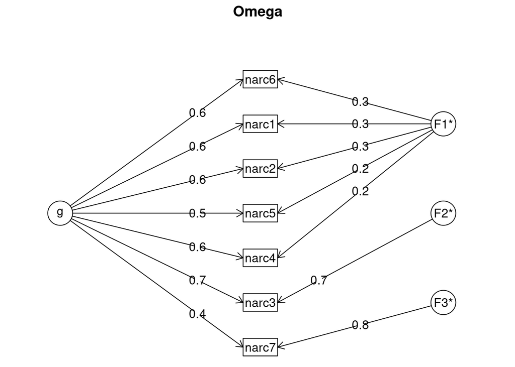

```
## Omega
## Call: omegah(m = m, nfactors = nfactors, fm = fm, key = key, flip = flip,
##     digits = digits, title = title, sl = sl, labels = labels,
##     plot = plot, n.obs = n.obs, rotate = rotate, Phi = Phi, option = option,
##     covar = covar)
## Alpha:                 0.8
## G.6:                   0.78
## Omega Hierarchical:    0.72
## Omega H asymptotic:    0.83
## Omega Total            0.86
##
## Schmid Leiman Factor loadings greater than  0.2
##          g   F1*   F2*   F3*   h2   u2   p2
## narc1 0.58  0.28             0.42 0.58 0.81
## narc2 0.63  0.28             0.48 0.52 0.83
## narc3 0.70        0.72       1.00 0.00 0.49
## narc4 0.60  0.24             0.43 0.57 0.85
## narc5 0.48  0.24             0.30 0.70 0.76
## narc6 0.60  0.29             0.44 0.56 0.81
## narc7 0.41              0.84 0.88 0.12 0.19
##
## With Sums of squares  of:
##    g  F1*  F2*  F3*
## 2.35 0.36 0.53 0.72
##
## general/max  3.26   max/min =   2.01
## mean percent general =  0.68    with sd =  0.25 and cv of  0.37
## Explained Common Variance of the general factor =  0.59
##
## The degrees of freedom are 3  and the fit is  0.01
## The number of observations was  652  with Chi Square =  9.57  with prob <  0.023
## The root mean square of the residuals is  0.01
## The df corrected root mean square of the residuals is  0.04
## RMSEA index =  0.058  and the 10 % confidence intervals are  0.019 0.101
## BIC =  -9.87
##
## Compare this with the adequacy of just a general factor and no group factors
## The degrees of freedom for just the general factor are 14  and the fit is  0.1
## The number of observations was  652  with Chi Square =  63.4  with prob <  0.000000029
## The root mean square of the residuals is  0.06
## The df corrected root mean square of the residuals is  0.07
##
## RMSEA index =  0.074  and the 10 % confidence intervals are  0.056 0.092
## BIC =  -27.32
##
## Measures of factor score adequacy
##                                                  g   F1*  F2*  F3*
## Correlation of scores with factors            0.86  0.46 0.87 0.90
## Multiple R square of scores with factors      0.74  0.21 0.75 0.81
## Minimum correlation of factor score estimates 0.48 -0.58 0.51 0.62
##
##  Total, General and Subset omega for each subset
##                                                  g  F1*  F2*  F3*
## Omega total for total scores and subscales    0.86 0.78 1.00 0.88
## Omega general for total scores and subscales  0.72 0.64 0.48 0.17
## Omega group for total scores and subscales    0.13 0.14 0.51 0.71
```

```r
psych::omega(narc)
```

```r
sadism <- crCrime %>% select(starts_with("sad"), -sadism_total)
psych::alpha(sadism, check.keys=TRUE)
```

```
##
## Reliability analysis
## Call: psych::alpha(x = sadism, check.keys = TRUE)
##
##   raw_alpha std.alpha G6(smc) average_r S/N   ase mean   sd median_r
##        0.8       0.8     0.8      0.37   4 0.012  2.7 0.82     0.32
##
##     95% confidence boundaries
##          lower alpha upper
## Feldt     0.78   0.8  0.83
## Duhachek  0.78   0.8  0.83
##
##  Reliability if an item is dropped:
##         raw_alpha std.alpha G6(smc) average_r S/N alpha se  var.r med.r
## sadism1      0.75      0.75    0.74      0.34 3.0    0.015 0.0080  0.32
## sadism2      0.76      0.76    0.75      0.34 3.1    0.015 0.0096  0.32
## sadism3      0.78      0.78    0.77      0.37 3.5    0.013 0.0184  0.31
## sadism4      0.76      0.76    0.74      0.35 3.2    0.014 0.0066  0.32
## sadism5      0.79      0.79    0.78      0.39 3.8    0.012 0.0162  0.35
## sadism6      0.79      0.79    0.78      0.38 3.7    0.013 0.0166  0.35
## sadism7      0.80      0.79    0.78      0.39 3.8    0.012 0.0159  0.35
##
##  Item statistics
##           n raw.r std.r r.cor r.drop mean  sd
## sadism1 649  0.77  0.77  0.75   0.66  2.4 1.2
## sadism2 649  0.75  0.75  0.71   0.63  2.5 1.3
## sadism3 649  0.66  0.66  0.57   0.51  3.0 1.2
## sadism4 649  0.74  0.73  0.70   0.61  2.5 1.3
## sadism5 648  0.60  0.61  0.50   0.44  3.0 1.2
## sadism6 650  0.61  0.62  0.51   0.46  2.0 1.2
## sadism7 649  0.59  0.60  0.48   0.43  3.2 1.2
##
## Non missing response frequency for each item
##            1    2    3    4    5 miss
## sadism1 0.31 0.24 0.21 0.18 0.06 0.00
## sadism2 0.29 0.24 0.22 0.16 0.07 0.00
## sadism3 0.14 0.18 0.29 0.31 0.08 0.00
## sadism4 0.30 0.22 0.24 0.18 0.07 0.00
## sadism5 0.15 0.16 0.30 0.29 0.10 0.01
## sadism6 0.48 0.23 0.15 0.10 0.03 0.00
## sadism7 0.12 0.16 0.26 0.35 0.11 0.00
```

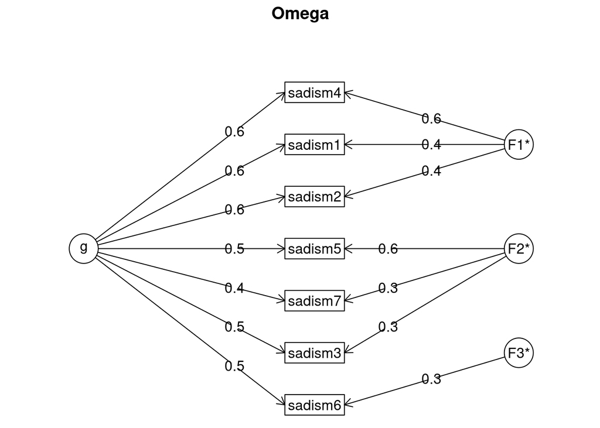

```
## Omega
## Call: omegah(m = m, nfactors = nfactors, fm = fm, key = key, flip = flip,
##     digits = digits, title = title, sl = sl, labels = labels,
##     plot = plot, n.obs = n.obs, rotate = rotate, Phi = Phi, option = option,
##     covar = covar)
## Alpha:                 0.8
## G.6:                   0.8
## Omega Hierarchical:    0.62
## Omega H asymptotic:    0.73
## Omega Total            0.84
##
## Schmid Leiman Factor loadings greater than  0.2
##            g   F1*   F2*   F3*   h2   u2   p2
## sadism1 0.65  0.42             0.63 0.37 0.67
## sadism2 0.60  0.42             0.55 0.45 0.66
## sadism3 0.50        0.28       0.36 0.64 0.69
## sadism4 0.60  0.64             0.77 0.23 0.47
## sadism5 0.46        0.57       0.54 0.46 0.39
## sadism6 0.49              0.35 0.37 0.63 0.65
## sadism7 0.42        0.34       0.30 0.70 0.59
##
## With Sums of squares  of:
##    g  F1*  F2*  F3*
## 2.01 0.77 0.53 0.20
##
## general/max  2.61   max/min =   3.77
## mean percent general =  0.59    with sd =  0.11 and cv of  0.2
## Explained Common Variance of the general factor =  0.57
##
## The degrees of freedom are 3  and the fit is  0
## The number of observations was  652  with Chi Square =  2.53  with prob <  0.47
## The root mean square of the residuals is  0.01
## The df corrected root mean square of the residuals is  0.02
## RMSEA index =  0  and the 10 % confidence intervals are  0 0.062
## BIC =  -16.91
##
## Compare this with the adequacy of just a general factor and no group factors
## The degrees of freedom for just the general factor are 14  and the fit is  0.37
## The number of observations was  652  with Chi Square =  238.31  with prob <  0.00000000000000000000000000000000000000000075
## The root mean square of the residuals is  0.12
## The df corrected root mean square of the residuals is  0.14
##
## RMSEA index =  0.157  and the 10 % confidence intervals are  0.14 0.175
## BIC =  147.58
##
## Measures of factor score adequacy
##                                                  g   F1*   F2*   F3*
## Correlation of scores with factors            0.79  0.69  0.63  0.47
## Multiple R square of scores with factors      0.62  0.48  0.40  0.22
## Minimum correlation of factor score estimates 0.25 -0.05 -0.19 -0.56
##
##  Total, General and Subset omega for each subset
##                                                  g  F1*  F2*  F3*
## Omega total for total scores and subscales    0.84 0.84 0.64 0.36
## Omega general for total scores and subscales  0.62 0.51 0.36 0.24
## Omega group for total scores and subscales    0.17 0.32 0.27 0.12
```

```r
psych::omega(sadism)
```

```r
psy <- crCrime %>% select(starts_with("psy"), -psych_total)
psych::alpha(psy, check.keys=TRUE)
```

```
##
## Reliability analysis
## Call: psych::alpha(x = psy, check.keys = TRUE)
##
##   raw_alpha std.alpha G6(smc) average_r S/N    ase mean   sd median_r
##       0.86      0.86    0.85      0.48 6.4 0.0081  2.3 0.85     0.47
##
##     95% confidence boundaries
##          lower alpha upper
## Feldt     0.85  0.86  0.88
## Duhachek  0.85  0.86  0.88
##
##  Reliability if an item is dropped:
##      raw_alpha std.alpha G6(smc) average_r S/N alpha se  var.r med.r
## psy1      0.84      0.84    0.82      0.46 5.1   0.0099 0.0080  0.44
## psy2      0.85      0.85    0.83      0.48 5.6   0.0092 0.0102  0.49
## psy3      0.83      0.83    0.81      0.45 5.0   0.0101 0.0062  0.44
## psy4      0.86      0.87    0.85      0.52 6.4   0.0082 0.0054  0.51
## psy5      0.83      0.83    0.81      0.46 5.0   0.0101 0.0062  0.46
## psy6      0.84      0.84    0.83      0.48 5.4   0.0094 0.0104  0.47
## psy7      0.85      0.85    0.84      0.49 5.8   0.0089 0.0104  0.51
##
##  Item statistics
##        n raw.r std.r r.cor r.drop mean  sd
## psy1 650  0.79  0.79  0.76   0.70  2.0 1.1
## psy2 649  0.73  0.73  0.66   0.61  2.3 1.2
## psy3 649  0.81  0.81  0.79   0.72  1.8 1.1
## psy4 649  0.62  0.62  0.51   0.48  2.9 1.1
## psy5 649  0.80  0.80  0.77   0.71  1.8 1.1
## psy6 649  0.75  0.74  0.68   0.63  2.5 1.2
## psy7 649  0.70  0.70  0.62   0.58  2.6 1.1
##
## Non missing response frequency for each item
##         1    2    3    4    5 miss
## psy1 0.42 0.31 0.14 0.09 0.04    0
## psy2 0.30 0.30 0.20 0.14 0.06    0
## psy3 0.54 0.24 0.10 0.08 0.03    0
## psy4 0.12 0.25 0.30 0.27 0.06    0
## psy5 0.58 0.17 0.14 0.07 0.04    0
## psy6 0.28 0.26 0.23 0.18 0.05    0
## psy7 0.20 0.27 0.32 0.16 0.05    0
```

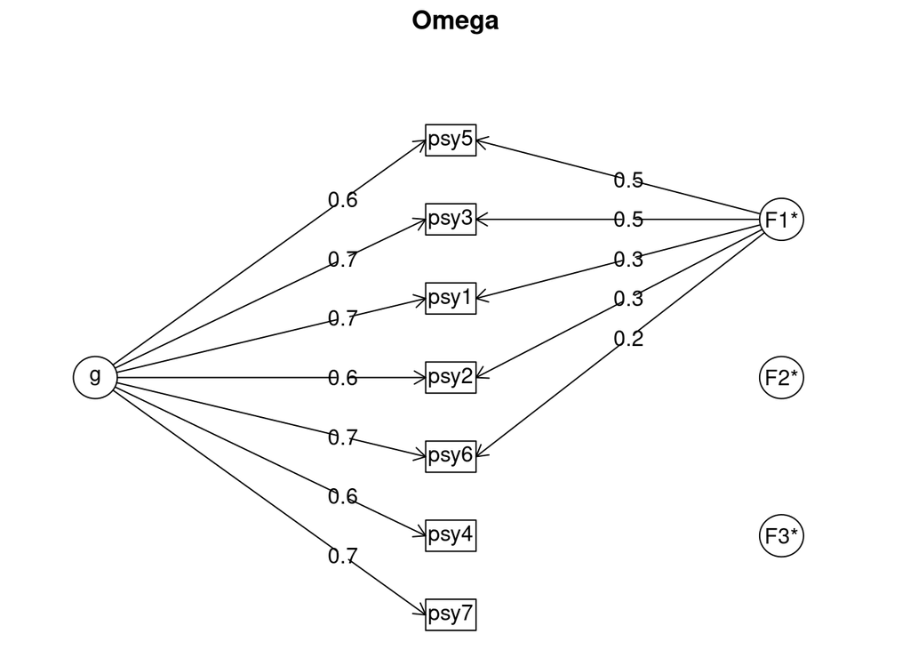

```
## Omega
## Call: omegah(m = m, nfactors = nfactors, fm = fm, key = key, flip = flip,
##     digits = digits, title = title, sl = sl, labels = labels,
##     plot = plot, n.obs = n.obs, rotate = rotate, Phi = Phi, option = option,
##     covar = covar)
## Alpha:                 0.86
## G.6:                   0.85
## Omega Hierarchical:    0.75
## Omega H asymptotic:    0.85
## Omega Total            0.88
##
## Schmid Leiman Factor loadings greater than  0.2
##         g   F1*  F2*  F3*   h2   u2   p2
## psy1 0.69  0.33           0.60 0.40 0.80
## psy2 0.61  0.25           0.44 0.56 0.84
## psy3 0.66  0.50           0.69 0.31 0.63
## psy4 0.58                 0.34 0.66 0.99
## psy5 0.64  0.52           0.71 0.29 0.58
## psy6 0.66  0.21           0.51 0.49 0.85
## psy7 0.66                 0.47 0.53 0.92
##
## With Sums of squares  of:
##    g  F1*  F2*  F3*
## 2.89 0.75 0.00 0.11
##
## general/max  3.88   max/min =   253.78
## mean percent general =  0.8    with sd =  0.15 and cv of  0.18
## Explained Common Variance of the general factor =  0.77
##
## The degrees of freedom are 3  and the fit is  0.01
## The number of observations was  652  with Chi Square =  5.06  with prob <  0.17
## The root mean square of the residuals is  0.01
## The df corrected root mean square of the residuals is  0.02
## RMSEA index =  0.032  and the 10 % confidence intervals are  0 0.08
## BIC =  -14.38
##
## Compare this with the adequacy of just a general factor and no group factors
## The degrees of freedom for just the general factor are 14  and the fit is  0.26
## The number of observations was  652  with Chi Square =  165.72  with prob <  0.0000000000000000000000000005
## The root mean square of the residuals is  0.1
## The df corrected root mean square of the residuals is  0.12
##
## RMSEA index =  0.129  and the 10 % confidence intervals are  0.112 0.147
## BIC =  75
##
## Measures of factor score adequacy
##                                                  g   F1*   F2*   F3*
## Correlation of scores with factors            0.87  0.65  0.05  0.45
## Multiple R square of scores with factors      0.76  0.43  0.00  0.21
## Minimum correlation of factor score estimates 0.53 -0.15 -0.99 -0.59
##
##  Total, General and Subset omega for each subset
##                                                  g  F1* F2*  F3*
## Omega total for total scores and subscales    0.88 0.87  NA 0.56
## Omega general for total scores and subscales  0.75 0.66  NA 0.56
## Omega group for total scores and subscales    0.12 0.21  NA 0.00
```

```r
psych::omega(psy)
```

```r
#Moral Foundations Questionnaire (MFQ)
mfq <- crCrime %>% select(starts_with("MFQ"))
harm_mfq <- mfq %>% select(ends_with("H"))
psych::alpha(harm_mfq)
```

```
##
## Reliability analysis
## Call: psych::alpha(x = harm_mfq)
##
##   raw_alpha std.alpha G6(smc) average_r S/N   ase mean   sd median_r
##       0.69      0.71    0.69      0.29 2.4 0.019  3.6 0.79     0.27
##
##     95% confidence boundaries
##          lower alpha upper
## Feldt     0.65  0.69  0.73
## Duhachek  0.65  0.69  0.73
##
##  Reliability if an item is dropped:
##          raw_alpha std.alpha G6(smc) average_r S/N alpha se  var.r med.r
## MFQ_1_H       0.62      0.64    0.62      0.26 1.8    0.024 0.0166  0.26
## MFQ_7_H       0.63      0.65    0.63      0.27 1.9    0.023 0.0153  0.27
## MFQ_12_H      0.66      0.68    0.65      0.30 2.1    0.021 0.0097  0.27
## MFQ_17_H      0.61      0.62    0.59      0.25 1.6    0.025 0.0163  0.25
## MFQ_23_H      0.66      0.68    0.65      0.29 2.1    0.022 0.0194  0.37
## MFQ_28_H      0.72      0.72    0.69      0.34 2.6    0.018 0.0069  0.38
##
##  Item statistics
##            n raw.r std.r r.cor r.drop mean  sd
## MFQ_1_H  646  0.69  0.70  0.62   0.52  3.5 1.2
## MFQ_7_H  645  0.67  0.67  0.58   0.47  3.4 1.2
## MFQ_12_H 645  0.59  0.60  0.49   0.38  3.7 1.3
## MFQ_17_H 646  0.72  0.74  0.68   0.58  3.8 1.1
## MFQ_23_H 646  0.62  0.61  0.49   0.40  3.8 1.3
## MFQ_28_H 646  0.53  0.49  0.31   0.25  3.5 1.5
##
## Non missing response frequency for each item
##             0    1    2    3    4    5 miss
## MFQ_1_H  0.02 0.04 0.14 0.25 0.35 0.21 0.01
## MFQ_7_H  0.02 0.06 0.13 0.25 0.34 0.19 0.01
## MFQ_12_H 0.03 0.04 0.09 0.18 0.34 0.31 0.01
## MFQ_17_H 0.01 0.02 0.07 0.24 0.34 0.32 0.01
## MFQ_23_H 0.02 0.04 0.08 0.23 0.20 0.43 0.01
## MFQ_28_H 0.04 0.07 0.14 0.14 0.24 0.36 0.01
```

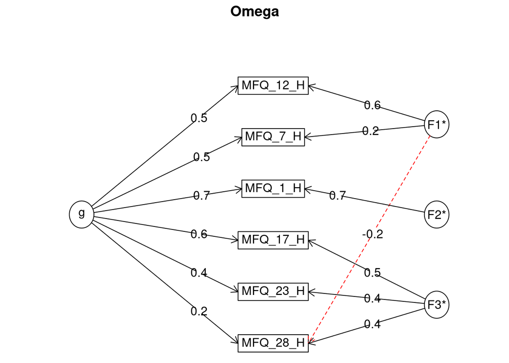

```
## Omega
## Call: omegah(m = m, nfactors = nfactors, fm = fm, key = key, flip = flip,
##     digits = digits, title = title, sl = sl, labels = labels,
##     plot = plot, n.obs = n.obs, rotate = rotate, Phi = Phi, option = option,
##     covar = covar)
## Alpha:                 0.71
## G.6:                   0.69
## Omega Hierarchical:    0.55
## Omega H asymptotic:    0.69
## Omega Total            0.8
##
## Schmid Leiman Factor loadings greater than  0.2
##             g   F1*   F2*   F3*   h2   u2   p2
## MFQ_1_H  0.70        0.72       1.00 0.00 0.49
## MFQ_7_H  0.47  0.21             0.32 0.68 0.69
## MFQ_12_H 0.49  0.57             0.57 0.43 0.43
## MFQ_17_H 0.56              0.47 0.56 0.44 0.55
## MFQ_23_H 0.38              0.42 0.32 0.68 0.44
## MFQ_28_H 0.23 -0.22        0.36 0.24 0.76 0.23
##
## With Sums of squares  of:
##    g  F1*  F2*  F3*
## 1.46 0.45 0.54 0.56
##
## general/max  2.59   max/min =   1.27
## mean percent general =  0.47    with sd =  0.15 and cv of  0.32
## Explained Common Variance of the general factor =  0.48
##
## The degrees of freedom are 0  and the fit is  0
## The number of observations was  652  with Chi Square =  0.55  with prob <  NA
## The root mean square of the residuals is  0
## The df corrected root mean square of the residuals is  NA
##
## Compare this with the adequacy of just a general factor and no group factors
## The degrees of freedom for just the general factor are 9  and the fit is  0.18
## The number of observations was  652  with Chi Square =  116.31  with prob <  0.0000000000000000000076
## The root mean square of the residuals is  0.1
## The df corrected root mean square of the residuals is  0.13
##
## RMSEA index =  0.135  and the 10 % confidence intervals are  0.114 0.158
## BIC =  57.99
##
## Measures of factor score adequacy
##                                                  g   F1*  F2*   F3*
## Correlation of scores with factors            0.79  0.65 0.80  0.64
## Multiple R square of scores with factors      0.63  0.43 0.65  0.41
## Minimum correlation of factor score estimates 0.26 -0.15 0.29 -0.19
##
##  Total, General and Subset omega for each subset
##                                                  g  F1*  F2*  F3*
## Omega total for total scores and subscales    0.80 0.57 1.00 0.61
## Omega general for total scores and subscales  0.55 0.34 0.48 0.28
## Omega group for total scores and subscales    0.18 0.22 0.51 0.33
```

```r
psych::omega(harm_mfq)
```

```r
fair_mfq <- mfq %>% select(ends_with("F"))
psych::alpha(fair_mfq)
```

```
##
## Reliability analysis
## Call: psych::alpha(x = fair_mfq)
##
##   raw_alpha std.alpha G6(smc) average_r S/N   ase mean   sd median_r
##       0.69      0.71    0.71      0.29 2.5 0.019  3.5 0.77     0.28
##
##     95% confidence boundaries
##          lower alpha upper
## Feldt     0.66  0.69  0.73
## Duhachek  0.66  0.69  0.73
##
##  Reliability if an item is dropped:
##          raw_alpha std.alpha G6(smc) average_r S/N alpha se var.r med.r
## MFQ_2_F       0.62      0.65    0.63      0.27 1.8    0.024 0.021  0.24
## MFQ_8_F       0.62      0.65    0.64      0.27 1.9    0.024 0.025  0.23
## MFQ_13_F      0.64      0.66    0.64      0.28 2.0    0.023 0.016  0.27
## MFQ_18_F      0.62      0.64    0.62      0.26 1.8    0.024 0.024  0.23
## MFQ_24_F      0.65      0.68    0.66      0.30 2.1    0.022 0.027  0.36
## MFQ_29_F      0.75      0.75    0.72      0.37 3.0    0.016 0.010  0.38
##
##  Item statistics
##            n raw.r std.r r.cor r.drop mean  sd
## MFQ_2_F  646  0.70  0.70  0.64   0.52  3.4 1.2
## MFQ_8_F  645  0.69  0.70  0.61   0.51  3.4 1.2
## MFQ_13_F 646  0.65  0.67  0.59   0.46  3.7 1.2
## MFQ_18_F 647  0.69  0.71  0.65   0.53  4.1 1.1
## MFQ_24_F 646  0.61  0.63  0.52   0.42  3.9 1.1
## MFQ_29_F 646  0.49  0.43  0.22   0.19  2.6 1.5
##
## Non missing response frequency for each item
##             0    1    2    3    4    5 miss
## MFQ_2_F  0.03 0.04 0.14 0.24 0.38 0.16 0.01
## MFQ_8_F  0.02 0.04 0.13 0.28 0.34 0.19 0.01
## MFQ_13_F 0.02 0.04 0.12 0.20 0.34 0.29 0.01
## MFQ_18_F 0.01 0.02 0.06 0.17 0.25 0.49 0.01
## MFQ_24_F 0.01 0.02 0.09 0.20 0.33 0.35 0.01
## MFQ_29_F 0.11 0.16 0.21 0.23 0.18 0.12 0.01
```

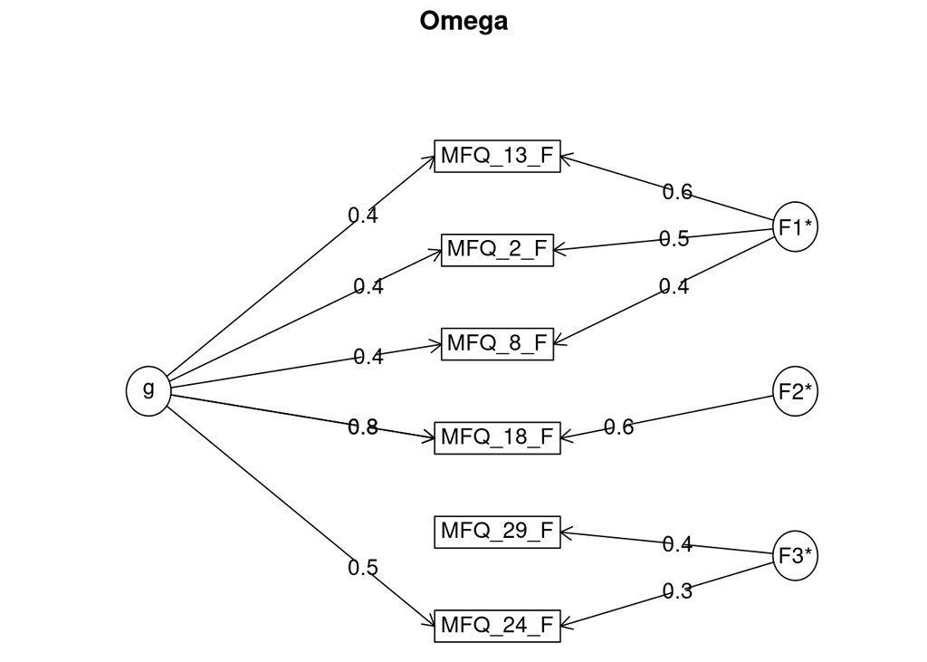

```
## Omega
## Call: omegah(m = m, nfactors = nfactors, fm = fm, key = key, flip = flip,
##     digits = digits, title = title, sl = sl, labels = labels,
##     plot = plot, n.obs = n.obs, rotate = rotate, Phi = Phi, option = option,
##     covar = covar)
## Alpha:                 0.71
## G.6:                   0.71
## Omega Hierarchical:    0.52
## Omega H asymptotic:    0.66
## Omega Total            0.8
##
## Schmid Leiman Factor loadings greater than  0.2
##              g   F1*   F2*   F3*   h2   u2   p2
## MFQ_2_F   0.44  0.54             0.51 0.49 0.38
## MFQ_8_F   0.44  0.38             0.38 0.62 0.52
## MFQ_13_F  0.44  0.65             0.62 0.38 0.31
## MFQ_18_F  0.83        0.56       1.00 0.00 0.69
## MFQ_24_F  0.46              0.30 0.33 0.67 0.62
## MFQ_29_F                    0.39 0.19 0.81 0.17
##
## With Sums of squares  of:
##    g  F1*  F2*  F3*
## 1.51 0.86 0.35 0.30
##
## general/max  1.75   max/min =   2.87
## mean percent general =  0.45    with sd =  0.2 and cv of  0.44
## Explained Common Variance of the general factor =  0.5
##
## The degrees of freedom are 0  and the fit is  0
## The number of observations was  652  with Chi Square =  0  with prob <  NA
## The root mean square of the residuals is  0
## The df corrected root mean square of the residuals is  NA
##
## Compare this with the adequacy of just a general factor and no group factors
## The degrees of freedom for just the general factor are 9  and the fit is  0.32
## The number of observations was  652  with Chi Square =  207.08  with prob <  0.0000000000000000000000000000000000000011
## The root mean square of the residuals is  0.13
## The df corrected root mean square of the residuals is  0.17
##
## RMSEA index =  0.184  and the 10 % confidence intervals are  0.163 0.206
## BIC =  148.76
##
## Measures of factor score adequacy
##                                                  g  F1*   F2*   F3*
## Correlation of scores with factors            0.85 0.77  0.62  0.54
## Multiple R square of scores with factors      0.72 0.59  0.39  0.30
## Minimum correlation of factor score estimates 0.45 0.18 -0.22 -0.41
##
##  Total, General and Subset omega for each subset
##                                                  g  F1*  F2*  F3*
## Omega total for total scores and subscales    0.80 0.73 0.99 0.37
## Omega general for total scores and subscales  0.52 0.30 0.69 0.17
## Omega group for total scores and subscales    0.22 0.43 0.31 0.20
```

```r
psych::omega(fair_mfq)
```

```r
loyal_mfq <- mfq %>% select(ends_with("L"))
psych::alpha(loyal_mfq)
```

```
##
## Reliability analysis
## Call: psych::alpha(x = loyal_mfq)
##
##   raw_alpha std.alpha G6(smc) average_r S/N   ase mean   sd median_r
##       0.69      0.69    0.69      0.27 2.2 0.019  2.9 0.89     0.31
##
##     95% confidence boundaries
##          lower alpha upper
## Feldt     0.65  0.69  0.72
## Duhachek  0.65  0.69  0.72
##
##  Reliability if an item is dropped:
##          raw_alpha std.alpha G6(smc) average_r S/N alpha se  var.r med.r
## MFQ_3_L       0.61      0.62    0.62      0.24 1.6    0.024 0.0266  0.22
## MFQ_9_L       0.68      0.68    0.64      0.30 2.2    0.019 0.0051  0.32
## MFQ_14_L      0.63      0.62    0.60      0.25 1.6    0.022 0.0177  0.31
## MFQ_19_L      0.66      0.67    0.66      0.29 2.0    0.021 0.0178  0.27
## MFQ_25_L      0.65      0.65    0.65      0.27 1.9    0.022 0.0266  0.27
## MFQ_30_L      0.64      0.65    0.65      0.27 1.8    0.022 0.0265  0.27
##
##  Item statistics
##            n raw.r std.r r.cor r.drop mean  sd
## MFQ_3_L  645  0.71  0.70  0.61   0.52  2.5 1.5
## MFQ_9_L  645  0.49  0.54  0.44   0.29  3.2 1.2
## MFQ_14_L 646  0.65  0.68  0.63   0.48  3.1 1.3
## MFQ_19_L 646  0.62  0.58  0.46   0.38  3.1 1.6
## MFQ_25_L 646  0.64  0.62  0.49   0.42  2.7 1.5
## MFQ_30_L 646  0.63  0.63  0.50   0.43  2.9 1.3
##
## Non missing response frequency for each item
##             0    1    2    3    4    5 miss
## MFQ_3_L  0.11 0.19 0.22 0.20 0.17 0.11 0.01
## MFQ_9_L  0.03 0.07 0.17 0.31 0.29 0.13 0.01
## MFQ_14_L 0.03 0.09 0.20 0.28 0.24 0.15 0.01
## MFQ_19_L 0.09 0.10 0.13 0.25 0.17 0.26 0.01
## MFQ_25_L 0.10 0.14 0.20 0.23 0.20 0.13 0.01
## MFQ_30_L 0.04 0.11 0.23 0.26 0.24 0.12 0.01
```

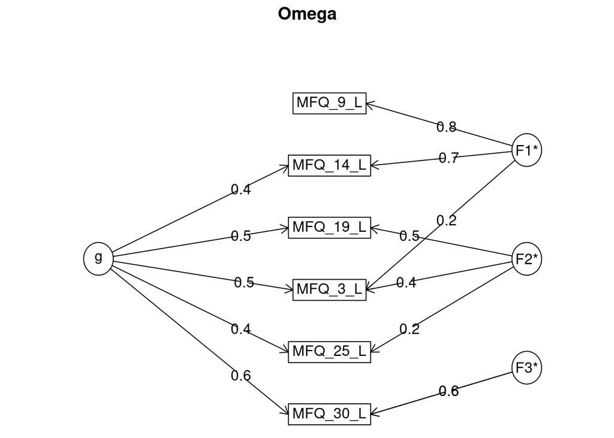

```
## Omega
## Call: omegah(m = m, nfactors = nfactors, fm = fm, key = key, flip = flip,
##     digits = digits, title = title, sl = sl, labels = labels,
##     plot = plot, n.obs = n.obs, rotate = rotate, Phi = Phi, option = option,
##     covar = covar)
## Alpha:                 0.69
## G.6:                   0.69
## Omega Hierarchical:    0.46
## Omega H asymptotic:    0.57
## Omega Total            0.8
##
## Schmid Leiman Factor loadings greater than  0.2
##              g   F1*   F2*   F3*   h2   u2   p2
## MFQ_3_L   0.47  0.22  0.38       0.41 0.59 0.53
## MFQ_9_L         0.78             0.65 0.35 0.06
## MFQ_14_L  0.35  0.67             0.59 0.41 0.21
## MFQ_19_L  0.48        0.49       0.47 0.53 0.48
## MFQ_25_L  0.42        0.23       0.27 0.73 0.67
## MFQ_30_L  0.63              0.60 0.76 0.24 0.52
##
## With Sums of squares  of:
##    g  F1*  F2*  F3*
## 1.18 1.11 0.47 0.40
##
## general/max  1.06   max/min =   2.8
## mean percent general =  0.41    with sd =  0.23 and cv of  0.56
## Explained Common Variance of the general factor =  0.37
##
## The degrees of freedom are 0  and the fit is  0
## The number of observations was  652  with Chi Square =  0  with prob <  NA
## The root mean square of the residuals is  0
## The df corrected root mean square of the residuals is  NA
##
## Compare this with the adequacy of just a general factor and no group factors
## The degrees of freedom for just the general factor are 9  and the fit is  0.48
## The number of observations was  652  with Chi Square =  312.47  with prob <  0.000000000000000000000000000000000000000000000000000000000000059
## The root mean square of the residuals is  0.16
## The df corrected root mean square of the residuals is  0.21
##
## RMSEA index =  0.227  and the 10 % confidence intervals are  0.206 0.25
## BIC =  254.15
##
## Measures of factor score adequacy
##                                                  g  F1*   F2*   F3*
## Correlation of scores with factors            0.74 0.84  0.60  0.64
## Multiple R square of scores with factors      0.55 0.71  0.36  0.41
## Minimum correlation of factor score estimates 0.09 0.43 -0.28 -0.18
##
##  Total, General and Subset omega for each subset
##                                                  g  F1*  F2*  F3*
## Omega total for total scores and subscales    0.80 0.76 0.61 0.76
## Omega general for total scores and subscales  0.46 0.09 0.37 0.40
## Omega group for total scores and subscales    0.26 0.66 0.24 0.36
```

```r
psych::omega(loyal_mfq)
```

```r
auth_mfq <- mfq %>% select(ends_with("A"))
psych::alpha(auth_mfq)
```

```
##
## Reliability analysis
## Call: psych::alpha(x = auth_mfq)
##
##   raw_alpha std.alpha G6(smc) average_r S/N  ase mean   sd median_r
##       0.66      0.66    0.65      0.25   2 0.02  3.1 0.79     0.25
##
##     95% confidence boundaries
##          lower alpha upper
## Feldt     0.62  0.66   0.7
## Duhachek  0.62  0.66   0.7
##
##  Reliability if an item is dropped:
##          raw_alpha std.alpha G6(smc) average_r S/N alpha se  var.r med.r
## MFQ_4_A       0.58      0.58    0.55      0.22 1.4    0.025 0.0121  0.21
## MFQ_10_A      0.61      0.61    0.59      0.24 1.6    0.024 0.0177  0.26
## MFQ_15_A      0.67      0.68    0.65      0.29 2.1    0.021 0.0093  0.26
## MFQ_20_A      0.57      0.57    0.54      0.21 1.3    0.027 0.0103  0.21
## MFQ_26_A      0.65      0.64    0.61      0.27 1.8    0.022 0.0129  0.26
## MFQ_31_A      0.62      0.63    0.61      0.25 1.7    0.023 0.0158  0.25
##
##  Item statistics
##            n raw.r std.r r.cor r.drop mean  sd
## MFQ_4_A  647  0.68  0.69  0.62   0.49  2.9 1.3
## MFQ_10_A 646  0.62  0.62  0.50   0.41  2.4 1.3
## MFQ_15_A 646  0.44  0.48  0.29   0.22  3.6 1.1
## MFQ_20_A 646  0.71  0.71  0.66   0.54  3.6 1.2
## MFQ_26_A 647  0.60  0.56  0.41   0.33  3.0 1.5
## MFQ_31_A 646  0.60  0.60  0.46   0.38  3.3 1.3
##
## Non missing response frequency for each item
##             0    1    2    3    4    5 miss
## MFQ_4_A  0.05 0.09 0.21 0.30 0.25 0.10 0.01
## MFQ_10_A 0.08 0.20 0.24 0.27 0.16 0.05 0.01
## MFQ_15_A 0.01 0.03 0.13 0.24 0.35 0.24 0.01
## MFQ_20_A 0.02 0.04 0.09 0.26 0.32 0.26 0.01
## MFQ_26_A 0.09 0.09 0.14 0.29 0.19 0.19 0.01
## MFQ_31_A 0.04 0.06 0.14 0.29 0.28 0.18 0.01
```

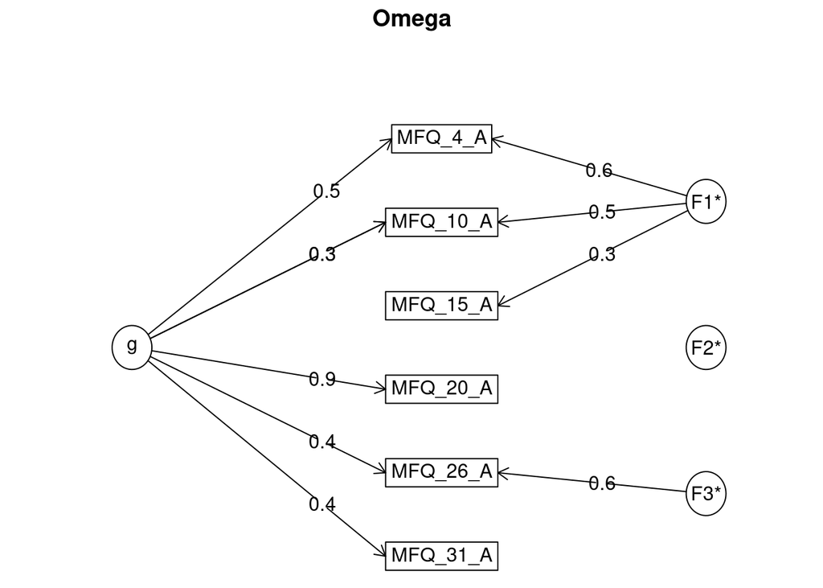

```
## Omega
## Call: omegah(m = m, nfactors = nfactors, fm = fm, key = key, flip = flip,
##     digits = digits, title = title, sl = sl, labels = labels,
##     plot = plot, n.obs = n.obs, rotate = rotate, Phi = Phi, option = option,
##     covar = covar)
## Alpha:                 0.66
## G.6:                   0.65
## Omega Hierarchical:    0.53
## Omega H asymptotic:    0.72
## Omega Total            0.74
##
## Schmid Leiman Factor loadings greater than  0.2
##              g   F1*   F2*   F3*   h2   u2   p2
## MFQ_4_A   0.51  0.55             0.57 0.43 0.46
## MFQ_10_A  0.29  0.47             0.34 0.66 0.25
## MFQ_15_A        0.33             0.15 0.85 0.21
## MFQ_20_A  0.85                   0.74 0.26 0.99
## MFQ_26_A  0.40              0.61 0.53 0.47 0.30
## MFQ_31_A  0.44                   0.22 0.78 0.87
##
## With Sums of squares  of:
##    g  F1*  F2*  F3*
## 1.46 0.65 0.01 0.43
##
## general/max  2.25   max/min =   125.18
## mean percent general =  0.51    with sd =  0.34 and cv of  0.65
## Explained Common Variance of the general factor =  0.57
##
## The degrees of freedom are 0  and the fit is  0
## The number of observations was  652  with Chi Square =  0  with prob <  NA
## The root mean square of the residuals is  0
## The df corrected root mean square of the residuals is  NA
##
## Compare this with the adequacy of just a general factor and no group factors
## The degrees of freedom for just the general factor are 9  and the fit is  0.17
## The number of observations was  652  with Chi Square =  111.26  with prob <  0.000000000000000000081
## The root mean square of the residuals is  0.1
## The df corrected root mean square of the residuals is  0.13
##
## RMSEA index =  0.132  and the 10 % confidence intervals are  0.111 0.155
## BIC =  52.94
##
## Measures of factor score adequacy
##                                                  g   F1*   F2*   F3*
## Correlation of scores with factors            0.88  0.70  0.07  0.66
## Multiple R square of scores with factors      0.77  0.49  0.01  0.44
## Minimum correlation of factor score estimates 0.54 -0.01 -0.99 -0.12
##
##  Total, General and Subset omega for each subset
##                                                  g  F1*  F2*  F3*
## Omega total for total scores and subscales    0.74 0.59 0.73 0.50
## Omega general for total scores and subscales  0.53 0.20 0.73 0.28
## Omega group for total scores and subscales    0.18 0.39 0.00 0.22
```

```r
psych::omega(auth_mfq)
```

```r
pur_mfq <- mfq %>% select(ends_with("P"))
psych::alpha(pur_mfq)
```

```
##
## Reliability analysis
## Call: psych::alpha(x = pur_mfq)
##
##   raw_alpha std.alpha G6(smc) average_r S/N   ase mean   sd median_r
##       0.68      0.68    0.67      0.27 2.2 0.019    3 0.87     0.23
##
##     95% confidence boundaries
##          lower alpha upper
## Feldt     0.64  0.68  0.72
## Duhachek  0.65  0.68  0.72
##
##  Reliability if an item is dropped:
##          raw_alpha std.alpha G6(smc) average_r S/N alpha se  var.r med.r
## MFQ_5_P       0.66      0.66    0.64      0.28 1.9    0.021 0.0185  0.32
## MFQ_11_P      0.68      0.68    0.64      0.30 2.1    0.019 0.0111  0.28
## MFQ_16_P      0.64      0.64    0.61      0.26 1.8    0.023 0.0110  0.27
## MFQ_21_P      0.64      0.64    0.62      0.26 1.8    0.022 0.0187  0.22
## MFQ_27_P      0.62      0.62    0.61      0.25 1.7    0.023 0.0141  0.22
## MFQ_32_P      0.61      0.62    0.58      0.24 1.6    0.024 0.0073  0.22
##
##  Item statistics
##            n raw.r std.r r.cor r.drop mean  sd
## MFQ_5_P  647  0.57  0.59  0.44   0.36  3.3 1.3
## MFQ_11_P 645  0.51  0.54  0.39   0.29  3.3 1.3
## MFQ_16_P 645  0.68  0.63  0.54   0.44  2.3 1.7
## MFQ_21_P 646  0.61  0.63  0.51   0.42  3.5 1.3
## MFQ_27_P 647  0.66  0.66  0.57   0.48  2.9 1.3
## MFQ_32_P 646  0.71  0.68  0.62   0.51  2.8 1.5
##
## Non missing response frequency for each item
##             0    1    2    3    4    5 miss
## MFQ_5_P  0.04 0.08 0.12 0.25 0.34 0.18 0.01
## MFQ_11_P 0.03 0.06 0.17 0.24 0.31 0.19 0.01
## MFQ_16_P 0.19 0.18 0.15 0.20 0.16 0.12 0.01
## MFQ_21_P 0.03 0.05 0.12 0.27 0.28 0.26 0.01
## MFQ_27_P 0.05 0.09 0.16 0.38 0.22 0.11 0.01
## MFQ_32_P 0.12 0.08 0.15 0.30 0.20 0.15 0.01
```

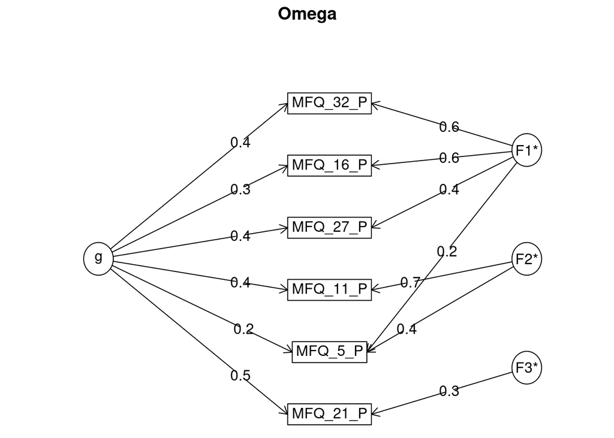

```
## Omega
## Call: omegah(m = m, nfactors = nfactors, fm = fm, key = key, flip = flip,
##     digits = digits, title = title, sl = sl, labels = labels,
##     plot = plot, n.obs = n.obs, rotate = rotate, Phi = Phi, option = option,
##     covar = covar)
## Alpha:                 0.68
## G.6:                   0.67
## Omega Hierarchical:    0.36
## Omega H asymptotic:    0.47
## Omega Total            0.76
##
## Schmid Leiman Factor loadings greater than  0.2
##             g   F1*   F2*   F3*   h2   u2   p2
## MFQ_5_P  0.25  0.23  0.37       0.26 0.74 0.24
## MFQ_11_P 0.35        0.71       0.63 0.37 0.19
## MFQ_16_P 0.29  0.60             0.46 0.54 0.19
## MFQ_21_P 0.49        0.20  0.35 0.42 0.58 0.57
## MFQ_27_P 0.41  0.41             0.36 0.64 0.46
## MFQ_32_P 0.44  0.61             0.58 0.42 0.33
##
## With Sums of squares  of:
##    g  F1*  F2*  F3*
## 0.87 0.98 0.69 0.17
##
## general/max  0.89   max/min =   5.61
## mean percent general =  0.33    with sd =  0.16 and cv of  0.47
## Explained Common Variance of the general factor =  0.32
##
## The degrees of freedom are 0  and the fit is  0
## The number of observations was  652  with Chi Square =  0  with prob <  NA
## The root mean square of the residuals is  0
## The df corrected root mean square of the residuals is  NA
##
## Compare this with the adequacy of just a general factor and no group factors
## The degrees of freedom for just the general factor are 9  and the fit is  0.38
## The number of observations was  652  with Chi Square =  247.94  with prob <  0.0000000000000000000000000000000000000000000000027
## The root mean square of the residuals is  0.17
## The df corrected root mean square of the residuals is  0.22
##
## RMSEA index =  0.202  and the 10 % confidence intervals are  0.181 0.224
## BIC =  189.62
##
## Measures of factor score adequacy
##                                                   g  F1*  F2*   F3*
## Correlation of scores with factors             0.63 0.73 0.74  0.43
## Multiple R square of scores with factors       0.40 0.53 0.55  0.19
## Minimum correlation of factor score estimates -0.21 0.07 0.11 -0.62
##
##  Total, General and Subset omega for each subset
##                                                  g  F1*  F2*  F3*
## Omega total for total scores and subscales    0.76 0.71 0.58 0.36
## Omega general for total scores and subscales  0.36 0.23 0.13 0.24
## Omega group for total scores and subscales    0.28 0.48 0.44 0.12
```

```r
psych::omega(pur_mfq)
```

```r
ind_mfq <- mfq %>% select(ends_with("H") | ends_with("F"))
psych::alpha(ind_mfq)
```

```
##
## Reliability analysis
## Call: psych::alpha(x = ind_mfq)
##
##   raw_alpha std.alpha G6(smc) average_r S/N   ase mean   sd median_r
##       0.82      0.83    0.84      0.29 4.9 0.011  3.6 0.72     0.29
##
##     95% confidence boundaries
##          lower alpha upper
## Feldt      0.8  0.82  0.84
## Duhachek   0.8  0.82  0.84
##
##  Reliability if an item is dropped:
##          raw_alpha std.alpha G6(smc) average_r S/N alpha se var.r med.r
## MFQ_1_H       0.80      0.81    0.82      0.28 4.3    0.012 0.019  0.29
## MFQ_7_H       0.80      0.81    0.82      0.28 4.3    0.012 0.019  0.29
## MFQ_12_H      0.80      0.82    0.82      0.29 4.4    0.012 0.016  0.29
## MFQ_17_H      0.79      0.81    0.82      0.27 4.1    0.012 0.020  0.27
## MFQ_23_H      0.81      0.82    0.83      0.30 4.6    0.011 0.020  0.33
## MFQ_28_H      0.82      0.83    0.84      0.31 5.0    0.010 0.016  0.35
## MFQ_2_F       0.79      0.81    0.82      0.28 4.2    0.012 0.017  0.29
## MFQ_8_F       0.80      0.81    0.82      0.28 4.2    0.012 0.018  0.29
## MFQ_13_F      0.80      0.81    0.82      0.28 4.4    0.012 0.016  0.29
## MFQ_18_F      0.80      0.81    0.82      0.28 4.2    0.012 0.020  0.27
## MFQ_24_F      0.80      0.82    0.83      0.29 4.5    0.011 0.020  0.33
## MFQ_29_F      0.83      0.84    0.85      0.32 5.1    0.010 0.016  0.35
##
##  Item statistics
##            n raw.r std.r r.cor r.drop mean  sd
## MFQ_1_H  646  0.65  0.66  0.62   0.56  3.5 1.2
## MFQ_7_H  645  0.65  0.65  0.61   0.55  3.4 1.2
## MFQ_12_H 645  0.58  0.59  0.55   0.47  3.7 1.3
## MFQ_17_H 646  0.69  0.70  0.67   0.62  3.8 1.1
## MFQ_23_H 646  0.53  0.53  0.45   0.41  3.8 1.3
## MFQ_28_H 646  0.43  0.40  0.31   0.27  3.5 1.5
## MFQ_2_F  646  0.66  0.67  0.64   0.57  3.4 1.2
## MFQ_8_F  645  0.66  0.67  0.64   0.57  3.4 1.2
## MFQ_13_F 646  0.60  0.61  0.57   0.50  3.7 1.2
## MFQ_18_F 647  0.66  0.67  0.64   0.58  4.1 1.1
## MFQ_24_F 646  0.57  0.57  0.52   0.47  3.9 1.1
## MFQ_29_F 646  0.39  0.35  0.25   0.22  2.6 1.5
##
## Non missing response frequency for each item
##             0    1    2    3    4    5 miss
## MFQ_1_H  0.02 0.04 0.14 0.25 0.35 0.21 0.01
## MFQ_7_H  0.02 0.06 0.13 0.25 0.34 0.19 0.01
## MFQ_12_H 0.03 0.04 0.09 0.18 0.34 0.31 0.01
## MFQ_17_H 0.01 0.02 0.07 0.24 0.34 0.32 0.01
## MFQ_23_H 0.02 0.04 0.08 0.23 0.20 0.43 0.01
## MFQ_28_H 0.04 0.07 0.14 0.14 0.24 0.36 0.01
## MFQ_2_F  0.03 0.04 0.14 0.24 0.38 0.16 0.01
## MFQ_8_F  0.02 0.04 0.13 0.28 0.34 0.19 0.01
## MFQ_13_F 0.02 0.04 0.12 0.20 0.34 0.29 0.01
## MFQ_18_F 0.01 0.02 0.06 0.17 0.25 0.49 0.01
## MFQ_24_F 0.01 0.02 0.09 0.20 0.33 0.35 0.01
## MFQ_29_F 0.11 0.16 0.21 0.23 0.18 0.12 0.01
```

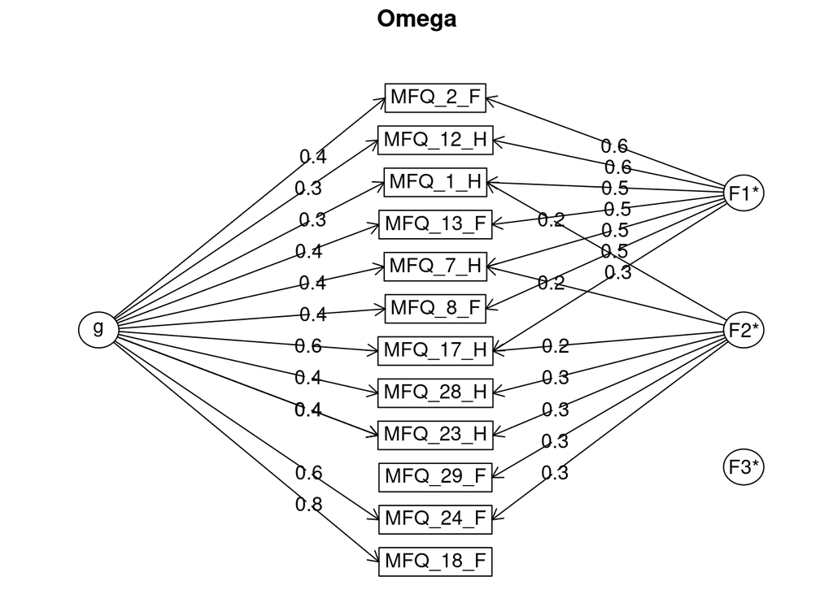

```
## Omega
## Call: omegah(m = m, nfactors = nfactors, fm = fm, key = key, flip = flip,
##     digits = digits, title = title, sl = sl, labels = labels,
##     plot = plot, n.obs = n.obs, rotate = rotate, Phi = Phi, option = option,
##     covar = covar)
## Alpha:                 0.83
## G.6:                   0.84
## Omega Hierarchical:    0.55
## Omega H asymptotic:    0.64
## Omega Total            0.86
##
## Schmid Leiman Factor loadings greater than  0.2
##             g   F1*   F2*   F3*   h2   u2   p2
## MFQ_1_H  0.34  0.54  0.21       0.45 0.55 0.26
## MFQ_7_H  0.36  0.52  0.20       0.43 0.57 0.30
## MFQ_12_H 0.35  0.58 -0.20       0.50 0.50 0.24
## MFQ_17_H 0.55  0.31  0.24       0.46 0.54 0.67
## MFQ_23_H 0.41        0.33       0.29 0.71 0.58
## MFQ_28_H 0.38        0.33       0.27 0.73 0.54
## MFQ_2_F  0.39  0.59             0.50 0.50 0.30
## MFQ_8_F  0.44  0.52             0.46 0.54 0.42
## MFQ_13_F 0.39  0.54             0.49 0.51 0.32
## MFQ_18_F 0.84                   0.70 0.30 0.99
## MFQ_24_F 0.58        0.25       0.41 0.59 0.84
## MFQ_29_F 0.20        0.30       0.13 0.87 0.29
##
## With Sums of squares  of:
##    g  F1*  F2*  F3*
## 2.57 1.92 0.59 0.00
##
## general/max  1.33   max/min =   Inf
## mean percent general =  0.48    with sd =  0.25 and cv of  0.52
## Explained Common Variance of the general factor =  0.5
##
## The degrees of freedom are 33  and the fit is  0.17
## The number of observations was  652  with Chi Square =  108.4  with prob <  0.00000000058
## The root mean square of the residuals is  0.03
## The df corrected root mean square of the residuals is  0.04
## RMSEA index =  0.059  and the 10 % confidence intervals are  0.047 0.072
## BIC =  -105.44
##
## Compare this with the adequacy of just a general factor and no group factors
## The degrees of freedom for just the general factor are 54  and the fit is  1.29
## The number of observations was  652  with Chi Square =  833.83  with prob <  0.00000000000000000000000000000000000000000000000000000000000000000000000000000000000000000000000000000000000000000000000000000000000000000003
## The root mean square of the residuals is  0.16
## The df corrected root mean square of the residuals is  0.18
##
## RMSEA index =  0.149  and the 10 % confidence intervals are  0.14 0.158
## BIC =  483.91
##
## Measures of factor score adequacy
##                                                  g  F1*   F2* F3*
## Correlation of scores with factors            0.89 0.84  0.68   0
## Multiple R square of scores with factors      0.79 0.71  0.46   0
## Minimum correlation of factor score estimates 0.57 0.42 -0.08  -1
##
##  Total, General and Subset omega for each subset
##                                                  g  F1*  F2* F3*
## Omega total for total scores and subscales    0.86 0.85 0.69  NA
## Omega general for total scores and subscales  0.55 0.32 0.56  NA
## Omega group for total scores and subscales    0.28 0.52 0.13  NA
```

```r
psych::omega(ind_mfq)
```

```r
bind_mfq <- mfq %>% select(ends_with("L") | ends_with("A") | ends_with("P"))
psych::alpha(bind_mfq)
```

```
##
## Reliability analysis
## Call: psych::alpha(x = bind_mfq)
##
##   raw_alpha std.alpha G6(smc) average_r S/N    ase mean   sd median_r
##       0.85      0.85    0.87      0.25 5.9 0.0082    3 0.74     0.26
##
##     95% confidence boundaries
##          lower alpha upper
## Feldt     0.84  0.85  0.87
## Duhachek  0.84  0.85  0.87
##
##  Reliability if an item is dropped:
##          raw_alpha std.alpha G6(smc) average_r S/N alpha se var.r med.r
## MFQ_3_L       0.84      0.84    0.86      0.24 5.4   0.0089 0.014  0.25
## MFQ_9_L       0.85      0.85    0.87      0.25 5.6   0.0084 0.013  0.26
## MFQ_14_L      0.84      0.84    0.86      0.24 5.4   0.0088 0.014  0.25
## MFQ_19_L      0.85      0.85    0.87      0.25 5.7   0.0085 0.013  0.25
## MFQ_25_L      0.85      0.85    0.87      0.25 5.5   0.0086 0.014  0.25
## MFQ_30_L      0.85      0.85    0.87      0.25 5.6   0.0086 0.014  0.25
## MFQ_4_A       0.85      0.84    0.86      0.24 5.4   0.0087 0.015  0.26
## MFQ_10_A      0.85      0.85    0.87      0.24 5.5   0.0087 0.015  0.25
## MFQ_15_A      0.85      0.85    0.87      0.26 5.9   0.0082 0.013  0.26
## MFQ_20_A      0.84      0.84    0.86      0.24 5.4   0.0088 0.015  0.25
## MFQ_26_A      0.85      0.85    0.87      0.25 5.5   0.0087 0.014  0.25
## MFQ_31_A      0.85      0.85    0.87      0.25 5.6   0.0085 0.015  0.26
## MFQ_5_P       0.85      0.85    0.87      0.25 5.6   0.0085 0.014  0.26
## MFQ_11_P      0.86      0.85    0.87      0.26 5.9   0.0082 0.012  0.26
## MFQ_16_P      0.84      0.84    0.86      0.24 5.4   0.0089 0.014  0.25
## MFQ_21_P      0.85      0.85    0.87      0.25 5.6   0.0085 0.015  0.26
## MFQ_27_P      0.84      0.84    0.86      0.24 5.4   0.0088 0.015  0.25
## MFQ_32_P      0.84      0.84    0.86      0.24 5.3   0.0090 0.014  0.25
##
##  Item statistics
##            n raw.r std.r r.cor r.drop mean  sd
## MFQ_3_L  645  0.62  0.60  0.57   0.54  2.5 1.5
## MFQ_9_L  645  0.47  0.49  0.46   0.39  3.2 1.2
## MFQ_14_L 646  0.60  0.61  0.59   0.53  3.1 1.3
## MFQ_19_L 646  0.51  0.48  0.44   0.41  3.1 1.6
## MFQ_25_L 646  0.55  0.53  0.49   0.46  2.7 1.5
```

[output cut: 19 more lines]

```
## MFQ_19_L 0.09 0.10 0.13 0.25 0.17 0.26 0.01
## MFQ_25_L 0.10 0.14 0.20 0.23 0.20 0.13 0.01
## MFQ_30_L 0.04 0.11 0.23 0.26 0.24 0.12 0.01
## MFQ_4_A  0.05 0.09 0.21 0.30 0.25 0.10 0.01
## MFQ_10_A 0.08 0.20 0.24 0.27 0.16 0.05 0.01
## MFQ_15_A 0.01 0.03 0.13 0.24 0.35 0.24 0.01
## MFQ_20_A 0.02 0.04 0.09 0.26 0.32 0.26 0.01
## MFQ_26_A 0.09 0.09 0.14 0.29 0.19 0.19 0.01
## MFQ_31_A 0.04 0.06 0.14 0.29 0.28 0.18 0.01
## MFQ_5_P  0.04 0.08 0.12 0.25 0.34 0.18 0.01
## MFQ_11_P 0.03 0.06 0.17 0.24 0.31 0.19 0.01
## MFQ_16_P 0.19 0.18 0.15 0.20 0.16 0.12 0.01
## MFQ_21_P 0.03 0.05 0.12 0.27 0.28 0.26 0.01
## MFQ_27_P 0.05 0.09 0.16 0.38 0.22 0.11 0.01
## MFQ_32_P 0.12 0.08 0.15 0.30 0.20 0.15 0.01
```

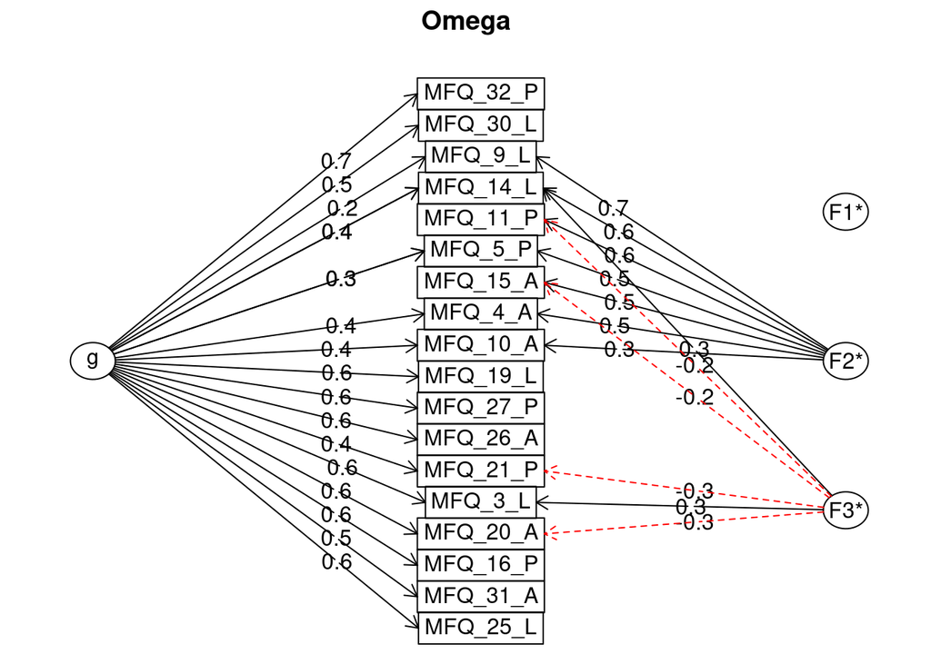

```
## Omega
## Call: omegah(m = m, nfactors = nfactors, fm = fm, key = key, flip = flip,
##     digits = digits, title = title, sl = sl, labels = labels,
##     plot = plot, n.obs = n.obs, rotate = rotate, Phi = Phi, option = option,
##     covar = covar)
## Alpha:                 0.85
## G.6:                   0.87
## Omega Hierarchical:    0.71
## Omega H asymptotic:    0.8
## Omega Total            0.88
##
## Schmid Leiman Factor loadings greater than  0.2
##              g   F1*   F2*   F3*   h2   u2   p2
## MFQ_3_L   0.60              0.30 0.47 0.53 0.77
## MFQ_9_L   0.20        0.67       0.51 0.49 0.08
## MFQ_14_L  0.40        0.57  0.29 0.56 0.44 0.28
## MFQ_19_L  0.57                   0.36 0.64 0.92
## MFQ_25_L  0.57                   0.33 0.67 0.99
## MFQ_30_L  0.54                   0.30 0.70 0.99
## MFQ_4_A   0.39        0.45       0.38 0.62 0.40
## MFQ_10_A  0.44        0.34       0.31 0.69 0.61
## MFQ_15_A              0.53 -0.20 0.33 0.67 0.03
## MFQ_20_A  0.59             -0.27 0.43 0.57 0.81
## MFQ_26_A  0.61                   0.38 0.62 0.97
## MFQ_31_A  0.50             -0.20 0.28 0.72 0.87
## MFQ_5_P   0.25        0.53       0.37 0.63 0.18
## MFQ_11_P              0.57 -0.24 0.40 0.60 0.02
## MFQ_16_P  0.59              0.20 0.41 0.59 0.85
## MFQ_21_P  0.41             -0.33 0.30 0.70 0.56
## MFQ_27_P  0.59                   0.36 0.64 0.97
## MFQ_32_P  0.68                   0.47 0.53 0.99
##
## With Sums of squares  of:
##    g  F1*  F2*  F3*
## 4.22 0.01 2.10 0.61
##
## general/max  2.01   max/min =   152
## mean percent general =  0.63    with sd =  0.37 and cv of  0.58
## Explained Common Variance of the general factor =  0.61
##
```

[output cut: 12 more lines]

```
##
## RMSEA index =  0.11  and the 10 % confidence intervals are  0.105 0.116
## BIC =  328.68
##
## Measures of factor score adequacy
##                                                  g   F1*  F2*  F3*
## Correlation of scores with factors            0.93  0.06 0.88 0.72
## Multiple R square of scores with factors      0.86  0.00 0.77 0.51
## Minimum correlation of factor score estimates 0.71 -0.99 0.53 0.02
##
##  Total, General and Subset omega for each subset
##                                                  g  F1*  F2*  F3*
## Omega total for total scores and subscales    0.88 0.56 0.81 0.73
## Omega general for total scores and subscales  0.71 0.56 0.42 0.73
## Omega group for total scores and subscales    0.13 0.00 0.39 0.00
```

```r
psych::omega(bind_mfq)
```

# Correlations

```r
crCrime <- filter(crCrime, gender < 3, education < 7, stringsAsFactors = TRUE)

dv_means <- crCrime %>%
  transmute(
    mean_severity = rowMeans(select(., ends_with("_serious")), na.rm = TRUE),
    mean_harm     = rowMeans(select(., ends_with("_harm")), na.rm = TRUE),
    mean_sentence = rowMeans(select(., ends_with("_sentence")), na.rm = TRUE),
    mean_rehab    = rowMeans(select(., ends_with("_rehab")), na.rm = TRUE)
  )

cor_crime <- bind_cols(crCrime %>%
  select(
    age, gender, education, ses,
    psych_total, mach_total, narc_total, sadism_total,
    mfq_care, mfq_fair, mfq_loyalty, mfq_authority, mfq_purity,
    mfq_individualizing, mfq_bind,
    cse_total, legal), dv_means
)

library(apaTables)
apa.cor.table(
  cor_crime,
  filename = "correl_crime.doc",
  table.number = 1,
  show.conf.interval = TRUE,
  show.sig.stars = TRUE,
  landscape = TRUE
)
```

```
##
##
## Table 1
##
## Means, standard deviations, and correlations with confidence intervals
##
##
##   Variable                M     SD    1           2            3
##   1. age                  23.45 8.53
##
##   2. gender               1.56  0.50  -.06
##                                       [-.14, .02]
##
##   3. education            2.99  1.23  .63**       -.02
##                                       [.58, .68]  [-.10, .05]
##
##   4. ses                  6.45  1.65  .11**       -.06         .13**
##                                       [.03, .18]  [-.14, .02]  [.05, .20]
##
##   5. psych_total          15.87 6.02  .29**       -.16**       .35**
##                                       [.21, .35]  [-.24, -.09] [.28, .41]
##
##   6. mach_total           24.19 4.77  .17**       -.13**       .18**
##                                       [.09, .24]  [-.21, -.06] [.11, .25]
##
##   7. narc_total           21.66 5.17  .13**       -.08*        .18**
##                                       [.06, .21]  [-.16, -.01] [.11, .26]
##
##   8. sadism_total         18.47 5.88  .07         -.30**       .05
##                                       [-.01, .14] [-.37, -.23] [-.03, .13]
##
##   9. mfq_care             21.63 5.15  -.01        .22**        .02
##                                       [-.09, .06] [.14, .29]   [-.06, .10]
##
##   10. mfq_fair            20.84 5.00  .04         .13**        .08
##                                       [-.04, .11] [.05, .20]   [-.00, .15]
##
##   11. mfq_loyalty         17.18 5.51  .24**       -.11**       .22**
##                                       [.17, .31]  [-.19, -.04] [.14, .29]
##
```

[output cut: 211 more lines]

```
##   [.04, .19]  [.23, .37]  [.69, .76]
##
##   .07         -.00        .41**      .25**
##   [-.01, .14] [-.08, .07] [.34, .47] [.18, .32]
##
##   .10**       .15**       .41**      .39**      .35**
##   [.03, .18]  [.07, .22]  [.35, .47] [.32, .45] [.28, .41]
##
##
## Note. M and SD are used to represent mean and standard deviation, respectively.
## Values in square brackets indicate the 95% confidence interval.
## The confidence interval is a plausible range of population correlations
## that could have caused the sample correlation (Cumming, 2014).
##  * indicates p < .05. ** indicates p < .01.
##
```

# Assumption Checks

```r
shapiro.test(crCrime$cse_total)
```

```
##
##  Shapiro-Wilk normality test
##
## data:  crCrime$cse_total
## W = 0.96648, p-value = 0.00000000004718
```

```r
shapiro.test(crCrime$mach_total)
```

```
##
##  Shapiro-Wilk normality test
##
## data:  crCrime$mach_total
## W = 0.94499, p-value = 0.000000000000007917
```

```r
shapiro.test(crCrime$narc_total)
```

```
##
##  Shapiro-Wilk normality test
##
## data:  crCrime$narc_total
## W = 0.98171, p-value = 0.0000002837
```

```r
shapiro.test(crCrime$psych_total)
```

```
##
##  Shapiro-Wilk normality test
##
## data:  crCrime$psych_total
## W = 0.95967, p-value = 0.00000000000217
```

```r
shapiro.test(crCrime$sadism_total)
```

```
##
##  Shapiro-Wilk normality test
##
## data:  crCrime$sadism_total
## W = 0.99299, p-value = 0.003792
```

```r
shapiro.test(crCrime$mfq_individualizing)
```

```
##
##  Shapiro-Wilk normality test
##
## data:  crCrime$mfq_individualizing
## W = 0.93162, p-value < 0.00000000000000022
```

```r
shapiro.test(crCrime$mfq_bind)
```

```
##
##  Shapiro-Wilk normality test
##
## data:  crCrime$mfq_bind
## W = 0.98317, p-value = 0.0000007904
```

```r
shapiro.test(crCrime$legal)
```

```
##
##  Shapiro-Wilk normality test
##
## data:  crCrime$legal
## W = 0.97219, p-value = 0.0000000009041
```

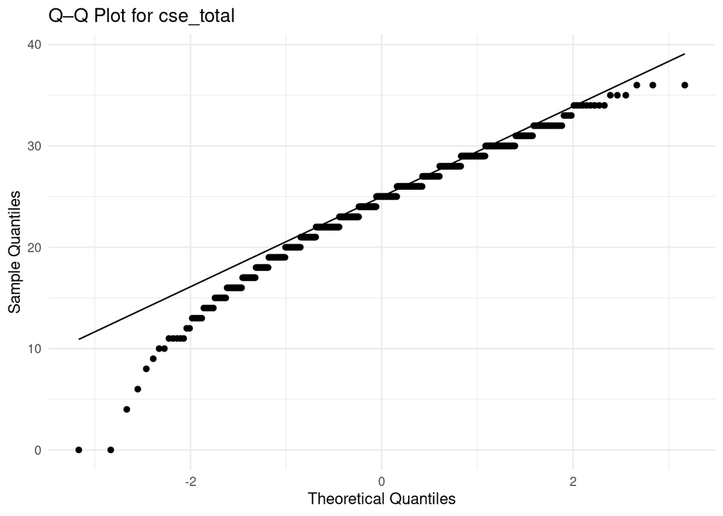

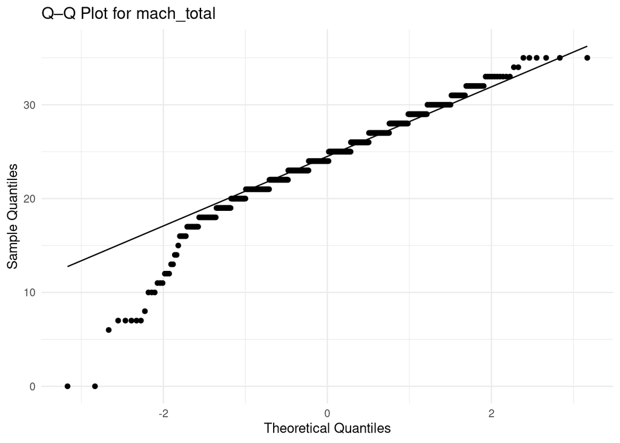

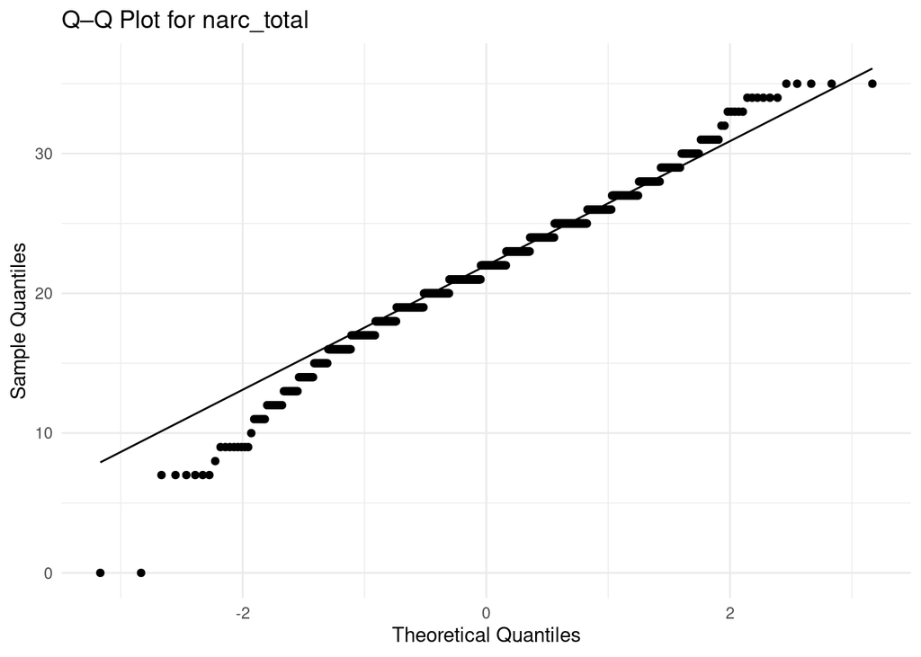

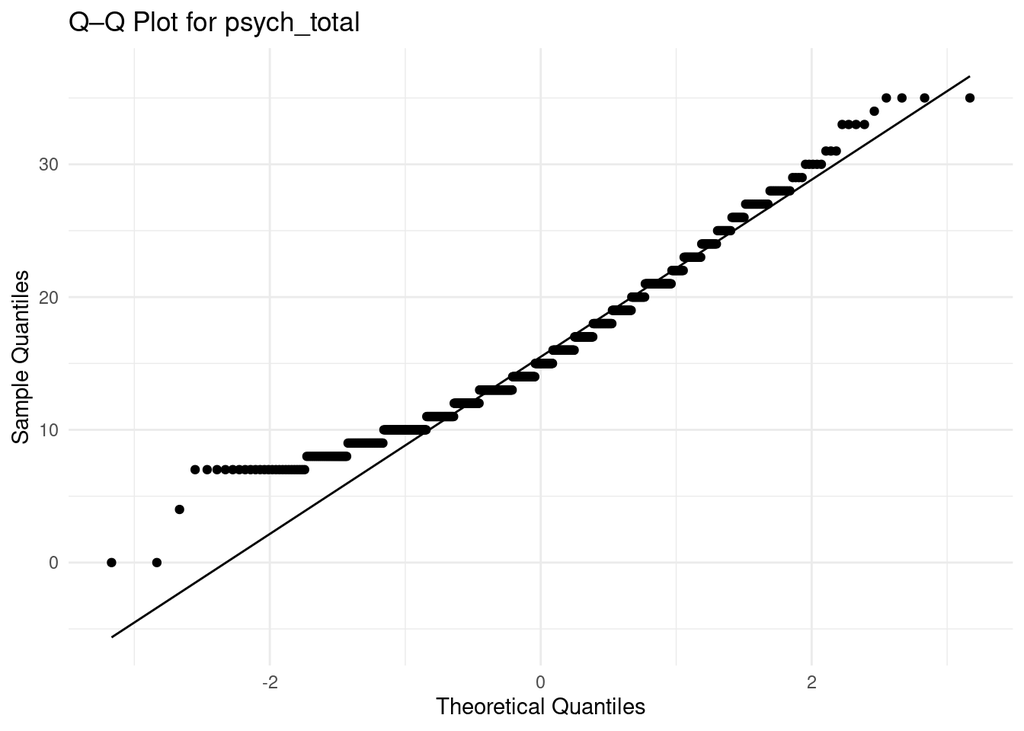

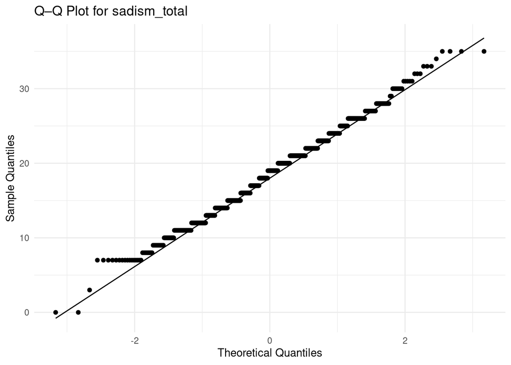

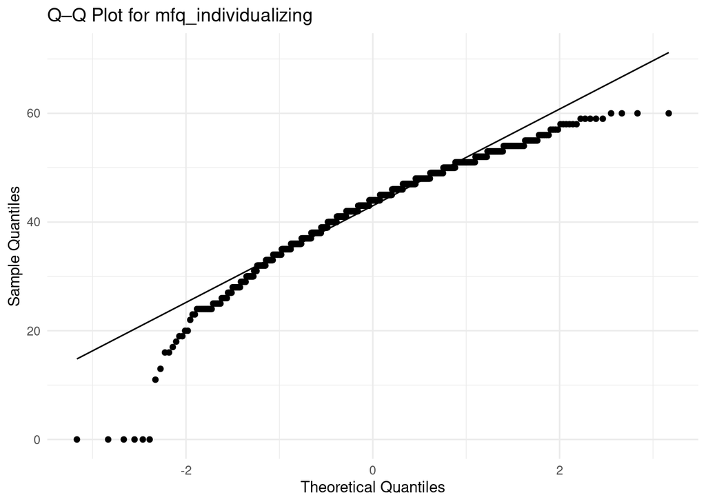

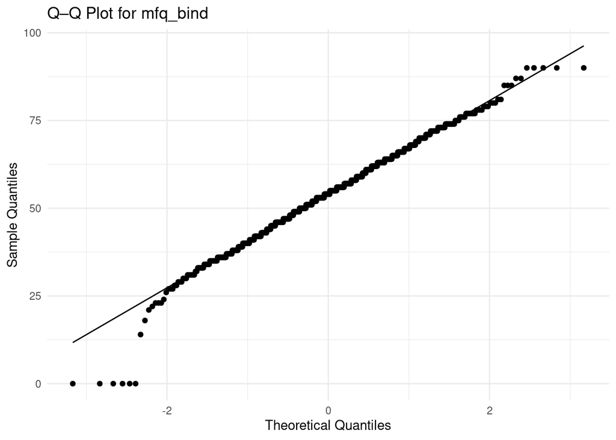

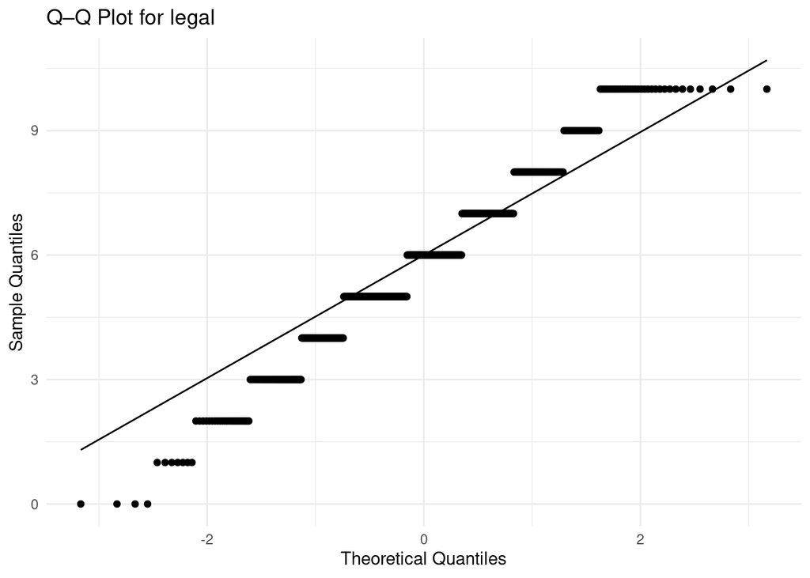

```r
norm_df <- c(
  "cse_total",
  "mach_total",
  "narc_total",
  "psych_total",
  "sadism_total",
  "mfq_individualizing",
  "mfq_bind",
  "legal"
)
#QQ plots

for (v in norm_df) {
  print(
    ggplot(crCrime, aes(sample = .data[[v]])) +
      stat_qq() +
      stat_qq_line() +
      theme_minimal() +
      labs(
        title = paste("Q–Q Plot for", v),
        x = "Theoretical Quantiles",
        y = "Sample Quantiles"
      )
  )
}
```

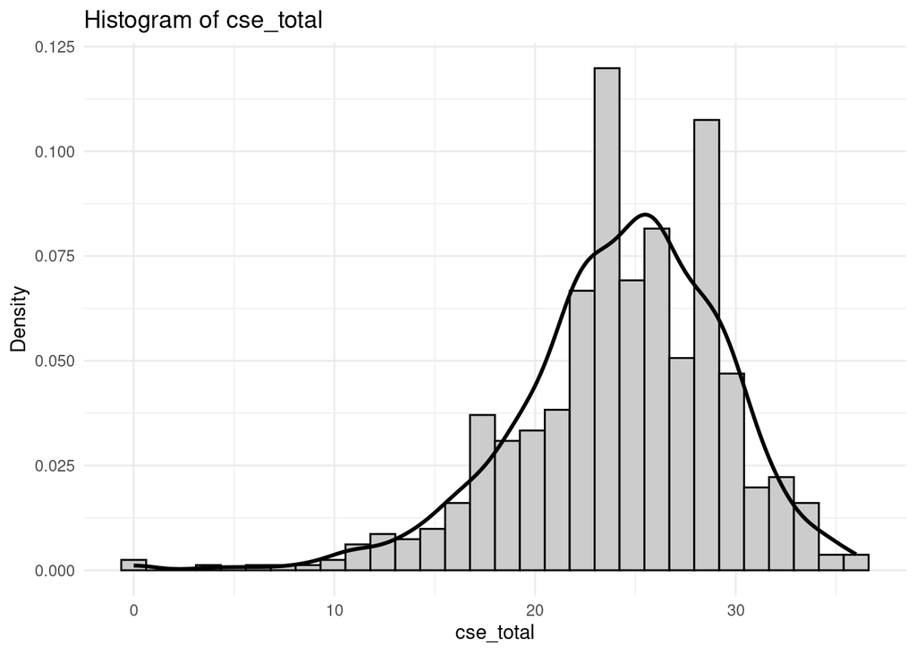

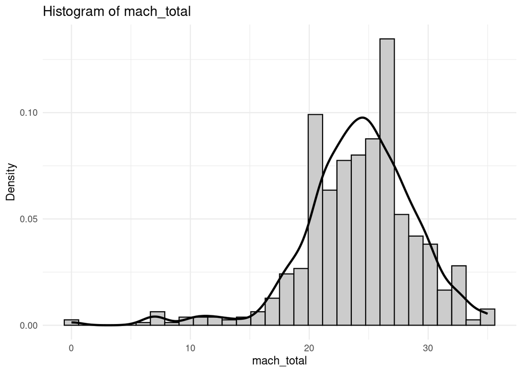

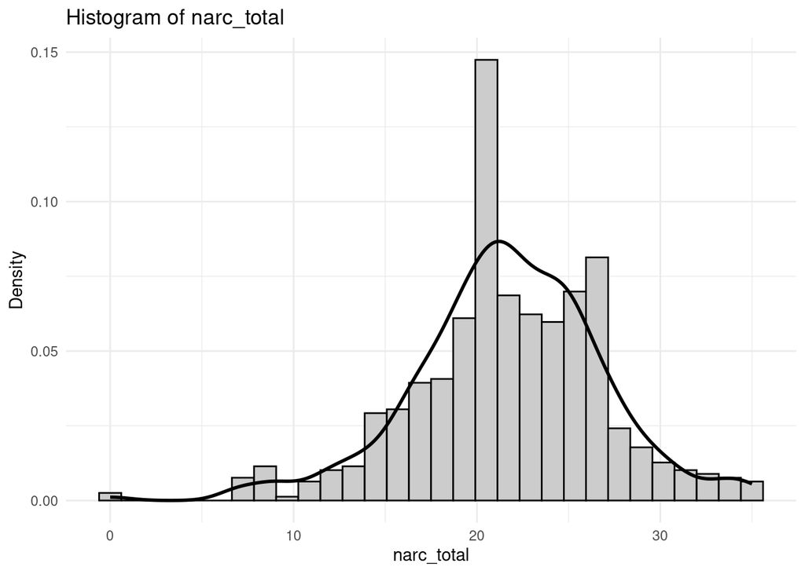

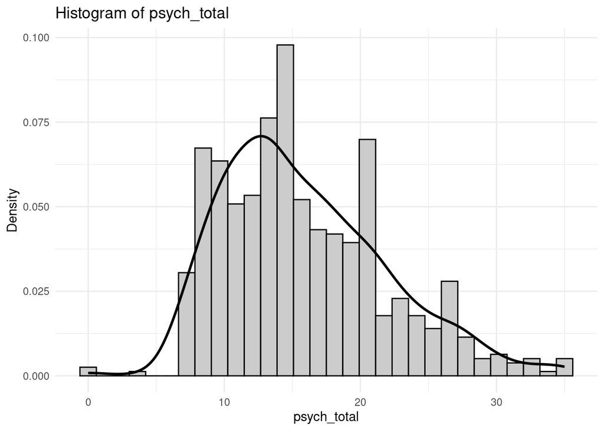

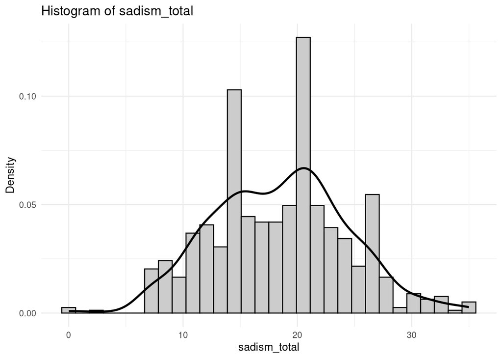

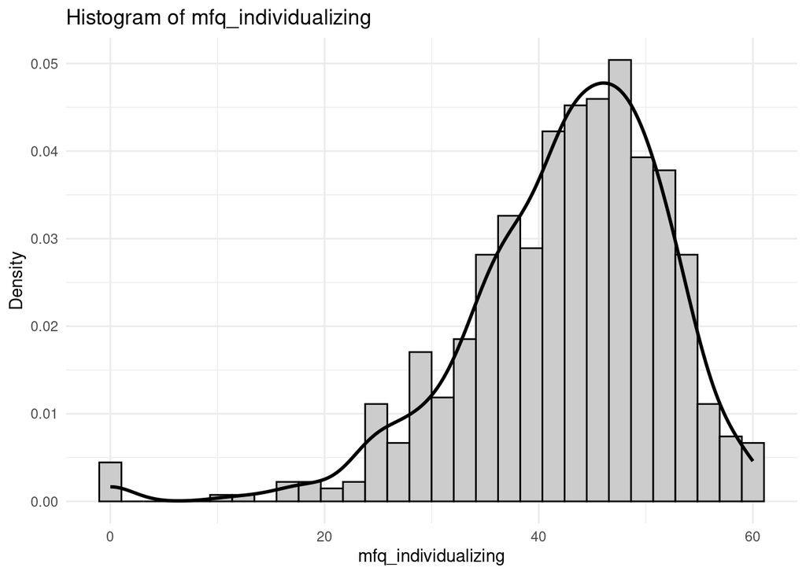

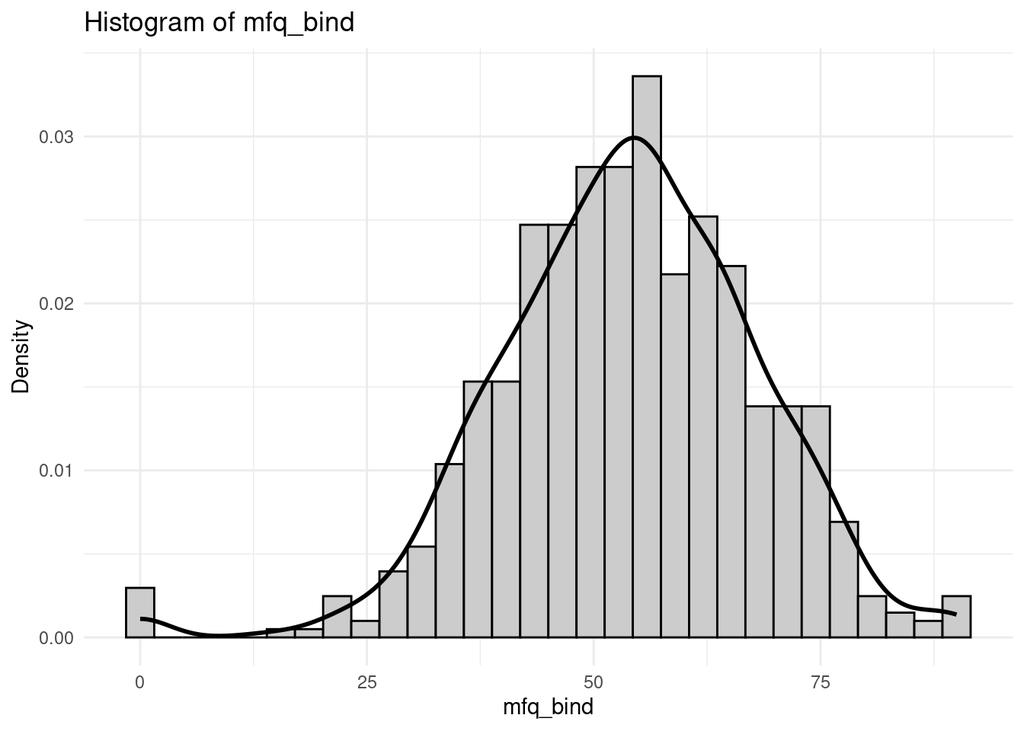

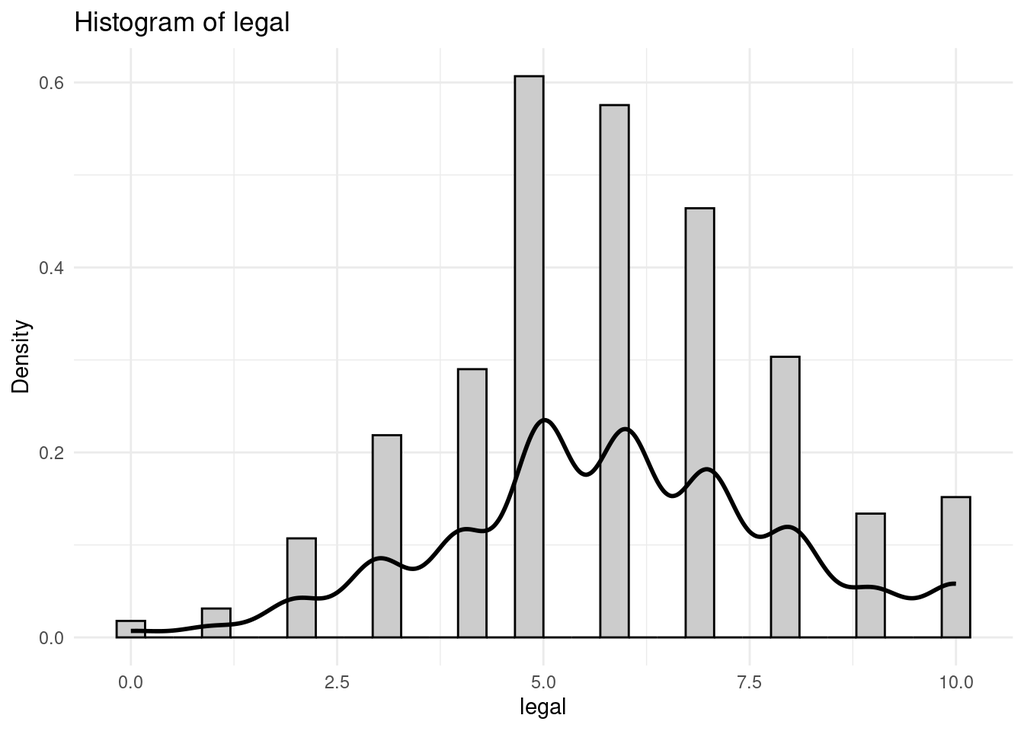

```r
#Histogram

for (v in norm_df) {
  print(
    ggplot(crCrime, aes(x = .data[[v]])) +
      geom_histogram(
        aes(y = after_stat(density)),
        bins = 30,
        fill = "grey80",
        color = "black"
      ) +
      geom_density(linewidth = 1) +
      theme_minimal() +
      labs(
        title = paste("Histogram of", v),
        x = v,
        y = "Density"
      )
  )
}
```

# long data conversion

```r
library(ordinal)
crCrime <- crCrime %>%
  mutate(
    PID = factor(PID),
    gender = factor(gender),
  )


df_long <- crCrime %>%
  pivot_longer(
    cols = matches("^(Cr|non_Cr)"),
    names_to = c("creativity_dummy", "moral_valence", ".value"),
    names_pattern = "^(non_)?Cr(.*)_(harm|serious|sentence|rehab)$"
  ) %>%
  mutate(
    moral_valence = case_match(
      tolower(moral_valence),
      "amb"  ~ "ambiguous",
      "self" ~ "self_interested",
      "sin"  ~ "sinful",
      "evil" ~ "evil"
    )
  ) %>%
  mutate(
    creativity = case_when(
      moral_valence == "ambiguous"        & Amb_shown  == 1 ~ "Creative",
      moral_valence == "ambiguous"        & Amb_shown  == 0 ~ "NonCreative",
      moral_valence == "self_interested"  & Self_shown == 1 ~ "Creative",
      moral_valence == "self_interested"  & Self_shown == 0 ~ "NonCreative",
      moral_valence == "sinful"           & Sin_shown  == 1 ~ "Creative",
      moral_valence == "sinful"           & Sin_shown  == 0 ~ "NonCreative",
      moral_valence == "evil"             & Evil_shown == 1 ~ "Creative",
      moral_valence == "evil"             & Evil_shown == 0 ~ "NonCreative"
    ),
    creativity = factor(creativity, levels = c("Creative", "NonCreative")),
    moral_valence = factor(
      moral_valence,
      levels = c("evil", "sinful", "self_interested", "ambiguous")
    ),
    severity = serious
  ) %>%
  select(-serious, -creativity_dummy) %>%
  relocate(PID, creativity, moral_valence)

df_long %>%
  filter(moral_valence == "evil") %>%
  group_by(PID) %>%
  summarise(
    all_missing = all(is.na(harm) & is.na(severity) &
                      is.na(sentence) & is.na(rehab))
  ) %>%
  filter(all_missing)
```

```
## # A tibble: 1 × 2
##   PID   all_missing
##   <fct> <lgl>
## 1 US60  TRUE
```

```r
df_long <- df_long %>%
  filter(!is.na(harm) | !is.na(severity) | !is.na(sentence) | !is.na(rehab))

df_long$sentence_ord <- factor(df_long$sentence,
                              ordered = TRUE)

table(df_long$moral_valence, df_long$creativity)
```

```
##
##                   Creative NonCreative
##   evil                 332         319
##   sinful               327         325
##   self_interested      321         331
##   ambiguous            324         328
```

```r
psych::describe(df_long)
```

```
##                       vars    n    mean       sd median trimmed    mad   min
## PID*                     1 2607  326.39   188.21    326  326.38 241.66   1.0
## creativity*              2 2607    1.50     0.50      1    1.50   0.00   1.0
## moral_valence*           3 2607    2.50     1.12      3    2.50   1.48   1.0
## StartDate*               4 2607  306.56   174.31    313  310.34 229.80   1.0
## EndDate*                 5 2607  313.77   176.75    320  316.73 231.29   1.0
## Status                   6 2607    0.00     0.00      0    0.00   0.00   0.0
## Progress                 7 2607   99.92     0.59    100  100.00   0.00  92.0
## Duration..in.seconds.    8 2607 9867.14 55955.76   1033 1212.10 609.35 168.0
## Finished                 9 2607    0.97     0.18      1    1.00   0.00   0.0
## RecordedDate*           10 2607  313.29   176.43    319  316.20 231.29   1.0
## ResponseId*             11 2607  326.57   188.25    327  326.59 241.66   1.0
## DistributionChannel*    12 2607    1.00     0.00      1    1.00   0.00   1.0
## UserLanguage*           13 2607    1.00     0.00      1    1.00   0.00   1.0
## Q_RecaptchaScore        14 2607    0.97     0.09      1    0.99   0.00   0.1
## Q_DuplicateRespondent   15    0     NaN       NA     NA     NaN     NA   Inf
## consent                 16 2607    1.00     0.00      1    1.00   0.00   1.0
## age                     17 2607   23.46     8.53     20   21.50   2.97  18.0
## gender*                 18 2607    1.56     0.50      2    1.57   0.00   1.0
## gender_TEXT*            19 2607    1.00     0.04      1    1.00   0.00   1.0
## country_origin          20 2607    1.63     0.59      2    1.59   0.00   1.0
## country_origin_TEXT*    21 2607    1.63     3.11      1    1.00   0.00   1.0
## country_res             22 2603    1.62     0.53      2    1.62   0.00   1.0
## country_res_TEXT*       23 2607    1.12     0.93      1    1.00   0.00   1.0
## education               24 2607    2.99     1.23      2    2.85   0.00   1.0
## education_TEXT*         25 2607    1.14     1.11      1    1.00   0.00   1.0
## employ                  26 2607    1.56     0.94      1    1.35   0.00   1.0
## employ_TEXT*            27 2607    1.11     0.88      1    1.00   0.00   1.0
## marital                 28 2607    1.40     0.80      1    1.24   0.00   1.0
## marital_TEXT*           29 2607    1.01     0.15      1    1.00   0.00   1.0
## religion                30 1076    4.28     1.76      4    4.05   0.00   1.0
## religion_TEXT*          31 2607    1.04     0.46      1    1.00   0.00   1.0
## race                    32 1531    3.05     1.12      3    2.92   0.00   1.0
## race_TEXT*              33 2607    1.02     0.29      1    1.00   0.00   1.0
## engprof                 34 2607    9.13     1.27     10    9.38   0.00   5.0
## ses                     35 2603    6.45     1.65      7    6.42   1.48   1.0
## mach1                   36 2595    3.72     0.96      4    3.80   1.48   1.0
## mach2                   37 2587    3.36     1.03      3    3.38   1.48   1.0
## mach3                   38 2591    3.41     1.08      4    3.46   1.48   1.0
## mach4                   39 2595    3.22     1.06      3    3.22   1.48   1.0
```

[output cut: 201 more lines]

```
## mfq_authority             30     30.0  -0.55     1.07    0.10
## mfq_purity                30     30.0  -0.39     0.31    0.11
## mfq_individualizing       60     60.0  -1.22     2.94    0.19
## mfq_bind                  90     90.0  -0.40     1.13    0.28
## cse_total                 36     36.0  -0.78     1.68    0.10
## attention                  2      1.0  -1.66     0.74    0.01
## Amb_shown                  1      1.0   0.01    -2.00    0.01
## Self_shown                 1      1.0   0.03    -2.00    0.01
## Sin_shown                  1      1.0  -0.01    -2.00    0.01
## Evil_shown                 1      1.0  -0.04    -2.00    0.01
## harm                      10     10.0  -0.46    -0.83    0.06
## sentence                  10     10.0  -0.27    -0.92    0.06
## rehab                     10     10.0   0.17    -1.18    0.06
## severity                  10     10.0  -0.61    -0.52    0.05
## sentence_ord*             11     10.0  -0.27    -0.92    0.06
```

# H1: Non-creative crimes will consistently receive higher ratings for severity, harm, sentencing, and rehabilitation recommendations compared to creative crimes of the same valence, across all levels of moral valence.

```r
# AMBIGUOUS

df_amb <- df_long %>%filter(moral_valence == "ambiguous")

aov_amb_severity <- aov(severity ~ creativity + Error(PID/creativity), data = df_amb)
summary(aov_amb_severity)
```

```
##
## Error: PID
##             Df Sum Sq Mean Sq F value      Pr(>F)
## creativity   1    156  155.56   25.55 0.000000563 ***
## Residuals  644   3921    6.09
## ---
## Signif. codes:  0 '***' 0.001 '**' 0.01 '*' 0.05 '.' 0.1 ' ' 1
```

```r
aov_amb_harm <- aov(harm ~ creativity + Error(PID/creativity), data = df_amb)
summary(aov_amb_harm)
```

```
##
## Error: PID
##             Df Sum Sq Mean Sq F value     Pr(>F)
## creativity   1    147  147.40   22.26 0.00000292 ***
## Residuals  648   4292    6.62
## ---
## Signif. codes:  0 '***' 0.001 '**' 0.01 '*' 0.05 '.' 0.1 ' ' 1
```

```r
aov_amb_sentence <- aov(sentence ~ creativity + Error(PID/creativity), data = df_amb)
summary(aov_amb_sentence)
```

```
##
## Error: PID
##             Df Sum Sq Mean Sq F value Pr(>F)
## creativity   1     50   49.95   7.863 0.0052 **
## Residuals  650   4129    6.35
## ---
## Signif. codes:  0 '***' 0.001 '**' 0.01 '*' 0.05 '.' 0.1 ' ' 1
```

```r
aov_amb_rehab <- aov(rehab ~ creativity + Error(PID/creativity), data = df_amb)
summary(aov_amb_rehab)
```

```
##
## Error: PID
##             Df Sum Sq Mean Sq F value Pr(>F)
## creativity   1     30  30.291   3.291 0.0701 .
## Residuals  649   5973   9.203
## ---
## Signif. codes:  0 '***' 0.001 '**' 0.01 '*' 0.05 '.' 0.1 ' ' 1
```

```r
# Extract p-values for Ambiguous condition

extract_creativity_p <- function(aov_model) {
  s <- summary(aov_model)
  for (i in seq_along(s)) {
    tab <- s[[i]][[1]]
    if (!is.null(tab) && "creativity" %in% rownames(tab)) {
      return(tab["creativity", "Pr(>F)"])
    }
  }
  return(NA_real_)
}
p_amb <- c(
  extract_creativity_p(aov_amb_severity),
  extract_creativity_p(aov_amb_harm),
  extract_creativity_p(aov_amb_sentence),
  extract_creativity_p(aov_amb_rehab)
)

names(p_amb) <- c("severity", "harm", "sentence", "rehab")

p_amb_holm <- p.adjust(p_amb, method = "holm")

data.frame(
  DV = names(p_amb),
  p_raw = p_amb,
  p_holm = p_amb_holm
)
```

```
##                DV           p_raw         p_holm
## severity severity 0.0000005632528 0.000002253011
## harm         harm 0.0000029232305 0.000008769691
## sentence sentence 0.0051967325213 0.010393465043
## rehab       rehab 0.0701041197407 0.070104119741
```

```r
df_amb %>%
  group_by(creativity) %>%
  summarise(
    mean_severity = mean(severity, na.rm = TRUE),
    mean_harm = mean(harm, na.rm = TRUE),
    mean_sentence = mean(sentence, na.rm = TRUE),
    mean_rehab = mean(rehab, na.rm = TRUE),
    n = n()
  )
```

```
## # A tibble: 2 × 6
##   creativity  mean_severity mean_harm mean_sentence mean_rehab     n
##   <fct>               <dbl>     <dbl>         <dbl>      <dbl> <int>
## 1 Creative             6.73      5.74          5.14       4.02   324
## 2 NonCreative          5.75      4.79          4.59       3.59   328
```

```r
# SELF-INTERESTED

df_self <- df_long %>% filter(moral_valence == "self_interested")

aov_self_severity <- aov(severity ~ creativity + Error(PID/creativity), data = df_self)
summary(aov_self_severity)
```

```
##
## Error: PID
##             Df Sum Sq Mean Sq F value   Pr(>F)
## creativity   1     85   85.16    14.7 0.000138 ***
## Residuals  648   3754    5.79
## ---
## Signif. codes:  0 '***' 0.001 '**' 0.01 '*' 0.05 '.' 0.1 ' ' 1
```

```r
aov_self_harm <- aov(harm ~ creativity + Error(PID/creativity), data = df_self)
summary(aov_self_harm)
```

```
##
## Error: PID
##             Df Sum Sq Mean Sq F value  Pr(>F)
## creativity   1     59   59.09   8.953 0.00288 **
## Residuals  649   4284    6.60
## ---
## Signif. codes:  0 '***' 0.001 '**' 0.01 '*' 0.05 '.' 0.1 ' ' 1
```

```r
aov_self_sentence <- aov(sentence ~ creativity + Error(PID/creativity), data = df_self)
summary(aov_self_sentence)
```

```
##
## Error: PID
##             Df Sum Sq Mean Sq F value   Pr(>F)
## creativity   1   68.9   68.94    14.2 0.000179 ***
## Residuals  650 3156.1    4.86
## ---
## Signif. codes:  0 '***' 0.001 '**' 0.01 '*' 0.05 '.' 0.1 ' ' 1
```

```r
aov_self_rehab <- aov(rehab ~ creativity + Error(PID/creativity), data = df_self)
summary(aov_self_rehab)
```

```
##
## Error: PID
##             Df Sum Sq Mean Sq F value Pr(>F)
## creativity   1     31  31.376   4.604 0.0323 *
## Residuals  650   4430   6.815
## ---
## Signif. codes:  0 '***' 0.001 '**' 0.01 '*' 0.05 '.' 0.1 ' ' 1
```

```r
p_self <- c(
  extract_creativity_p(aov_self_severity),
  extract_creativity_p(aov_self_harm),
  extract_creativity_p(aov_self_sentence),
  extract_creativity_p(aov_self_rehab)
)

names(p_self) <- c("severity", "harm", "sentence", "rehab")

p_self_holm <- p.adjust(p_self, method = "holm")

data.frame(
  DV = names(p_self),
  p_raw = p_self,
  p_holm = p_self_holm
)
```

```
##                DV        p_raw       p_holm
## severity severity 0.0001384417 0.0005537666
## harm         harm 0.0028757376 0.0057514753
## sentence sentence 0.0001794853 0.0005537666
## rehab       rehab 0.0322709122 0.0322709122
```

```r
df_self %>%
  group_by(creativity) %>%
  summarise(
    mean_severity = mean(severity, na.rm = TRUE),
    mean_harm = mean(harm, na.rm = TRUE),
    mean_sentence = mean(sentence, na.rm = TRUE),
    mean_rehab = mean(rehab, na.rm = TRUE),
    n = n()
  )
```

```
## # A tibble: 2 × 6
##   creativity  mean_severity mean_harm mean_sentence mean_rehab     n
##   <fct>               <dbl>     <dbl>         <dbl>      <dbl> <int>
## 1 Creative             6.14      5.22          4.83       3.32   321
## 2 NonCreative          5.41      4.62          4.18       2.89   331
```

```r
# SINFUL

df_sin <- df_long %>% filter(moral_valence == "sinful")

aov_sin_severity <- aov(severity ~ creativity + Error(PID/creativity), data = df_sin)
summary(aov_sin_severity)
```

```
##
## Error: PID
##             Df Sum Sq Mean Sq F value Pr(>F)
## creativity   1   16.6  16.588   3.698 0.0549 .
## Residuals  649 2911.6   4.486
## ---
## Signif. codes:  0 '***' 0.001 '**' 0.01 '*' 0.05 '.' 0.1 ' ' 1
```

```r
aov_sin_harm <- aov(harm ~ creativity + Error(PID/creativity), data = df_sin)
summary(aov_sin_harm)
```

```
##
## Error: PID
##             Df Sum Sq Mean Sq F value Pr(>F)
## creativity   1      6   6.281   1.067  0.302
## Residuals  650   3826   5.886
```

```r
aov_sin_sentence <- aov(sentence ~ creativity + Error(PID/creativity), data = df_sin)
summary(aov_sin_sentence)
```

```
##
## Error: PID
##             Df Sum Sq Mean Sq F value Pr(>F)
## creativity   1      1   0.831   0.136  0.713
## Residuals  650   3980   6.123
```

```r
aov_sin_rehab <- aov(rehab ~ creativity + Error(PID/creativity), data = df_sin)
summary(aov_sin_rehab)
```

```
##
## Error: PID
##             Df Sum Sq Mean Sq F value Pr(>F)
## creativity   1      6   6.079   0.742  0.389
## Residuals  650   5329   8.198
```

```r
p_sin <- c(
  extract_creativity_p(aov_sin_severity),
  extract_creativity_p(aov_sin_harm),
  extract_creativity_p(aov_sin_sentence),
  extract_creativity_p(aov_sin_rehab)
)

names(p_sin) <- c("severity", "harm", "sentence", "rehab")

p_sin_holm <- p.adjust(p_sin, method = "holm")

data.frame(
  DV = names(p_sin),
  p_raw = p_sin,
  p_holm = p_sin_holm
)
```

```
##                DV      p_raw    p_holm
## severity severity 0.05492868 0.2197147
## harm         harm 0.30196944 0.9059083
## sentence sentence 0.71274227 0.9059083
## rehab       rehab 0.38948047 0.9059083
```

```r
df_sin %>%
  group_by(creativity) %>%
  summarise(
    mean_severity = mean(severity, na.rm = TRUE),
    mean_harm = mean(harm, na.rm = TRUE),
    mean_sentence = mean(sentence, na.rm = TRUE),
    mean_rehab = mean(rehab, na.rm = TRUE),
    n = n()
  )
```

```
## # A tibble: 2 × 6
##   creativity  mean_severity mean_harm mean_sentence mean_rehab     n
##   <fct>               <dbl>     <dbl>         <dbl>      <dbl> <int>
## 1 Creative             7.52      7.10          6.10       4.62   327
## 2 NonCreative          7.20      6.90          6.17       4.42   325
```

```r
# EVIL

df_evil <- df_long %>% filter(moral_valence == "evil")

aov_evil_severity <- aov(severity ~ creativity + Error(PID/creativity), data = df_evil)
summary(aov_evil_severity)
```

```
##
## Error: PID
##             Df Sum Sq Mean Sq F value Pr(>F)
## creativity   1    6.7   6.678   2.452  0.118
## Residuals  648 1764.6   2.723
```

```r
aov_evil_harm <- aov(harm ~ creativity + Error(PID/creativity), data = df_evil)
summary(aov_evil_harm)
```

```
##
## Error: PID
##             Df Sum Sq Mean Sq F value Pr(>F)
## creativity   1    0.1  0.1394   0.059  0.808
## Residuals  649 1532.2  2.3609
```

```r
aov_evil_sentence <- aov(sentence ~ creativity + Error(PID/creativity), data = df_evil)
summary(aov_evil_sentence)
```

```
##
## Error: PID
##             Df Sum Sq Mean Sq F value Pr(>F)
## creativity   1      3   3.149    0.55  0.459
## Residuals  649   3717   5.728
```

```r
aov_evil_rehab <- aov(rehab ~ creativity + Error(PID/creativity), data = df_evil)
summary(aov_evil_rehab)
```

```
##
## Error: PID
##             Df Sum Sq Mean Sq F value Pr(>F)
## creativity   1     12  11.660   1.401  0.237
## Residuals  649   5403   8.325
```

```r
p_evil <- c(
  extract_creativity_p(aov_evil_severity),
  extract_creativity_p(aov_evil_harm),
  extract_creativity_p(aov_evil_sentence),
  extract_creativity_p(aov_evil_rehab)
)

names(p_evil) <- c("severity", "harm", "sentence", "rehab")

p_evil_holm <- p.adjust(p_evil, method = "holm")

data.frame(
  DV = names(p_evil),
  p_raw = p_evil,
  p_holm = p_evil_holm
)
```

```
##                DV     p_raw    p_holm
## severity severity 0.1178340 0.4713360
## harm         harm 0.8080998 0.9173352
## sentence sentence 0.4586676 0.9173352
## rehab       rehab 0.2370621 0.7111863
```

```r
df_evil %>%
  group_by(creativity) %>%
  summarise(
    mean_severity = mean(severity, na.rm = TRUE),
    mean_harm = mean(harm, na.rm = TRUE),
    mean_sentence = mean(sentence, na.rm = TRUE),
    mean_rehab = mean(rehab, na.rm = TRUE),
    n = n()
  )
```

```
## # A tibble: 2 × 6
##   creativity  mean_severity mean_harm mean_sentence mean_rehab     n
##   <fct>               <dbl>     <dbl>         <dbl>      <dbl> <int>
## 1 Creative             9.19      9.20          8.51       5.57   332
## 2 NonCreative          8.99      9.18          8.37       5.84   319
```

# H2a: Crimes with “evil” moral valence will receive higher ratings for severity, harmfulness, sentencing, and rehabilitation recommendations compared to crimes with other moral valences, regardless of creativity.

# H2b: Crimes with “ambiguous” moral valence will receive lower ratings for severity, harmfulness, sentencing, and rehabilitation recommendations compared to crimes with other moral valences, regardless of creativity.

```r
# One-way repeated-measures MANOVA
manova_valence <- manova(cbind(severity, harm, sentence, rehab) ~ moral_valence + Error(PID/moral_valence),
                         data = df_long)
summary(manova_valence)
```

```
##
## Error: PID
##                Df   Pillai approx F num Df den Df Pr(>F)
## moral_valence   3 0.026662   1.4504     12   1941 0.1361
## Residuals     648
##
## Error: PID:moral_valence
##                 Df  Pillai approx F num Df den Df                Pr(>F)
## moral_valence    3 0.54199   106.94     12   5820 < 0.00000000000000022 ***
## Residuals     1941
## ---
## Signif. codes:  0 '***' 0.001 '**' 0.01 '*' 0.05 '.' 0.1 ' ' 1
```

```r
aov_sev <- aov(
  severity ~ moral_valence + Error(PID/moral_valence),
  data = df_long
)
summary(aov_sev)
```

```
##
## Error: PID
##                Df Sum Sq Mean Sq F value Pr(>F)
## moral_valence   3     12   4.156    0.49  0.689
## Residuals     648   5491   8.475
##
## Error: PID:moral_valence
##                 Df Sum Sq Mean Sq F value              Pr(>F)
## moral_valence    3   4268  1422.5   389.2 <0.0000000000000002 ***
## Residuals     1942   7097     3.7
## ---
## Signif. codes:  0 '***' 0.001 '**' 0.01 '*' 0.05 '.' 0.1 ' ' 1
```

```r
library(emmeans)

emm_sev <- emmeans(aov_sev, ~ moral_valence)
```

```
## Note: re-fitting model with sum-to-zero contrasts
```

```
## NOTE: Results are based on intra-block estimates and are biased.
```

```r
pairs(emm_sev, adjust = "holm")
```

```
##  contrast                    estimate    SE   df t.ratio p.value
##  evil - sinful                  1.734 0.106 1942  16.353  <.0001
##  evil - self_interested         3.333 0.106 1942  31.412  <.0001
##  evil - ambiguous               2.856 0.106 1942  26.866  <.0001
##  sinful - self_interested       1.599 0.106 1942  15.075  <.0001
##  sinful - ambiguous             1.122 0.106 1942  10.561  <.0001
##  self_interested - ambiguous   -0.476 0.106 1942  -4.481  <.0001
##
## P value adjustment: holm method for 6 tests
```

```r
aov_harm <- aov(
  harm ~ moral_valence + Error(PID/moral_valence),
  data = df_long
)
summary(aov_harm)
```

```
##
## Error: PID
##                Df Sum Sq Mean Sq F value Pr(>F)
## moral_valence   3     11   3.680   0.394  0.758
## Residuals     648   6057   9.347
##
## Error: PID:moral_valence
##                 Df Sum Sq Mean Sq F value              Pr(>F)
## moral_valence    3   7463  2487.7   599.6 <0.0000000000000002 ***
## Residuals     1949   8086     4.1
## ---
## Signif. codes:  0 '***' 0.001 '**' 0.01 '*' 0.05 '.' 0.1 ' ' 1
```

```r
emm_harm <- emmeans(aov_harm, ~ moral_valence)
```

```
## Note: re-fitting model with sum-to-zero contrasts
```

```
## NOTE: Results are based on intra-block estimates and are biased.
```

```r
pairs(emm_harm, adjust = "holm")
```

```
##  contrast                    estimate    SE   df t.ratio p.value
##  evil - sinful                  2.187 0.113 1949  19.374  <.0001
##  evil - self_interested         4.270 0.113 1949  37.811  <.0001
##  evil - ambiguous               3.924 0.113 1949  34.733  <.0001
##  sinful - self_interested       2.083 0.113 1949  18.456  <.0001
##  sinful - ambiguous             1.738 0.113 1949  15.386  <.0001
##  self_interested - ambiguous   -0.346 0.113 1949  -3.059  0.0023
##
## P value adjustment: holm method for 6 tests
```

```r
aov_sent <- aov(
  sentence ~ moral_valence + Error(PID/moral_valence),
  data = df_long
)
summary(aov_sent)
```

```
##
## Error: PID
##                Df Sum Sq Mean Sq F value Pr(>F)
## moral_valence   1      0   0.302   0.029  0.865
## Residuals     650   6752  10.387
##
## Error: PID:moral_valence
##                 Df Sum Sq Mean Sq F value              Pr(>F)
## moral_valence    3   6203  2067.5   483.2 <0.0000000000000002 ***
## Residuals     1952   8353     4.3
## ---
## Signif. codes:  0 '***' 0.001 '**' 0.01 '*' 0.05 '.' 0.1 ' ' 1
```

```r
emm_sent <- emmeans(aov_sent, ~ moral_valence)
```

```
## Note: re-fitting model with sum-to-zero contrasts
```

```
## NOTE: Results are based on intra-block estimates and are biased.
```

```r
pairs(emm_sent, adjust = "holm")
```

```
##  contrast                    estimate    SE   df t.ratio p.value
##  evil - sinful                  2.305 0.115 1952  20.110  <.0001
##  evil - self_interested         3.943 0.115 1952  34.400  <.0001
##  evil - ambiguous               3.578 0.115 1952  31.215  <.0001
##  sinful - self_interested       1.638 0.115 1952  14.297  <.0001
##  sinful - ambiguous             1.273 0.115 1952  11.111  <.0001
##  self_interested - ambiguous   -0.365 0.115 1952  -3.186  0.0015
##
## P value adjustment: holm method for 6 tests
```

```r
aov_rehab <- aov(
  rehab ~ moral_valence + Error(PID/moral_valence),
  data = df_long
)
summary(aov_rehab)
```

```
##
## Error: PID
##                Df Sum Sq Mean Sq F value Pr(>F)
## moral_valence   2     22   11.21   0.835  0.435
## Residuals     649   8716   13.43
##
## Error: PID:moral_valence
##                 Df Sum Sq Mean Sq F value              Pr(>F)
## moral_valence    3   2400   800.0   125.1 <0.0000000000000002 ***
## Residuals     1951  12478     6.4
## ---
## Signif. codes:  0 '***' 0.001 '**' 0.01 '*' 0.05 '.' 0.1 ' ' 1
```

```r
emm_rehab <- emmeans(aov_rehab, ~ moral_valence)
```

```
## Note: re-fitting model with sum-to-zero contrasts
```

```
## NOTE: Results are based on intra-block estimates and are biased.
```

```r
pairs(emm_rehab, adjust = "holm")
```

```
##  contrast                    estimate   SE   df t.ratio p.value
##  evil - sinful                  1.179 0.14 1951   8.415  <.0001
##  evil - self_interested         2.600 0.14 1951  18.550  <.0001
##  evil - ambiguous               1.889 0.14 1951  13.472  <.0001
##  sinful - self_interested       1.420 0.14 1951  10.140  <.0001
##  sinful - ambiguous             0.710 0.14 1951   5.063  <.0001
##  self_interested - ambiguous   -0.711 0.14 1951  -5.071  <.0001
##
## P value adjustment: holm method for 6 tests
```

```r
# Means for Moral Valence Groups

df_long %>%
  group_by(moral_valence) %>%
  summarise(
    mean_severity = mean(severity, na.rm = TRUE),
    mean_harm = mean(harm, na.rm = TRUE),
    mean_sentence = mean(sentence, na.rm = TRUE),
    mean_rehab = mean(rehab, na.rm = TRUE),
    n = n()
  )
```

```
## # A tibble: 4 × 6
##   moral_valence   mean_severity mean_harm mean_sentence mean_rehab     n
##   <fct>                   <dbl>     <dbl>         <dbl>      <dbl> <int>
## 1 evil                     9.09      9.19          8.44       5.70   651
## 2 sinful                   7.36      7.00          6.14       4.52   652
## 3 self_interested          5.77      4.92          4.50       3.10   652
## 4 ambiguous                6.24      5.27          4.86       3.81   652
```

```r
# SD for Moral Valence Groups

df_long %>%
  group_by(moral_valence) %>%
  summarise(
    sd_severity = sd(severity, na.rm = TRUE),
    sd_harm = sd(harm, na.rm = TRUE),
    sd_sentence = sd(sentence, na.rm = TRUE),
    sd_rehab = sd(rehab, na.rm = TRUE),
    .groups = "drop"
  )
```

```
## # A tibble: 4 × 5
##   moral_valence   sd_severity sd_harm sd_sentence sd_rehab
##   <fct>                 <dbl>   <dbl>       <dbl>    <dbl>
## 1 evil                   1.65    1.54        2.39     2.89
## 2 sinful                 2.12    2.43        2.47     2.86
## 3 self_interested        2.43    2.58        2.23     2.62
## 4 ambiguous              2.51    2.62        2.53     3.04
```

```r
# Means for Creativity x Moral Valence groups
df_long %>%
  group_by(moral_valence, creativity) %>%
  summarise(
    mean_severity = mean(severity, na.rm = TRUE),
    mean_harm = mean(harm, na.rm = TRUE),
    mean_sentence = mean(sentence, na.rm = TRUE),
    mean_rehab = mean(rehab, na.rm = TRUE),
    .groups = "drop"
  )
```

```
## # A tibble: 8 × 6
##   moral_valence   creativity  mean_severity mean_harm mean_sentence mean_rehab
##   <fct>           <fct>               <dbl>     <dbl>         <dbl>      <dbl>
## 1 evil            Creative             9.19      9.20          8.51       5.57
## 2 evil            NonCreative          8.99      9.18          8.37       5.84
## 3 sinful          Creative             7.52      7.10          6.10       4.62
## 4 sinful          NonCreative          7.20      6.90          6.17       4.42
## 5 self_interested Creative             6.14      5.22          4.83       3.32
## 6 self_interested NonCreative          5.41      4.62          4.18       2.89
## 7 ambiguous       Creative             6.73      5.74          5.14       4.02
## 8 ambiguous       NonCreative          5.75      4.79          4.59       3.59
```

```r
# SD for Creativity × Moral Valence groups

df_long %>%
  group_by(moral_valence, creativity) %>%
  summarise(
    sd_severity = sd(severity, na.rm = TRUE),
    sd_harm = sd(harm, na.rm = TRUE),
    sd_sentence = sd(sentence, na.rm = TRUE),
    sd_rehab = sd(rehab, na.rm = TRUE),
    .groups = "drop"
  )
```

```
## # A tibble: 8 × 6
##   moral_valence   creativity  sd_severity sd_harm sd_sentence sd_rehab
##   <fct>           <fct>             <dbl>   <dbl>       <dbl>    <dbl>
## 1 evil            Creative           1.42    1.43        2.27     2.89
## 2 evil            NonCreative        1.86    1.64        2.52     2.88
## 3 sinful          Creative           2.06    2.40        2.52     2.90
## 4 sinful          NonCreative        2.17    2.45        2.43     2.83
## 5 self_interested Creative           2.31    2.44        2.11     2.73
## 6 self_interested NonCreative        2.49    2.69        2.29     2.49
## 7 ambiguous       Creative           2.44    2.50        2.52     3.18
## 8 ambiguous       NonCreative        2.49    2.64        2.52     2.88
```

# H3: Ratings of crime severity will be predicted by sociodemographics, personality traits, moral foundations, creative self-efficacy, perceived legal knowledge, crime creativity (creative vs non-creative), moral valence (evil, sinful, self-interested, ambiguous), and the interaction between crime creativity and moral valence

# We will be using standardized coefficients for multiple regression analyses

```r
library(lme4)
library(lmerTest)
library(effectsize)
library(performance)

severity1<- lmer(severity ~ age + gender +education + (1 | PID), data = df_long)

severity2<- lmer(severity ~ age + gender +education  + psych_total + mach_total + narc_total + sadism_total + mfq_individualizing + mfq_bind + (1 | PID), data = df_long)

severity3<- lmer(severity ~ age + gender +education  + psych_total + mach_total + narc_total + sadism_total  + mfq_individualizing + mfq_bind + cse_total + legal + (1 | PID), data = df_long)

severity4<- lmer(severity ~ age + gender +education  + psych_total + mach_total + narc_total + sadism_total  + mfq_individualizing + mfq_bind + cse_total + legal + creativity + moral_valence + creativity*moral_valence + (1 | PID), data = df_long)

summary(severity1)
```

```
## Linear mixed model fit by REML. t-tests use Satterthwaite's method [
## lmerModLmerTest]
## Formula: severity ~ age + gender + education + (1 | PID)
##    Data: df_long
##
## REML criterion at convergence: 12197.5
##
## Scaled residuals:
##     Min      1Q  Median      3Q     Max
## -2.9915 -0.6813  0.1309  0.8447  1.6655
##
## Random effects:
##  Groups   Name        Variance Std.Dev.
##  PID      (Intercept) 0.6153   0.7844
##  Residual             5.8441   2.4175
## Number of obs: 2597, groups:  PID, 652
##
## Fixed effects:
##               Estimate Std. Error         df t value            Pr(>|t|)
## (Intercept)   6.736077   0.187546 649.190316  35.917 <0.0000000000000002 ***
## age           0.011032   0.008572 649.024136   1.287              0.1985
## gender2      -0.241626   0.114095 647.205364  -2.118              0.0346 *
## education     0.086596   0.059177 645.928948   1.463              0.1439
## ---
## Signif. codes:  0 '***' 0.001 '**' 0.01 '*' 0.05 '.' 0.1 ' ' 1
##
## Correlation of Fixed Effects:
##           (Intr) age    gendr2
## age       -0.497
## gender2   -0.386  0.059
## education -0.260 -0.631 -0.019
```

```r
summary(severity2)
```

```
## Linear mixed model fit by REML. t-tests use Satterthwaite's method [
## lmerModLmerTest]
## Formula: severity ~ age + gender + education + psych_total + mach_total +
##     narc_total + sadism_total + mfq_individualizing + mfq_bind +      (1 | PID)
##    Data: df_long
##
## REML criterion at convergence: 12168.7
##
## Scaled residuals:
##     Min      1Q  Median      3Q     Max
## -3.1324 -0.6752  0.1255  0.8173  2.0785
##
## Random effects:
##  Groups   Name        Variance Std.Dev.
##  PID      (Intercept) 0.4063   0.6374
##  Residual             5.8452   2.4177
## Number of obs: 2597, groups:  PID, 652
##
## Fixed effects:
##                       Estimate Std. Error         df t value
## (Intercept)           5.298191   0.387422 643.538053  13.675
## age                   0.004684   0.008292 644.013748   0.565
## gender2              -0.308677   0.117019 641.466153  -2.638
## education             0.083936   0.059097 639.446353   1.420
## psych_total          -0.019486   0.013886 640.471653  -1.403
## mach_total           -0.012666   0.014073 640.711701  -0.900
## narc_total            0.040173   0.013224 638.549215   3.038
## sadism_total         -0.020176   0.013344 639.591765  -1.512
## mfq_individualizing   0.004627   0.007251 646.678377   0.638
## mfq_bind              0.028877   0.004900 645.099975   5.894
##                                 Pr(>|t|)
## (Intercept)         < 0.0000000000000002 ***
## age                              0.57232
## gender2                          0.00855 **
## education                        0.15600
## psych_total                      0.16102
## mach_total                       0.36844
## narc_total                       0.00248 **
## sadism_total                     0.13102
## mfq_individualizing              0.52364
## mfq_bind                   0.00000000608 ***
## ---
## Signif. codes:  0 '***' 0.001 '**' 0.01 '*' 0.05 '.' 0.1 ' ' 1
##
## Correlation of Fixed Effects:
##             (Intr) age    gendr2 eductn psych_ mch_tt nrc_tt sdsm_t mfq_nd
## age         -0.202
## gender2     -0.218  0.023
## education   -0.055 -0.575  0.020
## psych_total  0.118 -0.060 -0.090 -0.274
## mach_total  -0.282 -0.062  0.067 -0.033 -0.034
## narc_total  -0.214  0.061 -0.062 -0.039 -0.242 -0.346
## sadism_totl -0.253  0.043  0.248  0.190 -0.566 -0.195 -0.068
## mfq_ndvdlzn -0.375  0.105 -0.234 -0.102  0.188 -0.189  0.067  0.000
## mfq_bind    -0.029 -0.160  0.139  0.085 -0.142 -0.018 -0.142  0.015 -0.554
```

```r
summary(severity3)
```

```
## Linear mixed model fit by REML. t-tests use Satterthwaite's method [
## lmerModLmerTest]
## Formula: severity ~ age + gender + education + psych_total + mach_total +
##     narc_total + sadism_total + mfq_individualizing + mfq_bind +
##     cse_total + legal + (1 | PID)
##    Data: df_long
##
## REML criterion at convergence: 12120.3
##
## Scaled residuals:
##     Min      1Q  Median      3Q     Max
## -3.1809 -0.6619  0.1181  0.8199  2.0798
##
## Random effects:
##  Groups   Name        Variance Std.Dev.
##  PID      (Intercept) 0.3425   0.5852
##  Residual             5.8475   2.4182
## Number of obs: 2589, groups:  PID, 650
##
## Fixed effects:
##                       Estimate Std. Error         df t value
## (Intercept)           4.792761   0.423889 645.364078  11.307
## age                   0.003264   0.008281 640.629270   0.394
## gender2              -0.302901   0.115361 637.515587  -2.626
## education             0.044178   0.059282 636.500494   0.745
## psych_total          -0.027345   0.013781 637.069177  -1.984
## mach_total           -0.007716   0.014059 637.166658  -0.549
## narc_total            0.025898   0.013999 635.589701   1.850
## sadism_total         -0.019379   0.013194 636.063250  -1.469
## mfq_individualizing   0.006944   0.007368 642.015342   0.942
## mfq_bind              0.026600   0.004906 642.811335   5.422
## cse_total             0.006428   0.011777 651.986449   0.546
## legal                 0.140221   0.028928 636.374506   4.847
##                                 Pr(>|t|)
## (Intercept)         < 0.0000000000000002 ***
## age                              0.69360
## gender2                          0.00886 **
## education                        0.45641
## psych_total                      0.04766 *
## mach_total                       0.58332
```

[output cut: 19 more lines]

```
## mfq_bind    -0.026 -0.169  0.129  0.095 -0.116 -0.045 -0.132  0.020 -0.539
## cse_total   -0.375  0.020  0.020 -0.126  0.051  0.015 -0.310  0.105 -0.218
## legal       -0.160  0.016  0.028 -0.134 -0.130  0.091 -0.167 -0.004  0.065
##             mfq_bn cs_ttl
## age
## gender2
## education
## psych_total
## mach_total
## narc_total
## sadism_totl
## mfq_ndvdlzn
## mfq_bind
## cse_total    0.077
## legal       -0.135 -0.061
```

```r
summary(severity4)
```

```
## Linear mixed model fit by REML. t-tests use Satterthwaite's method [
## lmerModLmerTest]
## Formula: severity ~ age + gender + education + psych_total + mach_total +
##     narc_total + sadism_total + mfq_individualizing + mfq_bind +
##     cse_total + legal + creativity + moral_valence + creativity *
##     moral_valence + (1 | PID)
##    Data: df_long
##
## REML criterion at convergence: 11155.5
##
## Scaled residuals:
##     Min      1Q  Median      3Q     Max
## -3.4069 -0.5296  0.1188  0.6627  3.0278
##
## Random effects:
##  Groups   Name        Variance Std.Dev.
##  PID      (Intercept) 0.9122   0.9551
##  Residual             3.5443   1.8826
## Number of obs: 2589, groups:  PID, 650
##
## Fixed effects:
##                                                       Estimate  Std. Error
## (Intercept)                                           6.857911    0.434653
## age                                                   0.004358    0.008259
## gender2                                              -0.307533    0.115140
## education                                             0.043385    0.059152
## psych_total                                          -0.028225    0.013756
## mach_total                                           -0.007770    0.014034
## narc_total                                            0.024936    0.013972
## sadism_total                                         -0.017474    0.013176
## mfq_individualizing                                   0.006840    0.007351
## mfq_bind                                              0.026573    0.004891
## cse_total                                             0.006935    0.011725
## legal                                                 0.143228    0.028873
## creativityNonCreative                                -0.266828    0.158994
## moral_valencesinful                                  -1.737421    0.154335
## moral_valenceself_interested                         -3.098397    0.155833
## moral_valenceambiguous                               -2.494798    0.154474
## creativityNonCreative:moral_valencesinful             0.014043    0.230011
## creativityNonCreative:moral_valenceself_interested   -0.442579    0.231003
```

[output cut: 28 more lines]

```
## narc_total                                                      0.07477 .
## sadism_total                                                    0.18526
## mfq_individualizing                                             0.35252
## mfq_bind                                                   0.0000000788 ***
## cse_total                                                       0.55438
## legal                                                      0.0000009034 ***
## creativityNonCreative                                           0.09343 .
## moral_valencesinful                                < 0.0000000000000002 ***
## moral_valenceself_interested                       < 0.0000000000000002 ***
## moral_valenceambiguous                             < 0.0000000000000002 ***
## creativityNonCreative:moral_valencesinful                       0.95132
## creativityNonCreative:moral_valenceself_interested              0.05549 .
## creativityNonCreative:moral_valenceambiguous                    0.00173 **
## ---
## Signif. codes:  0 '***' 0.001 '**' 0.01 '*' 0.05 '.' 0.1 ' ' 1
```

```
##
## Correlation matrix not shown by default, as p = 19 > 12.
## Use print(x, correlation=TRUE)  or
##     vcov(x)        if you need it
```

```r
standardize_parameters(severity1, method = "refit")
```

```
## # Standardization method: refit
##
## Parameter   | Std. Coef. |         95% CI
## -----------------------------------------
## (Intercept) |       0.05 | [-0.01,  0.12]
## age         |       0.04 | [-0.02,  0.09]
## gender2     |      -0.09 | [-0.18, -0.01]
## education   |       0.04 | [-0.01,  0.10]
```

```r
r2(severity1)
```

```
## # R2 for Mixed Models
##
##   Conditional R2: 0.102
##      Marginal R2: 0.008
```

```r
standardize_parameters(severity2, method = "refit")
```

```
## # Standardization method: refit
##
## Parameter           | Std. Coef. |         95% CI
## -------------------------------------------------
## (Intercept)         |       0.07 | [ 0.00,  0.13]
## age                 |       0.02 | [-0.04,  0.07]
## gender2             |      -0.12 | [-0.21, -0.03]
## education           |       0.04 | [-0.02,  0.10]
## psych_total         |      -0.05 | [-0.11,  0.02]
## mach_total          |      -0.02 | [-0.08,  0.03]
## narc_total          |       0.08 | [ 0.03,  0.13]
## sadism_total        |      -0.05 | [-0.11,  0.01]
## mfq_individualizing |       0.02 | [-0.04,  0.07]
## mfq_bind            |       0.16 | [ 0.11,  0.21]
```

```r
r2(severity2)
```

```
## # R2 for Mixed Models
##
##   Conditional R2: 0.104
##      Marginal R2: 0.042
```

```r
standardize_parameters(severity3, method = "refit")
```

```
## # Standardization method: refit
##
## Parameter           | Std. Coef. |         95% CI
## -------------------------------------------------
## (Intercept)         |       0.07 | [ 0.00,  0.13]
## age                 |       0.01 | [-0.04,  0.06]
## gender2             |      -0.12 | [-0.21, -0.03]
## education           |       0.02 | [-0.03,  0.08]
## psych_total         |      -0.06 | [-0.13,  0.00]
## mach_total          |      -0.01 | [-0.06,  0.04]
## narc_total          |       0.05 | [ 0.00,  0.11]
## sadism_total        |      -0.04 | [-0.10,  0.01]
## mfq_individualizing |       0.03 | [-0.03,  0.08]
## mfq_bind            |       0.15 | [ 0.09,  0.20]
## cse_total           |       0.01 | [-0.03,  0.06]
## legal               |       0.11 | [ 0.07,  0.16]
```

```r
r2(severity3)
```

```
## # R2 for Mixed Models
##
##   Conditional R2: 0.106
##      Marginal R2: 0.053
```

```r
standardize_parameters(severity4, method = "refit")
```

```
## # Standardization method: refit
##
## Parameter                                          | Std. Coef. |         95% CI
## --------------------------------------------------------------------------------
## (Intercept)                                        |       0.89 | [ 0.79,  0.99]
## age                                                |       0.01 | [-0.04,  0.07]
## gender2                                            |      -0.12 | [-0.21, -0.03]
## education                                          |       0.02 | [-0.04,  0.08]
## psych_total                                        |      -0.07 | [-0.13,  0.00]
## mach_total                                         |      -0.01 | [-0.06,  0.04]
## narc_total                                         |       0.05 | [ 0.00,  0.10]
## sadism_total                                       |      -0.04 | [-0.10,  0.02]
## mfq_individualizing                                |       0.02 | [-0.03,  0.08]
## mfq_bind                                           |       0.14 | [ 0.09,  0.20]
## cse_total                                          |       0.01 | [-0.03,  0.06]
## legal                                              |       0.11 | [ 0.07,  0.16]
## creativityNonCreative                              |      -0.10 | [-0.23,  0.02]
## moral_valencesinful                                |      -0.68 | [-0.80, -0.56]
## moral_valenceself_interested                       |      -1.21 | [-1.33, -1.09]
## moral_valenceambiguous                             |      -0.98 | [-1.10, -0.86]
## creativityNonCreative:moral_valencesinful          |   5.51e-03 | [-0.17,  0.18]
## creativityNonCreative:moral_valenceself_interested |      -0.17 | [-0.35,  0.00]
## creativityNonCreative:moral_valenceambiguous       |      -0.28 | [-0.46, -0.11]
```

```r
r2(severity4)
```

```
## # R2 for Mixed Models
##
##   Conditional R2: 0.459
##      Marginal R2: 0.319
```

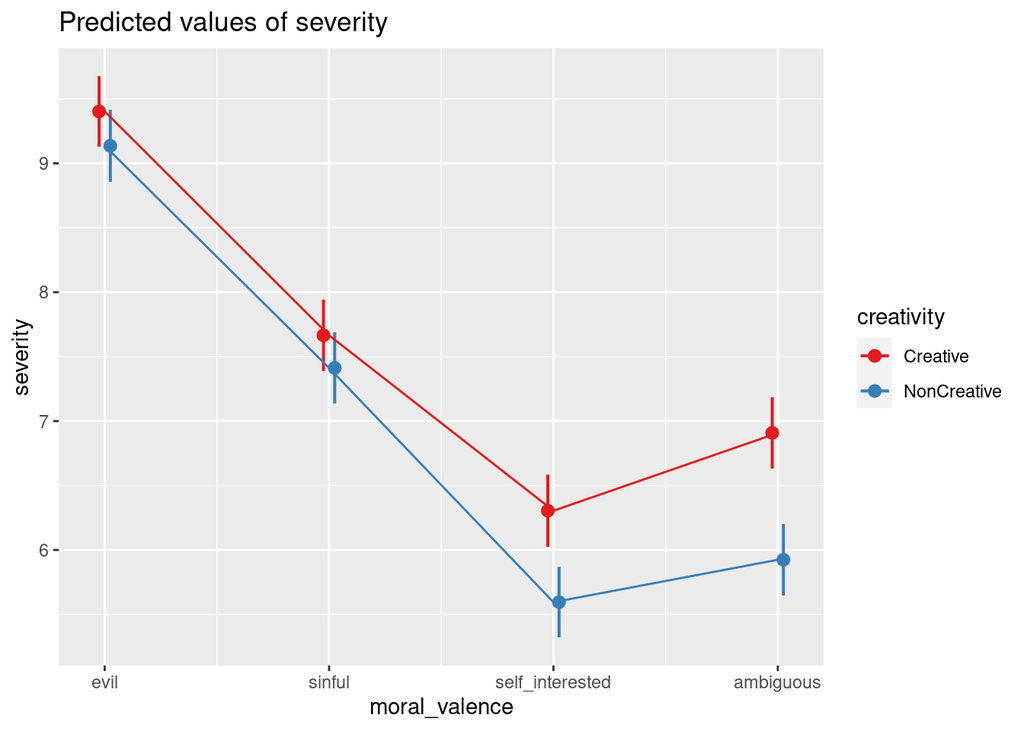

```r
library(sjPlot)
plot_model(severity4,
           type = "pred",
           terms = c("moral_valence", "creativity")) +
  geom_line()
```

# H4: Ratings of crime harmfulness will be predicted by sociodemographics, personality traits, moral foundations, creative self-efficacy, perceived legal knowledge, crime creativity (creative vs non-creative), moral valence (evil, sinful, self-interested, ambiguous), and the interaction between crime creativity and moral valence

```r
harm1<- lmer(harm ~ age + gender +education + ses + (1 | PID), data = df_long)

harm2<- lmer(harm ~ age + gender +education + ses  + psych_total + mach_total + narc_total + sadism_total  + mfq_individualizing + mfq_bind + (1 | PID), data = df_long)

harm3<- lmer(harm ~ age + gender +education + ses  + psych_total + mach_total + narc_total + sadism_total  + mfq_individualizing + mfq_bind + cse_total + legal + (1 | PID), data = df_long)
```

```
## boundary (singular) fit: see help('isSingular')
```

```r
harm4<- lmer(harm ~ age + gender +education + ses  + psych_total + mach_total + narc_total + sadism_total  + mfq_individualizing + mfq_bind + cse_total + legal + creativity + moral_valence + creativity*moral_valence + (1 | PID), data = df_long)

summary(harm1)
```

```
## Linear mixed model fit by REML. t-tests use Satterthwaite's method [
## lmerModLmerTest]
## Formula: harm ~ age + gender + education + ses + (1 | PID)
##    Data: df_long
##
## REML criterion at convergence: 12838.1
##
## Scaled residuals:
##      Min       1Q   Median       3Q      Max
## -2.54741 -0.72393  0.09441  0.89983  1.49755
##
## Random effects:
##  Groups   Name        Variance Std.Dev.
##  PID      (Intercept) 0.1439   0.3793
##  Residual             7.9678   2.8227
## Number of obs: 2600, groups:  PID, 651
##
## Fixed effects:
##               Estimate Std. Error         df t value             Pr(>|t|)
## (Intercept)   4.966153   0.282888 645.925080  17.555 < 0.0000000000000002 ***
## age           0.020842   0.008679 645.400349   2.401             0.016613 *
## gender2      -0.284692   0.115852 645.794752  -2.457             0.014258 *
## education     0.159895   0.060200 645.797839   2.656             0.008101 **
## ses           0.126666   0.035126 646.483920   3.606             0.000335 ***
## ---
## Signif. codes:  0 '***' 0.001 '**' 0.01 '*' 0.05 '.' 0.1 ' ' 1
##
## Correlation of Fixed Effects:
##           (Intr) age    gendr2 eductn
## age       -0.309
## gender2   -0.299  0.056
## education -0.116 -0.627 -0.024
## ses       -0.741 -0.031  0.057 -0.079
```

```r
summary(harm2)
```

```
## Linear mixed model fit by REML. t-tests use Satterthwaite's method [
## lmerModLmerTest]
## Formula: harm ~ age + gender + education + ses + psych_total + mach_total +
##     narc_total + sadism_total + mfq_individualizing + mfq_bind +      (1 | PID)
##    Data: df_long
##
## REML criterion at convergence: 12834.7
##
## Scaled residuals:
##      Min       1Q   Median       3Q      Max
## -2.71191 -0.73073  0.08802  0.88041  1.89988
##
## Random effects:
##  Groups   Name        Variance Std.Dev.
##  PID      (Intercept) 0.008664 0.09308
##  Residual             7.968155 2.82279
## Number of obs: 2600, groups:  PID, 651
##
## Fixed effects:
##                       Estimate Std. Error         df t value
## (Intercept)           3.917868   0.440470 639.076517   8.895
## age                   0.017003   0.008557 639.124206   1.987
## gender2              -0.367768   0.120938 639.656602  -3.041
## education             0.138344   0.061239 639.520307   2.259
## ses                   0.104591   0.035176 640.237445   2.973
## psych_total          -0.001009   0.014353 638.951161  -0.070
## mach_total           -0.030323   0.014589 639.503614  -2.079
## narc_total            0.045008   0.013958 639.785597   3.225
## sadism_total         -0.018537   0.013816 639.324959  -1.342
## mfq_individualizing   0.010949   0.007497 639.268148   1.460
## mfq_bind              0.019421   0.005065 639.851153   3.834
##                                 Pr(>|t|)
## (Intercept)         < 0.0000000000000002 ***
## age                             0.047361 *
## gender2                         0.002455 **
## education                       0.024214 *
## ses                             0.003056 **
## psych_total                     0.943996
## mach_total                      0.038055 *
## narc_total                      0.001326 **
```

[output cut: 14 more lines]

```
## narc_total  -0.111  0.062 -0.061 -0.028 -0.191 -0.236 -0.354
## sadism_totl -0.216  0.044  0.247  0.192 -0.031 -0.565 -0.197 -0.061
## mfq_ndvdlzn -0.371  0.100 -0.229 -0.105  0.079  0.186 -0.184  0.050 -0.002
## mfq_bind    -0.011 -0.155  0.136  0.085 -0.042 -0.142 -0.023 -0.128  0.013
##             mfq_nd
## age
## gender2
## education
## ses
## psych_total
## mach_total
## narc_total
## sadism_totl
## mfq_ndvdlzn
## mfq_bind    -0.551
```

```r
summary(harm3)
```

```
## Linear mixed model fit by REML. t-tests use Satterthwaite's method [
## lmerModLmerTest]
## Formula: harm ~ age + gender + education + ses + psych_total + mach_total +
##     narc_total + sadism_total + mfq_individualizing + mfq_bind +
##     cse_total + legal + (1 | PID)
##    Data: df_long
##
## REML criterion at convergence: 12783.7
##
## Scaled residuals:
##      Min       1Q   Median       3Q      Max
## -2.76023 -0.70386  0.07235  0.86478  1.91306
##
## Random effects:
##  Groups   Name        Variance Std.Dev.
##  PID      (Intercept) 0.00     0.000
##  Residual             7.91     2.813
## Number of obs: 2592, groups:  PID, 649
##
## Fixed effects:
##                        Estimate  Std. Error          df t value
## (Intercept)            3.617145    0.471813 2579.000000   7.666
## age                    0.016326    0.008644 2579.000000   1.889
## gender2               -0.358143    0.120586 2579.000000  -2.970
## education              0.103084    0.062075 2579.000000   1.661
## ses                    0.074890    0.035613 2579.000000   2.103
## psych_total           -0.010373    0.014407 2579.000000  -0.720
## mach_total            -0.022448    0.014713 2579.000000  -1.526
## narc_total             0.037232    0.014824 2579.000000   2.512
## sadism_total          -0.018149    0.013815 2579.000000  -1.314
## mfq_individualizing    0.013585    0.007711 2579.000000   1.762
## mfq_bind               0.016037    0.005124 2579.000000   3.130
## cse_total             -0.003837    0.012340 2579.000000  -0.311
## legal                  0.151814    0.030634 2579.000000   4.956
##                               Pr(>|t|)
## (Intercept)         0.0000000000000249 ***
## age                            0.05905 .
## gender2                        0.00301 **
## education                      0.09691 .
## ses                            0.03557 *
## psych_total                    0.47160
## mach_total                     0.12721
## narc_total                     0.01208 *
## sadism_total                   0.18908
## mfq_individualizing            0.07824 .
## mfq_bind                       0.00177 **
## cse_total                      0.75590
## legal               0.0000007671596471 ***
## ---
## Signif. codes:  0 '***' 0.001 '**' 0.01 '*' 0.05 '.' 0.1 ' ' 1
```

```
##
## Correlation matrix not shown by default, as p = 13 > 12.
## Use print(x, correlation=TRUE)  or
##     vcov(x)        if you need it
```

```
## optimizer (nloptwrap) convergence code: 0 (OK)
## boundary (singular) fit: see help('isSingular')
```

```r
summary(harm4)
```

```
## Linear mixed model fit by REML. t-tests use Satterthwaite's method [
## lmerModLmerTest]
## Formula: harm ~ age + gender + education + ses + psych_total + mach_total +
##     narc_total + sadism_total + mfq_individualizing + mfq_bind +
##     cse_total + legal + creativity + moral_valence + creativity *
##     moral_valence + (1 | PID)
##    Data: df_long
##
## REML criterion at convergence: 11475.1
##
## Scaled residuals:
##     Min      1Q  Median      3Q     Max
## -3.4865 -0.5904  0.1115  0.6325  2.7421
##
## Random effects:
##  Groups   Name        Variance Std.Dev.
##  PID      (Intercept) 0.8878   0.9422
##  Residual             4.0673   2.0167
## Number of obs: 2592, groups:  PID, 649
##
## Fixed effects:
##                                                       Estimate  Std. Error
## (Intercept)                                           6.247719    0.475572
## age                                                   0.017155    0.008485
## gender2                                              -0.369398    0.118376
## education                                             0.103157    0.060905
## ses                                                   0.074278    0.034956
## psych_total                                          -0.010940    0.014144
## mach_total                                           -0.022458    0.014445
## narc_total                                            0.035965    0.014543
## sadism_total                                         -0.016940    0.013568
## mfq_individualizing                                   0.013459    0.007574
## mfq_bind                                              0.016010    0.005027
## cse_total                                            -0.003350    0.012077
## legal                                                 0.154789    0.030068
## creativityNonCreative                                -0.094703    0.169225
## moral_valencesinful                                  -2.182208    0.164596
## moral_valenceself_interested                         -4.032239    0.166178
## moral_valenceambiguous                               -3.490873    0.164641
## creativityNonCreative:moral_valencesinful            -0.029048    0.244399
```

[output cut: 31 more lines]

```
## narc_total                                                      0.01366 *
## sadism_total                                                    0.21231
## mfq_individualizing                                             0.07605 .
## mfq_bind                                                        0.00152 **
## cse_total                                                       0.78156
## legal                                                       0.000000352 ***
## creativityNonCreative                                           0.57578
## moral_valencesinful                                < 0.0000000000000002 ***
## moral_valenceself_interested                       < 0.0000000000000002 ***
## moral_valenceambiguous                             < 0.0000000000000002 ***
## creativityNonCreative:moral_valencesinful                       0.90540
## creativityNonCreative:moral_valenceself_interested              0.04602 *
## creativityNonCreative:moral_valenceambiguous                    0.00037 ***
## ---
## Signif. codes:  0 '***' 0.001 '**' 0.01 '*' 0.05 '.' 0.1 ' ' 1
```

```
##
## Correlation matrix not shown by default, as p = 20 > 12.
## Use print(x, correlation=TRUE)  or
##     vcov(x)        if you need it
```

```r
standardize_parameters(harm1, method = "refit")
```

```
## # Standardization method: refit
##
## Parameter   | Std. Coef. |         95% CI
## -----------------------------------------
## (Intercept) |       0.06 | [ 0.00,  0.11]
## age         |       0.06 | [ 0.01,  0.11]
## gender2     |      -0.10 | [-0.18, -0.02]
## education   |       0.07 | [ 0.02,  0.12]
## ses         |       0.07 | [ 0.03,  0.11]
```

```r
r2(harm1)
```

```
## # R2 for Mixed Models
##
##   Conditional R2: 0.042
##      Marginal R2: 0.025
```

```r
standardize_parameters(harm2, method = "refit")
```

```
## # Standardization method: refit
##
## Parameter           | Std. Coef. |         95% CI
## -------------------------------------------------
## (Intercept)         |       0.07 | [ 0.01,  0.13]
## age                 |       0.05 | [ 0.00,  0.10]
## gender2             |      -0.13 | [-0.21, -0.05]
## education           |       0.06 | [ 0.01,  0.11]
## ses                 |       0.06 | [ 0.02,  0.10]
## psych_total         |  -2.11e-03 | [-0.06,  0.06]
## mach_total          |      -0.05 | [-0.10,  0.00]
## narc_total          |       0.08 | [ 0.03,  0.13]
## sadism_total        |      -0.04 | [-0.09,  0.02]
## mfq_individualizing |       0.04 | [-0.01,  0.08]
## mfq_bind            |       0.09 | [ 0.05,  0.14]
```

```r
r2(harm2)
```

```
## # R2 for Mixed Models
##
##   Conditional R2: 0.044
##      Marginal R2: 0.043
```

```r
standardize_parameters(harm3, method = "refit")
```

```
## boundary (singular) fit: see help('isSingular')
```

```
## # Standardization method: refit
##
## Parameter           | Std. Coef. |         95% CI
## -------------------------------------------------
## (Intercept)         |       0.07 | [ 0.01,  0.13]
## age                 |       0.05 | [ 0.00,  0.10]
## gender2             |      -0.12 | [-0.21, -0.04]
## education           |       0.04 | [-0.01,  0.10]
## ses                 |       0.04 | [ 0.00,  0.08]
## psych_total         |      -0.02 | [-0.08,  0.04]
## mach_total          |      -0.04 | [-0.08,  0.01]
## narc_total          |       0.07 | [ 0.01,  0.12]
## sadism_total        |      -0.04 | [-0.09,  0.02]
## mfq_individualizing |       0.04 | [ 0.00,  0.09]
## mfq_bind            |       0.08 | [ 0.03,  0.13]
## cse_total           |  -6.67e-03 | [-0.05,  0.04]
## legal               |       0.11 | [ 0.07,  0.15]
```

```r
r2(harm3)
```

```
## Random effect variances not available. Returned R2 does not account for random effects.
```

```
## # R2 for Mixed Models
##
##   Conditional R2: NA
##      Marginal R2: 0.052
```

```r
VarCorr(harm3)
```

```
##  Groups   Name        Std.Dev.
##  PID      (Intercept) 0.0000
##  Residual             2.8125
```

```r
standardize_parameters(harm4, method = "refit")
```

```
## # Standardization method: refit
##
## Parameter                                          | Std. Coef. |         95% CI
## --------------------------------------------------------------------------------
## (Intercept)                                        |       0.99 | [ 0.90,  1.08]
## age                                                |       0.05 | [ 0.00,  0.10]
## gender2                                            |      -0.13 | [-0.21, -0.05]
## education                                          |       0.04 | [-0.01,  0.10]
## ses                                                |       0.04 | [ 0.00,  0.08]
## psych_total                                        |      -0.02 | [-0.08,  0.03]
## mach_total                                         |      -0.04 | [-0.08,  0.01]
## narc_total                                         |       0.06 | [ 0.01,  0.11]
## sadism_total                                       |      -0.03 | [-0.09,  0.02]
## mfq_individualizing                                |       0.04 | [ 0.00,  0.09]
## mfq_bind                                           |       0.08 | [ 0.03,  0.12]
## cse_total                                          |  -5.83e-03 | [-0.05,  0.04]
## legal                                              |       0.11 | [ 0.07,  0.15]
## creativityNonCreative                              |      -0.03 | [-0.15,  0.08]
## moral_valencesinful                                |      -0.76 | [-0.87, -0.65]
## moral_valenceself_interested                       |      -1.40 | [-1.51, -1.29]
## moral_valenceambiguous                             |      -1.21 | [-1.32, -1.10]
## creativityNonCreative:moral_valencesinful          |      -0.01 | [-0.18,  0.16]
## creativityNonCreative:moral_valenceself_interested |      -0.17 | [-0.34,  0.00]
## creativityNonCreative:moral_valenceambiguous       |      -0.30 | [-0.47, -0.14]
```

```r
r2(harm4)
```

```
## # R2 for Mixed Models
##
##   Conditional R2: 0.513
##      Marginal R2: 0.406
```

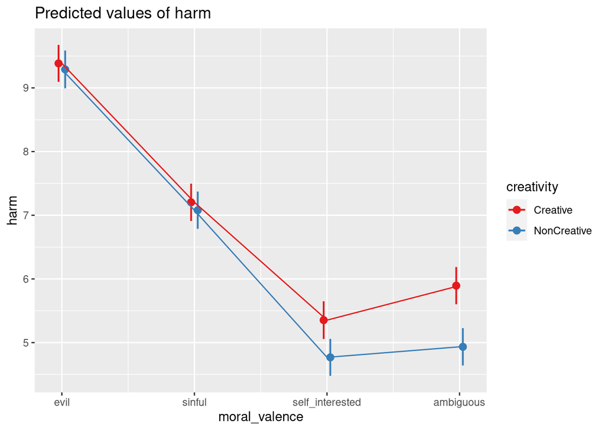

```r
plot_model(harm4,
           type = "pred",
           terms = c("moral_valence", "creativity")) +
  geom_line()
```

# H5: Sentencing recommendations will be predicted by sociodemographics, personality traits, moral foundations, creative self-efficacy, perceived legal knowledge, crime creativity (creative vs non-creative), moral valence (evil, sinful, self-interested, ambiguous), and the interaction between crime creativity and moral valence

```r
sentence1<- lmer(sentence ~ gender + (1 | PID), data = df_long)

sentence2<- lmer(sentence ~ gender + psych_total + mach_total + narc_total + sadism_total  + mfq_individualizing + mfq_bind + (1 | PID), data = df_long)

sentence3<- lmer(sentence ~ gender + psych_total + mach_total + narc_total + sadism_total  + mfq_individualizing + mfq_bind + cse_total + legal + (1 | PID), data = df_long)

sentence4<- lmer(sentence ~ gender + psych_total + mach_total + narc_total + sadism_total  + mfq_individualizing + mfq_bind + cse_total + legal + creativity + moral_valence + creativity*moral_valence + (1 | PID), data = df_long)

summary(sentence1)
```

```
## Linear mixed model fit by REML. t-tests use Satterthwaite's method [
## lmerModLmerTest]
## Formula: sentence ~ gender + (1 | PID)
##    Data: df_long
##
## REML criterion at convergence: 12842.2
##
## Scaled residuals:
##     Min      1Q  Median      3Q     Max
## -2.3069 -0.6668 -0.0212  0.7647  1.7681
##
## Random effects:
##  Groups   Name        Variance Std.Dev.
##  PID      (Intercept) 0.6933   0.8327
##  Residual             7.4446   2.7285
## Number of obs: 2607, groups:  PID, 652
##
## Fixed effects:
##              Estimate Std. Error        df t value             Pr(>|t|)
## (Intercept)   6.21785    0.09437 650.64496  65.885 < 0.0000000000000002 ***
## gender2      -0.41785    0.12612 650.33108  -3.313             0.000973 ***
## ---
## Signif. codes:  0 '***' 0.001 '**' 0.01 '*' 0.05 '.' 0.1 ' ' 1
##
## Correlation of Fixed Effects:
##         (Intr)
## gender2 -0.748
```

```r
summary(sentence2)
```

```
## Linear mixed model fit by REML. t-tests use Satterthwaite's method [
## lmerModLmerTest]
## Formula:
## sentence ~ gender + psych_total + mach_total + narc_total + sadism_total +
##     mfq_individualizing + mfq_bind + (1 | PID)
##    Data: df_long
##
## REML criterion at convergence: 12843.1
##
## Scaled residuals:
##      Min       1Q   Median       3Q      Max
## -2.35525 -0.66191 -0.00768  0.79048  1.94939
##
## Random effects:
##  Groups   Name        Variance Std.Dev.
##  PID      (Intercept) 0.5517   0.7428
##  Residual             7.4445   2.7285
## Number of obs: 2607, groups:  PID, 652
##
## Fixed effects:
##                       Estimate Std. Error         df t value
## (Intercept)           5.190643   0.419759 644.153288  12.366
## gender2              -0.507041   0.132573 644.128347  -3.825
## psych_total          -0.058048   0.014553 644.085885  -3.989
## mach_total            0.039676   0.015883 643.953142   2.498
## narc_total           -0.007113   0.014992 644.037589  -0.474
## sadism_total          0.005464   0.014596 644.000671   0.374
## mfq_individualizing   0.015116   0.008150 644.255697   1.855
## mfq_bind              0.008369   0.005478 643.963122   1.528
##                                 Pr(>|t|)
## (Intercept)         < 0.0000000000000002 ***
## gender2                         0.000144 ***
## psych_total                     0.000074 ***
## mach_total                      0.012738 *
## narc_total                      0.635358
## sadism_total                    0.708254
## mfq_individualizing             0.064097 .
## mfq_bind                        0.127054
## ---
## Signif. codes:  0 '***' 0.001 '**' 0.01 '*' 0.05 '.' 0.1 ' ' 1
##
## Correlation of Fixed Effects:
##             (Intr) gendr2 psych_ mch_tt nrc_tt sdsm_t mfq_nd
## gender2     -0.217
## psych_total  0.032 -0.080
## mach_total  -0.326  0.073 -0.076
## narc_total  -0.213 -0.062 -0.260 -0.346
## sadism_totl -0.205  0.246 -0.522 -0.179 -0.071
## mfq_ndvdlzn -0.383 -0.234  0.190 -0.190  0.059  0.010
## mfq_bind    -0.068  0.143 -0.170 -0.030 -0.133  0.024 -0.546
```

```r
summary(sentence3)
```

```
## Linear mixed model fit by REML. t-tests use Satterthwaite's method [
## lmerModLmerTest]
## Formula:
## sentence ~ gender + psych_total + mach_total + narc_total + sadism_total +
##     mfq_individualizing + mfq_bind + cse_total + legal + (1 |      PID)
##    Data: df_long
##
## REML criterion at convergence: 12809.7
##
## Scaled residuals:
##      Min       1Q   Median       3Q      Max
## -2.39143 -0.65596  0.01504  0.79410  1.92563
##
## Random effects:
##  Groups   Name        Variance Std.Dev.
##  PID      (Intercept) 0.5393   0.7344
##  Residual             7.4428   2.7281
## Number of obs: 2599, groups:  PID, 650
##
## Fixed effects:
##                       Estimate Std. Error         df t value
## (Intercept)           4.916375   0.475678 640.013105  10.336
## gender2              -0.504669   0.132605 640.109595  -3.806
## psych_total          -0.060675   0.014812 640.079038  -4.096
## mach_total            0.035415   0.016095 639.955536   2.200
## narc_total           -0.018166   0.016079 639.973829  -1.130
## sadism_total          0.008347   0.014730 640.023089   0.567
## mfq_individualizing   0.014015   0.008435 640.345223   1.662
## mfq_bind              0.009463   0.005554 639.957990   1.704
## cse_total             0.017731   0.013335 640.067767   1.330
## legal                 0.028082   0.032903 639.944859   0.853
##                                 Pr(>|t|)
## (Intercept)         < 0.0000000000000002 ***
## gender2                         0.000155 ***
## psych_total                    0.0000474 ***
## mach_total                      0.028135 *
## narc_total                      0.258986
## sadism_total                    0.571137
## mfq_individualizing             0.097068 .
## mfq_bind                        0.088883 .
## cse_total                       0.184085
## legal                           0.393728
## ---
## Signif. codes:  0 '***' 0.001 '**' 0.01 '*' 0.05 '.' 0.1 ' ' 1
##
## Correlation of Fixed Effects:
##             (Intr) gendr2 psych_ mch_tt nrc_tt sdsm_t mfq_nd mfq_bn cs_ttl
## gender2     -0.203
## psych_total  0.072 -0.085
## mach_total  -0.309  0.079 -0.089
## narc_total  -0.031 -0.076 -0.202 -0.326
## sadism_totl -0.249  0.247 -0.515 -0.167 -0.114
## mfq_ndvdlzn -0.256 -0.237  0.170 -0.189  0.121 -0.019
## mfq_bind    -0.058  0.134 -0.138 -0.054 -0.125  0.027 -0.533
## cse_total   -0.391  0.028  0.003  0.002 -0.303  0.142 -0.229  0.079
## legal       -0.180  0.035 -0.198  0.078 -0.161  0.034  0.058 -0.133 -0.082
```

```r
summary(sentence4)
```

```
## Linear mixed model fit by REML. t-tests use Satterthwaite's method [
## lmerModLmerTest]
## Formula:
## sentence ~ gender + psych_total + mach_total + narc_total + sadism_total +
##     mfq_individualizing + mfq_bind + cse_total + legal + creativity +
##     moral_valence + creativity * moral_valence + (1 | PID)
##    Data: df_long
##
## REML criterion at convergence: 11710.8
##
## Scaled residuals:
##     Min      1Q  Median      3Q     Max
## -3.6060 -0.5145  0.1277  0.6256  2.9422
##
## Random effects:
##  Groups   Name        Variance Std.Dev.
##  PID      (Intercept) 1.338    1.157
##  Residual             4.222    2.055
## Number of obs: 2599, groups:  PID, 650
##
## Fixed effects:
##                                                       Estimate  Std. Error
## (Intercept)                                           7.401657    0.488271
## gender2                                              -0.516423    0.132494
## psych_total                                          -0.060605    0.014797
## mach_total                                            0.035200    0.016081
## narc_total                                           -0.018850    0.016061
## sadism_total                                          0.008970    0.014719
## mfq_individualizing                                   0.014541    0.008431
## mfq_bind                                              0.009264    0.005548
## cse_total                                             0.016976    0.013321
## legal                                                 0.031130    0.032875
## creativityNonCreative                                -0.041919    0.174806
## moral_valencesinful                                  -2.354976    0.169256
## moral_valenceself_interested                         -3.625404    0.170718
## moral_valenceambiguous                               -3.304053    0.169182
## creativityNonCreative:moral_valencesinful             0.081172    0.253444
## creativityNonCreative:moral_valenceself_interested   -0.635485    0.254629
## creativityNonCreative:moral_valenceambiguous         -0.544730    0.251331
##                                                             df t value
```

[output cut: 22 more lines]

```
## narc_total                                                     0.240992
## sadism_total                                                   0.542461
## mfq_individualizing                                            0.085045 .
## mfq_bind                                                       0.095427 .
## cse_total                                                      0.202979
## legal                                                          0.344035
## creativityNonCreative                                          0.810502
## moral_valencesinful                                < 0.0000000000000002 ***
## moral_valenceself_interested                       < 0.0000000000000002 ***
## moral_valenceambiguous                             < 0.0000000000000002 ***
## creativityNonCreative:moral_valencesinful                      0.748785
## creativityNonCreative:moral_valenceself_interested             0.012633 *
## creativityNonCreative:moral_valenceambiguous                   0.030300 *
## ---
## Signif. codes:  0 '***' 0.001 '**' 0.01 '*' 0.05 '.' 0.1 ' ' 1
```

```
##
## Correlation matrix not shown by default, as p = 17 > 12.
## Use print(x, correlation=TRUE)  or
##     vcov(x)        if you need it
```

```r
standardize_parameters(sentence1, method = "refit")
```

```
## # Standardization method: refit
##
## Parameter   | Std. Coef. |         95% CI
## -----------------------------------------
## (Intercept) |       0.08 | [ 0.02,  0.15]
## gender2     |      -0.15 | [-0.23, -0.06]
```

```r
r2(sentence1)
```

```
## # R2 for Mixed Models
##
##   Conditional R2: 0.090
##      Marginal R2: 0.005
```

```r
standardize_parameters(sentence2, method = "refit")
```

```
## # Standardization method: refit
##
## Parameter           | Std. Coef. |         95% CI
## -------------------------------------------------
## (Intercept)         |       0.10 | [ 0.03,  0.17]
## gender2             |      -0.18 | [-0.27, -0.09]
## psych_total         |      -0.12 | [-0.18, -0.06]
## mach_total          |       0.07 | [ 0.01,  0.12]
## narc_total          |      -0.01 | [-0.07,  0.04]
## sadism_total        |       0.01 | [-0.05,  0.07]
## mfq_individualizing |       0.05 | [ 0.00,  0.10]
## mfq_bind            |       0.04 | [-0.01,  0.09]
```

```r
r2(sentence2)
```

```
## # R2 for Mixed Models
##
##   Conditional R2: 0.092
##      Marginal R2: 0.025
```

```r
standardize_parameters(sentence3, method = "refit")
```

```
## # Standardization method: refit
##
## Parameter           | Std. Coef. |         95% CI
## -------------------------------------------------
## (Intercept)         |       0.10 | [ 0.03,  0.16]
## gender2             |      -0.18 | [-0.27, -0.09]
## psych_total         |      -0.13 | [-0.19, -0.07]
## mach_total          |       0.06 | [ 0.01,  0.11]
## narc_total          |      -0.03 | [-0.09,  0.02]
## sadism_total        |       0.02 | [-0.04,  0.08]
## mfq_individualizing |       0.05 | [-0.01,  0.10]
## mfq_bind            |       0.05 | [-0.01,  0.10]
## cse_total           |       0.03 | [-0.01,  0.08]
## legal               |       0.02 | [-0.03,  0.07]
```

```r
r2(sentence3)
```

```
## # R2 for Mixed Models
##
##   Conditional R2: 0.093
##      Marginal R2: 0.027
```

```r
standardize_parameters(sentence4, method = "refit")
```

```
## # Standardization method: refit
##
## Parameter                                          | Std. Coef. |         95% CI
## --------------------------------------------------------------------------------
## (Intercept)                                        |       0.97 | [ 0.87,  1.07]
## gender2                                            |      -0.18 | [-0.27, -0.09]
## psych_total                                        |      -0.13 | [-0.19, -0.07]
## mach_total                                         |       0.06 | [ 0.01,  0.11]
## narc_total                                         |      -0.03 | [-0.09,  0.02]
## sadism_total                                       |       0.02 | [-0.04,  0.08]
## mfq_individualizing                                |       0.05 | [-0.01,  0.10]
## mfq_bind                                           |       0.05 | [-0.01,  0.10]
## cse_total                                          |       0.03 | [-0.02,  0.08]
## legal                                              |       0.02 | [-0.02,  0.07]
## creativityNonCreative                              |      -0.01 | [-0.13,  0.11]
## moral_valencesinful                                |      -0.82 | [-0.94, -0.71]
## moral_valenceself_interested                       |      -1.27 | [-1.39, -1.15]
## moral_valenceambiguous                             |      -1.16 | [-1.27, -1.04]
## creativityNonCreative:moral_valencesinful          |       0.03 | [-0.15,  0.20]
## creativityNonCreative:moral_valenceself_interested |      -0.22 | [-0.40, -0.05]
## creativityNonCreative:moral_valenceambiguous       |      -0.19 | [-0.36, -0.02]
```

```r
r2(sentence4)
```

```
## # R2 for Mixed Models
##
##   Conditional R2: 0.486
##      Marginal R2: 0.323
```

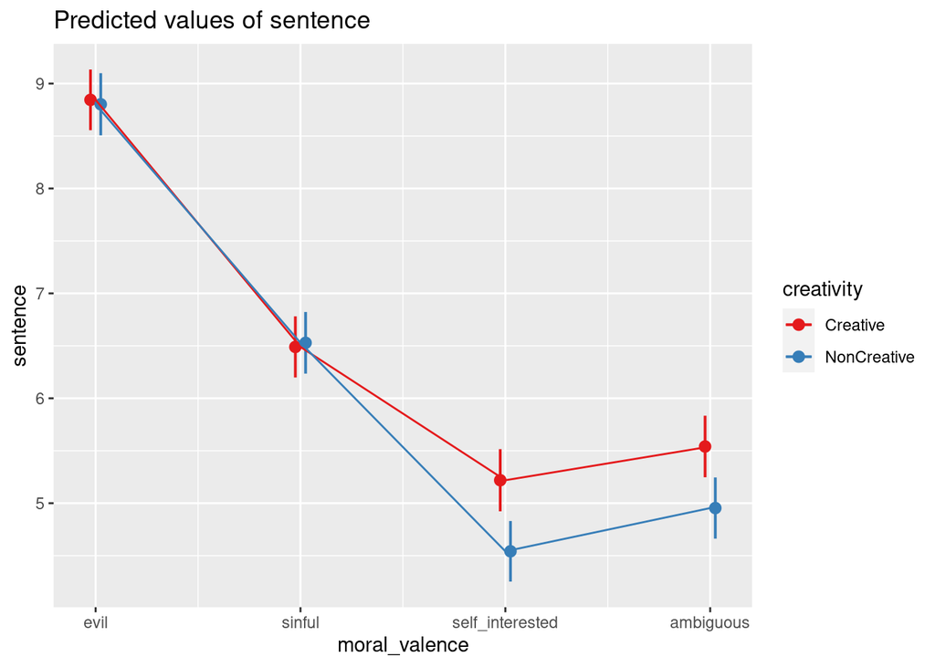

```r
plot_model(sentence4,
           type = "pred",
           terms = c("moral_valence", "creativity")) +
  geom_line()
```

```r
# ordinal models for robustness check
clmm_model1 <- clmm(sentence_ord ~ gender + (1 | PID), data = df_long)
clmm_model2 <- clmm(sentence_ord ~ gender + psych_total + mach_total + narc_total + sadism_total + mfq_individualizing + mfq_bind + (1 | PID), data = df_long)

clmm_model3 <- clmm(sentence_ord ~ gender + psych_total + mach_total + narc_total + sadism_total + mfq_individualizing + mfq_bind + cse_total + legal + (1 | PID), data = df_long)

clmm_model4 <- clmm(sentence_ord ~ gender + psych_total + mach_total + narc_total + sadism_total + mfq_individualizing + mfq_bind + cse_total + legal + creativity * moral_valence + (1 | PID), data = df_long)

summary(clmm_model1)
```

```
## Cumulative Link Mixed Model fitted with the Laplace approximation
##
## formula: sentence_ord ~ gender + (1 | PID)
## data:    df_long
##
##  link  threshold nobs logLik   AIC      niter      max.grad cond.H
##  logit flexible  2607 -6001.54 12027.09 1708(4468) 6.62e-03 2.1e+02
##
## Random effects:
##  Groups Name        Variance Std.Dev.
##  PID    (Intercept) 0.2464   0.4964
## Number of groups:  PID 652
##
## Coefficients:
##         Estimate Std. Error z value Pr(>|z|)
## gender2 -0.27076    0.07974  -3.396 0.000685 ***
## ---
## Signif. codes:  0 '***' 0.001 '**' 0.01 '*' 0.05 '.' 0.1 ' ' 1
##
## Threshold coefficients:
##      Estimate Std. Error z value
## 0|1  -4.04582    0.14549 -27.809
## 1|2  -2.55898    0.08951 -28.589
## 2|3  -2.02988    0.07915 -25.647
## 3|4  -1.52138    0.07176 -21.200
## 4|5  -1.05375    0.06691 -15.748
## 5|6  -0.41559    0.06338  -6.557
## 6|7   0.10932    0.06305   1.734
## 7|8   0.49052    0.06422   7.638
## 8|9   1.13257    0.06879  16.464
## 9|10  1.69514    0.07555  22.438
```

```r
summary(clmm_model2)
```

```
## Cumulative Link Mixed Model fitted with the Laplace approximation
##
## formula: sentence_ord ~ gender + psych_total + mach_total + narc_total +
##     sadism_total + mfq_individualizing + mfq_bind + (1 | PID)
## data:    df_long
##
##  link  threshold nobs logLik   AIC      niter      max.grad cond.H
##  logit flexible  2607 -5978.58 11993.16 2862(7420) 1.28e-02 3.2e+06
##
## Random effects:
##  Groups Name        Variance Std.Dev.
##  PID    (Intercept) 0.1722   0.4149
## Number of groups:  PID 652
##
## Coefficients:
##                      Estimate Std. Error z value  Pr(>|z|)
## gender2             -0.328854   0.082875  -3.968 0.0000724 ***
## psych_total         -0.037202   0.009276  -4.011 0.0000605 ***
## mach_total           0.025333   0.010061   2.518    0.0118 *
## narc_total          -0.005762   0.009541  -0.604    0.5459
## sadism_total         0.004071   0.009184   0.443    0.6576
## mfq_individualizing  0.009945   0.005169   1.924    0.0543 .
## mfq_bind             0.005659   0.003488   1.622    0.1047
## ---
## Signif. codes:  0 '***' 0.001 '**' 0.01 '*' 0.05 '.' 0.1 ' ' 1
##
## Threshold coefficients:
##      Estimate Std. Error z value
## 0|1   -3.3763     0.2911 -11.599
## 1|2   -1.8919     0.2686  -7.044
## 2|3   -1.3653     0.2659  -5.134
## 3|4   -0.8587     0.2646  -3.245
## 4|5   -0.3917     0.2641  -1.483
## 5|6    0.2467     0.2641   0.934
## 6|7    0.7717     0.2646   2.917
## 7|8    1.1531     0.2653   4.346
## 8|9    1.7951     0.2670   6.722
## 9|10   2.3573     0.2693   8.754
```

```r
summary(clmm_model3)
```

```
## Cumulative Link Mixed Model fitted with the Laplace approximation
##
## formula: sentence_ord ~ gender + psych_total + mach_total + narc_total +
##     sadism_total + mfq_individualizing + mfq_bind + cse_total +
##     legal + (1 | PID)
## data:    df_long
##
##  link  threshold nobs logLik   AIC      niter      max.grad cond.H
##  logit flexible  2599 -5957.35 11954.71 3446(9301) 9.04e+00 4.4e+06
##
## Random effects:
##  Groups Name        Variance Std.Dev.
##  PID    (Intercept) 0.1867   0.4321
## Number of groups:  PID 650
##
## Coefficients:
##                      Estimate Std. Error z value  Pr(>|z|)
## gender2             -0.324772   0.083808  -3.875  0.000107 ***
## psych_total         -0.038582   0.009539  -4.045 0.0000524 ***
## mach_total           0.022870   0.010285   2.224  0.026179 *
## narc_total          -0.012305   0.010311  -1.193  0.232716
## sadism_total         0.005763   0.009351   0.616  0.537708
## mfq_individualizing  0.009098   0.005387   1.689  0.091258 .
## mfq_bind             0.006306   0.003570   1.766  0.077329 .
## cse_total            0.012066   0.008494   1.421  0.155460
## legal                0.014498   0.020741   0.699  0.484560
## ---
## Signif. codes:  0 '***' 0.001 '**' 0.01 '*' 0.05 '.' 0.1 ' ' 1
##
## Threshold coefficients:
##      Estimate Std. Error z value
## 0|1   -3.1912     0.3242  -9.842
## 1|2   -1.7155     0.3047  -5.630
## 2|3   -1.1857     0.3025  -3.920
## 3|4   -0.6818     0.3015  -2.261
## 4|5   -0.2122     0.3012  -0.705
## 5|6    0.4320     0.3015   1.433
## 6|7    0.9580     0.3021   3.171
## 7|8    1.3399     0.3029   4.423
## 8|9    1.9857     0.3047   6.517
## 9|10   2.5546     0.3068   8.325
## (8 observations deleted due to missingness)
```

```r
summary(clmm_model4)
```

```
## Cumulative Link Mixed Model fitted with the Laplace approximation
##
## formula: sentence_ord ~ gender + psych_total + mach_total + narc_total +
##     sadism_total + mfq_individualizing + mfq_bind + cse_total +
##     legal + creativity * moral_valence + (1 | PID)
## data:    df_long
##
##  link  threshold nobs logLik   AIC      niter       max.grad cond.H
##  logit flexible  2599 -5307.00 10668.01 5283(19324) 2.00e-01 4.9e+06
##
## Random effects:
##  Groups Name        Variance Std.Dev.
##  PID    (Intercept) 1.029    1.014
## Number of groups:  PID 650
##
## Coefficients:
##                                                     Estimate Std. Error z value
## gender2                                            -0.518188   0.117453  -4.412
## psych_total                                        -0.051477   0.013219  -3.894
## mach_total                                          0.027478   0.014234   1.930
## narc_total                                         -0.014328   0.014227  -1.007
## sadism_total                                        0.006633   0.012975   0.511
## mfq_individualizing                                 0.013575   0.007450   1.822
## mfq_bind                                            0.008712   0.004888   1.782
## cse_total                                           0.016926   0.011758   1.440
## legal                                               0.016554   0.028883   0.573
## creativityNonCreative                               0.028592   0.173397   0.165
## moral_valencesinful                                -2.665090   0.165977 -16.057
## moral_valenceself_interested                       -3.765878   0.173462 -21.710
## moral_valenceambiguous                             -3.438185   0.170870 -20.122
## creativityNonCreative:moral_valencesinful          -0.034041   0.234439  -0.145
## creativityNonCreative:moral_valenceself_interested -0.549047   0.233688  -2.349
## creativityNonCreative:moral_valenceambiguous       -0.510503   0.233348  -2.188
##                                                                Pr(>|z|)
## gender2                                                       0.0000102 ***
## psych_total                                                   0.0000986 ***
## mach_total                                                       0.0535 .
## narc_total                                                       0.3139
## sadism_total                                                     0.6092
## mfq_individualizing                                              0.0684 .
```

[output cut: 11 more lines]

```
## Signif. codes:  0 '***' 0.001 '**' 0.01 '*' 0.05 '.' 0.1 ' ' 1
##
## Threshold coefficients:
##      Estimate Std. Error z value
## 0|1   -6.7240     0.4657 -14.440
## 1|2   -5.0901     0.4497 -11.318
## 2|3   -4.4657     0.4472  -9.986
## 3|4   -3.8318     0.4452  -8.606
## 4|5   -3.2208     0.4438  -7.258
## 5|6   -2.3264     0.4420  -5.263
## 6|7   -1.5459     0.4408  -3.507
## 7|8   -0.9594     0.4402  -2.180
## 8|9    0.1287     0.4389   0.293
## 9|10   1.1335     0.4385   2.585
## (8 observations deleted due to missingness)
```

# H6: Rehabilitation recommendations will be predicted by sociodemographics, personality traits, moral foundations, creative self-efficacy, perceived legal knowledge, crime creativity (creative vs non-creative), moral valence (evil, sinful, self-interested, ambiguous), and the interaction between crime creativity and moral valence

```r
rehab1<- lmer(rehab ~ age +education + ses + (1 | PID), data = df_long)

rehab2<- lmer(rehab ~ age +education + ses + psych_total + mach_total + narc_total + sadism_total  + mfq_individualizing + mfq_bind + (1 | PID), data = df_long)

rehab3<- lmer(rehab ~ age + education + ses + psych_total + mach_total + narc_total + sadism_total  + mfq_individualizing + mfq_bind + cse_total + legal + (1 | PID), data = df_long)

rehab4<- lmer(rehab ~ age + education + ses + psych_total + mach_total + narc_total + sadism_total  + mfq_individualizing + mfq_bind + cse_total + legal + creativity + moral_valence + creativity*moral_valence + (1 | PID), data = df_long)

summary(rehab1)
```

```
## Linear mixed model fit by REML. t-tests use Satterthwaite's method [
## lmerModLmerTest]
## Formula: rehab ~ age + education + ses + (1 | PID)
##    Data: df_long
##
## REML criterion at convergence: 13025.8
##
## Scaled residuals:
##      Min       1Q   Median       3Q      Max
## -2.05579 -0.83428 -0.06616  0.76798  2.34538
##
## Random effects:
##  Groups   Name        Variance Std.Dev.
##  PID      (Intercept) 1.331    1.154
##  Residual             7.613    2.759
## Number of obs: 2602, groups:  PID, 651
##
## Fixed effects:
##               Estimate Std. Error         df t value             Pr(>|t|)
## (Intercept)   2.869747   0.332034 647.509257   8.643 < 0.0000000000000002 ***
## age           0.003566   0.010659 646.176597   0.335              0.73806
## education     0.247850   0.074018 646.338362   3.349              0.00086 ***
## ses           0.090931   0.043139 647.568915   2.108              0.03543 *
## ---
## Signif. codes:  0 '***' 0.001 '**' 0.01 '*' 0.05 '.' 0.1 ' ' 1
##
## Correlation of Fixed Effects:
##           (Intr) age    eductn
## age       -0.307
## education -0.129 -0.626
## ses       -0.760 -0.034 -0.078
```

```r
summary(rehab2)
```

```
## Linear mixed model fit by REML. t-tests use Satterthwaite's method [
## lmerModLmerTest]
## Formula:
## rehab ~ age + education + ses + psych_total + mach_total + narc_total +
##     sadism_total + mfq_individualizing + mfq_bind + (1 | PID)
##    Data: df_long
##
## REML criterion at convergence: 13051.5
##
## Scaled residuals:
##      Min       1Q   Median       3Q      Max
## -2.12390 -0.82437 -0.07199  0.76452  2.33800
##
## Random effects:
##  Groups   Name        Variance Std.Dev.
##  PID      (Intercept) 1.279    1.131
##  Residual             7.613    2.759
## Number of obs: 2602, groups:  PID, 651
##
## Fixed effects:
##                        Estimate  Std. Error          df t value  Pr(>|t|)
## (Intercept)           2.3563871   0.5436163 640.7399412   4.335 0.0000169 ***
## age                   0.0002428   0.0107859 640.1557707   0.023   0.98205
## education             0.2114259   0.0771816 640.2846123   2.739   0.00633 **
## ses                   0.0786645   0.0443447 641.4725172   1.774   0.07655 .
## psych_total           0.0243351   0.0180241 640.4082768   1.350   0.17745
## mach_total           -0.0310709   0.0183480 640.4137299  -1.693   0.09086 .
## narc_total            0.0186010   0.0175579 640.2466647   1.059   0.28982
## sadism_total         -0.0203362   0.0168790 640.4957787  -1.205   0.22872
## mfq_individualizing   0.0093073   0.0092002 640.5395587   1.012   0.31209
## mfq_bind              0.0134410   0.0063235 640.2200582   2.126   0.03392 *
## ---
## Signif. codes:  0 '***' 0.001 '**' 0.01 '*' 0.05 '.' 0.1 ' ' 1
##
## Correlation of Fixed Effects:
##             (Intr) age    eductn ses    psych_ mch_tt nrc_tt sdsm_t mfq_nd
## age         -0.173
## education   -0.024 -0.574
## ses         -0.426 -0.022 -0.057
## psych_total  0.098 -0.059 -0.272 -0.009
## mach_total  -0.277 -0.062 -0.038  0.073 -0.029
## narc_total  -0.126  0.064 -0.026 -0.191 -0.243 -0.351
## sadism_totl -0.175  0.040  0.194 -0.035 -0.562 -0.220 -0.048
## mfq_ndvdlzn -0.439  0.108 -0.103  0.085  0.171 -0.173  0.036  0.058
## mfq_bind     0.017 -0.160  0.084 -0.044 -0.132 -0.033 -0.120 -0.022 -0.539
```

```r
summary(rehab3)
```

```
## Linear mixed model fit by REML. t-tests use Satterthwaite's method [
## lmerModLmerTest]
## Formula:
## rehab ~ age + education + ses + psych_total + mach_total + narc_total +
##     sadism_total + mfq_individualizing + mfq_bind + cse_total +
##     legal + (1 | PID)
##    Data: df_long
##
## REML criterion at convergence: 13019.1
##
## Scaled residuals:
##      Min       1Q   Median       3Q      Max
## -2.14418 -0.82543 -0.07068  0.76089  2.34335
##
## Random effects:
##  Groups   Name        Variance Std.Dev.
##  PID      (Intercept) 1.265    1.125
##  Residual             7.617    2.760
## Number of obs: 2594, groups:  PID, 649
##
## Fixed effects:
##                       Estimate Std. Error         df t value Pr(>|t|)
## (Intercept)           1.971839   0.585060 637.473229   3.370 0.000796 ***
## age                  -0.002250   0.010933 635.985525  -0.206 0.836986
## education             0.191656   0.078526 636.082574   2.441 0.014932 *
## ses                   0.071662   0.045076 636.970900   1.590 0.112379
## psych_total           0.022176   0.018156 636.224797   1.221 0.222390
## mach_total           -0.031419   0.018568 636.291669  -1.692 0.091117 .
## narc_total            0.008234   0.018695 636.048040   0.440 0.659772
## sadism_total         -0.018413   0.016940 636.204474  -1.087 0.277474
## mfq_individualizing   0.009403   0.009491 636.667110   0.991 0.322177
## mfq_bind              0.013928   0.006428 636.062929   2.167 0.030629 *
## cse_total             0.017173   0.015514 638.035766   1.107 0.268725
## legal                 0.056327   0.038748 636.219736   1.454 0.146536
## ---
## Signif. codes:  0 '***' 0.001 '**' 0.01 '*' 0.05 '.' 0.1 ' ' 1
##
## Correlation of Fixed Effects:
##             (Intr) age    eductn ses    psych_ mch_tt nrc_tt sdsm_t mfq_nd
## age         -0.151
## education    0.028 -0.570
## ses         -0.355 -0.031 -0.028
## psych_total  0.088 -0.060 -0.253  0.010
## mach_total  -0.271 -0.050 -0.051  0.042 -0.040
## narc_total  -0.003  0.044  0.036 -0.149 -0.221 -0.330
## sadism_totl -0.198  0.039  0.178 -0.040 -0.549 -0.212 -0.071
## mfq_ndvdlzn -0.333  0.080 -0.071  0.088  0.148 -0.172  0.093  0.034
## mfq_bind     0.002 -0.171  0.093 -0.014 -0.108 -0.057 -0.117 -0.015 -0.523
## cse_total   -0.337  0.020 -0.123 -0.036  0.049  0.010 -0.296  0.100 -0.223
## legal       -0.095  0.019 -0.132 -0.150 -0.128  0.080 -0.140 -0.007  0.058
##             mfq_bn cs_ttl
## age
## education
## ses
## psych_total
## mach_total
## narc_total
## sadism_totl
## mfq_ndvdlzn
## mfq_bind
## cse_total    0.075
## legal       -0.131 -0.051
```

```r
summary(rehab4)
```

```
## Linear mixed model fit by REML. t-tests use Satterthwaite's method [
## lmerModLmerTest]
## Formula:
## rehab ~ age + education + ses + psych_total + mach_total + narc_total +
##     sadism_total + mfq_individualizing + mfq_bind + cse_total +
##     legal + creativity + moral_valence + creativity * moral_valence +
##     (1 | PID)
##    Data: df_long
##
## REML criterion at convergence: 12679.1
##
## Scaled residuals:
##      Min       1Q   Median       3Q      Max
## -2.92906 -0.69491 -0.03319  0.63992  2.77258
##
## Random effects:
##  Groups   Name        Variance Std.Dev.
##  PID      (Intercept) 1.564    1.251
##  Residual             6.386    2.527
## Number of obs: 2594, groups:  PID, 649
##
## Fixed effects:
##                                                       Estimate  Std. Error
## (Intercept)                                           3.223601    0.600734
## age                                                  -0.002029    0.010920
## education                                             0.190948    0.078415
## ses                                                   0.072110    0.045025
## psych_total                                           0.022669    0.018137
## mach_total                                           -0.030313    0.018552
## narc_total                                            0.007237    0.018670
## sadism_total                                         -0.018698    0.016928
## mfq_individualizing                                   0.009571    0.009483
## mfq_bind                                              0.013708    0.006419
## cse_total                                             0.017188    0.015493
## legal                                                 0.058361    0.038705
## creativityNonCreative                                 0.289517    0.212922
## moral_valencesinful                                  -0.894386    0.206860
## moral_valenceself_interested                         -2.233716    0.208692
## moral_valenceambiguous                               -1.557862    0.206868
## creativityNonCreative:moral_valencesinful            -0.568614    0.307943
```

[output cut: 29 more lines]

```
## narc_total                                                       0.6984
## sadism_total                                                     0.2698
## mfq_individualizing                                              0.3132
## mfq_bind                                                         0.0331 *
## cse_total                                                        0.2677
## legal                                                            0.1321
## creativityNonCreative                                            0.1740
## moral_valencesinful                                   0.000015992320973 ***
## moral_valenceself_interested                       < 0.0000000000000002 ***
## moral_valenceambiguous                                0.000000000000072 ***
## creativityNonCreative:moral_valencesinful                        0.0649 .
## creativityNonCreative:moral_valenceself_interested               0.0201 *
## creativityNonCreative:moral_valenceambiguous                     0.0295 *
## ---
## Signif. codes:  0 '***' 0.001 '**' 0.01 '*' 0.05 '.' 0.1 ' ' 1
```

```
##
## Correlation matrix not shown by default, as p = 19 > 12.
## Use print(x, correlation=TRUE)  or
##     vcov(x)        if you need it
```

```r
standardize_parameters(rehab1, method = "refit")
```

```
## # Standardization method: refit
##
## Parameter   | Std. Coef. |        95% CI
## ----------------------------------------
## (Intercept) |   1.38e-04 | [-0.05, 0.05]
## age         |       0.01 | [-0.05, 0.07]
## education   |       0.10 | [ 0.04, 0.16]
## ses         |       0.05 | [ 0.00, 0.10]
```

```r
r2(rehab1)
```

```
## # R2 for Mixed Models
##
##   Conditional R2: 0.162
##      Marginal R2: 0.016
```

```r
standardize_parameters(rehab2, method = "refit")
```

```
## # Standardization method: refit
##
## Parameter           | Std. Coef. |        95% CI
## ------------------------------------------------
## (Intercept)         |   1.46e-04 | [-0.05, 0.05]
## age                 |   6.88e-04 | [-0.06, 0.06]
## education           |       0.09 | [ 0.02, 0.15]
## ses                 |       0.04 | [ 0.00, 0.09]
## psych_total         |       0.05 | [-0.02, 0.12]
## mach_total          |      -0.05 | [-0.11, 0.01]
## narc_total          |       0.03 | [-0.03, 0.09]
## sadism_total        |      -0.04 | [-0.10, 0.02]
## mfq_individualizing |       0.03 | [-0.03, 0.09]
## mfq_bind            |       0.06 | [ 0.00, 0.12]
```

```r
r2(rehab2)
```

```
## # R2 for Mixed Models
##
##   Conditional R2: 0.165
##      Marginal R2: 0.024
```

```r
standardize_parameters(rehab3, method = "refit")
```

```
## # Standardization method: refit
##
## Parameter           | Std. Coef. |        95% CI
## ------------------------------------------------
## (Intercept)         |   1.58e-04 | [-0.05, 0.05]
## age                 |  -6.32e-03 | [-0.07, 0.05]
## education           |       0.08 | [ 0.02, 0.14]
## ses                 |       0.04 | [-0.01, 0.09]
## psych_total         |       0.04 | [-0.03, 0.11]
## mach_total          |      -0.05 | [-0.11, 0.01]
## narc_total          |       0.01 | [-0.05, 0.08]
## sadism_total        |      -0.04 | [-0.10, 0.03]
## mfq_individualizing |       0.03 | [-0.03, 0.09]
## mfq_bind            |       0.06 | [ 0.01, 0.12]
## cse_total           |       0.03 | [-0.02, 0.08]
## legal               |       0.04 | [-0.01, 0.09]
```

```r
r2(rehab3)
```

```
## # R2 for Mixed Models
##
##   Conditional R2: 0.166
##      Marginal R2: 0.027
```

```r
standardize_parameters(rehab4, method = "refit")
```

```
## # Standardization method: refit
##
## Parameter                                          | Std. Coef. |         95% CI
## --------------------------------------------------------------------------------
## (Intercept)                                        |       0.42 | [ 0.32,  0.52]
## age                                                |  -5.70e-03 | [-0.07,  0.05]
## education                                          |       0.08 | [ 0.02,  0.14]
## ses                                                |       0.04 | [-0.01,  0.09]
## psych_total                                        |       0.05 | [-0.03,  0.12]
## mach_total                                         |      -0.05 | [-0.10,  0.01]
## narc_total                                         |       0.01 | [-0.05,  0.07]
## sadism_total                                       |      -0.04 | [-0.10,  0.03]
## mfq_individualizing                                |       0.03 | [-0.03,  0.09]
## mfq_bind                                           |       0.06 | [ 0.01,  0.12]
## cse_total                                          |       0.03 | [-0.02,  0.08]
## legal                                              |       0.04 | [-0.01,  0.09]
## creativityNonCreative                              |       0.10 | [-0.04,  0.23]
## moral_valencesinful                                |      -0.30 | [-0.43, -0.16]
## moral_valenceself_interested                       |      -0.74 | [-0.88, -0.61]
## moral_valenceambiguous                             |      -0.52 | [-0.65, -0.38]
## creativityNonCreative:moral_valencesinful          |      -0.19 | [-0.39,  0.01]
## creativityNonCreative:moral_valenceself_interested |      -0.24 | [-0.44, -0.04]
## creativityNonCreative:moral_valenceambiguous       |      -0.22 | [-0.42, -0.02]
```

```r
r2(rehab4)
```

```
## # R2 for Mixed Models
##
##   Conditional R2: 0.302
##      Marginal R2: 0.131
```

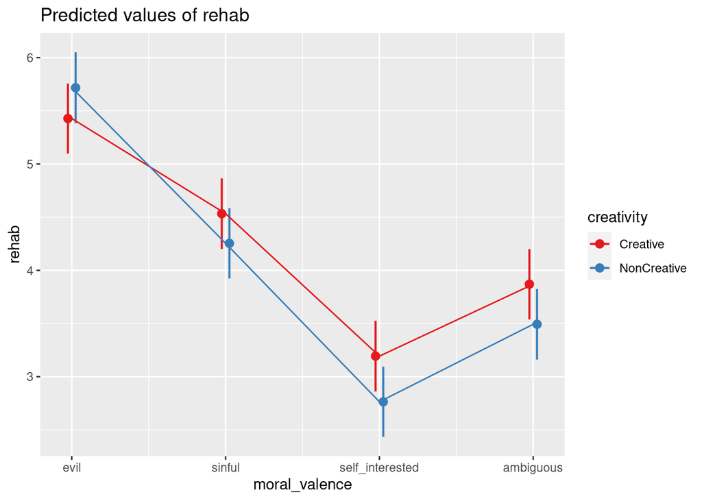

```r
plot_model(rehab4,
           type = "pred",
           terms = c("moral_valence", "creativity")) +
  geom_line()
```